[figure not shown]

CVT(diag)-36

Diagnostic Procedure with Diagnostic Trouble Code (DTC)

CONTINUOUSLY VARIABLE TRANSMISSION (DIAGNOSTICS)

17.Diagnostic Procedure with Diagnostic Trouble Code (DTC)

A: DTC P0500 VEHICLE SPEED SENSOR “A”

DTC DETECTING CONDITION:

• Immediately at fault recognition

• GENERAL DESCRIPTION <Ref. to GD(CVT)-5, DTC P0500 VEHICLE SPEED SENSOR “A”, Diagnostic

Trouble Code (DTC) Detecting Criteria.>

TROUBLE SYMPTOM:

VDC does not operate.

B: DTC P0601 INTERNAL CONTROL MODULE MEMORY CHECKSUM ERROR

DTC DETECTING CONDITION:

• Detected when two consecutive driving cycles with fault occur.

• GENERAL DESCRIPTION <Ref. to GD(CVT)-6, DTC P0601 INTERNAL CONTROL MODULE MEMORY

CHECKSUM ERROR, Diagnostic Trouble Code (DTC) Detecting Criteria.>

TROUBLE SYMPTOM:

TCM ROM malfunction

Step Check Yes No

1 CHECK DTC.

Read the DTC of VDC system using the Subaru

Select Monitor.

Is DTC displayed? Perform the diag-

nosis according to

DTC. <Ref. to

VDC(diag)-42, List

of Diagnostic Trou-

ble Code (DTC).>

Repair the poor

contact of connec-

tor and harness

between

VDCCM&H/U and

wheel speed sen-

sor.

Step Check Yes No

1 CHECK DTC.

1) Perform the Clear Memory Mode using the

Subaru Select Monitor. <Ref. to CVT(diag)-17,

Clear Memory Mode.>

2) Read the DTC.

Is DTC P0601 displayed? Replace the TCM.

<Ref. to

CVT(TR690)-126,

Transmission Con-

trol Module

(TCM).>

Current condition

is normal. Check

for interference

from noise, etc.

[figure not shown]

CVT(diag)-37

Diagnostic Procedure with Diagnostic Trouble Code (DTC)

CONTINUOUSLY VARIABLE TRANSMISSION (DIAGNOSTICS)

C: DTC P0604 INTERNAL CONTROL MODULE RANDOM ACCESS MEMORY

(RAM) ERROR

DTC DETECTING CONDITION:

• Detected when two consecutive driving cycles with fault occur.

• GENERAL DESCRIPTION <Ref. to GD(CVT)-7, DTC P0604 INTERNAL CONTROL MODULE RANDOM

ACCESS MEMORY (RAM) ERROR, Diagnostic Trouble Code (DTC) Detecting Criteria.>

TROUBLE SYMPTOM:

TCM RAM malfunction

D: DTC P062F INTERNAL CONTROL MODULE EEPROM ERROR

DTC DETECTING CONDITION:

• Detected when two consecutive driving cycles with fault occur.

• GENERAL DESCRIPTION <Ref. to GD(CVT)-8, DTC P062F INTERNAL CONTROL MODULE EEPROM

ERROR, Diagnostic Trouble Code (DTC) Detecting Criteria.>

TROUBLE SYMPTOM:

TCM EEPROM malfunction

Step Check Yes No

1 CHECK DTC.

1) Perform the Clear Memory Mode using the

Subaru Select Monitor. <Ref. to CVT(diag)-17,

Clear Memory Mode.>

2) Read the DTC.

Is DTC P0604 displayed? Replace the TCM.

<Ref. to

CVT(TR690)-126,

Transmission Con-

trol Module

(TCM).>

Current condition

is normal. Check

for interference

from noise, etc.

Step Check Yes No

1 CHECK DTC.

1) Perform the Clear Memory Mode using the

Subaru Select Monitor. <Ref. to CVT(diag)-17,

Clear Memory Mode.>

2) Read the DTC.

Is DTC P062F displayed? Replace the TCM.

<Ref. to

CVT(TR690)-126,

Transmission Con-

trol Module

(TCM).>

Current condition

is normal. Check

for interference

from noise, etc.

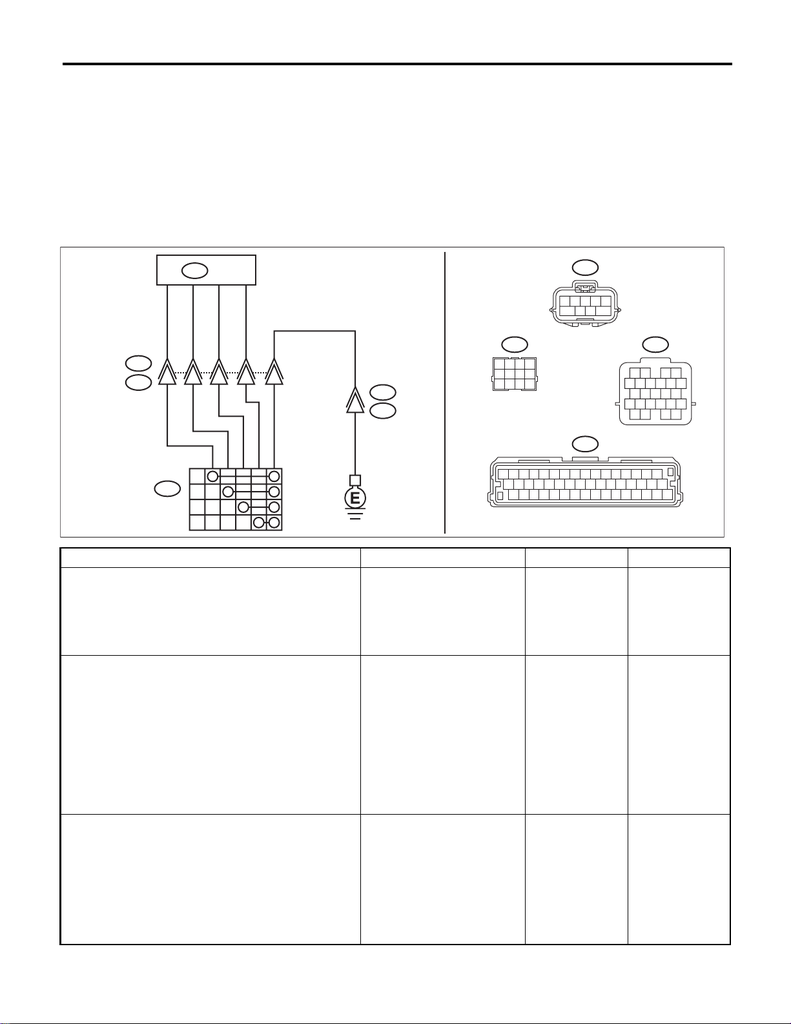

CVT(diag)-38

Diagnostic Procedure with Diagnostic Trouble Code (DTC)

CONTINUOUSLY VARIABLE TRANSMISSION (DIAGNOSTICS)

E: DTC P0705 TRANSMISSION RANGE SENSOR CIRCUIT (PRNDL INPUT)

DTC DETECTING CONDITION:

• Immediately at fault recognition

• GENERAL DESCRIPTION <Ref. to GD(CVT)-9, DTC P0705 TRANSMISSION RANGE SENSOR CIR-

CUIT (PRNDL INPUT), Diagnostic Trouble Code (DTC) Detecting Criteria.>

TROUBLE SYMPTOM:

• Shift characteristics are erroneous.

• The range position of the select lever and the position of shift indicator display do not match.

WIRING DIAGRAM:

CVT control system <Ref. to WI-148, CVT Control System.>

Step Check Yes No

1 CHECK INPUT SIGNAL FOR TCM.

1) Turn the ignition switch to ON.

2) Move the select lever to each range, and

read the data of «P range», «R Range Signal»,

«N range» and «D Range Signal» using the

Subaru Select Monitor.

Is display “OFF” for the range

other than corresponding

range?

Go to step 5. Go to step 2.

2 CHECK HARNESS.

1) Turn the ignition switch to OFF.

2) Disconnect the TCM and transmission con-

nectors.

3) Measure the resistance between TCM con-

nector and chassis ground.

Connector & terminal

(B54) No. 38 — Chassis ground:

(B54) No. 37 — Chassis ground:

(B54) No. 36 — Chassis ground:

(B54) No. 35 — Chassis ground:

Is each resistance 1 MΩ or

more?

Go to step 3. Repair the short

circuit of body har-

ness.

3 CHECK HARNESS.

1) Disconnect the inhibitor switch connector.

2) Measure the resistance between transmis-

sion connector and chassis ground.

Connector & terminal

(T3) No. 3 — Chassis ground:

(T3) No. 2 — Chassis ground:

(T3) No. 1 — Chassis ground:

(T3) No. 8 — Chassis ground:

Is each resistance 1 MΩ or

more?

Go to step 4. Repair the short

circuit of transmis-

sion harness.

B54

123456789

10 11 12 13 14 15 16

17 18 19 20 21 22 23 24 25 26 27 28 29 30 31 32

33 34 35 36 37 38 39 40 41 42 43 44 45 46 47 48

B11

567

12 34

9

10 11 12

17 18 19 20

8

13 14 15 16

13

B54

D

N

R

P

35

36

37

38

1

4

3

5

2

B12

T3

3

2

1

8

4

5

9

1

6

10

2

7

11

3

8

12

4

B12

T4

B11

T7

1

78

69

2345

T7

CVT00518

TCM

INHIBITOR

SWITCH

[figure not shown]

CVT(diag)-39

Diagnostic Procedure with Diagnostic Trouble Code (DTC)

CONTINUOUSLY VARIABLE TRANSMISSION (DIAGNOSTICS)

4 CHECK INHIBITOR SWITCH.

Move the select lever to each range, and mea-

sure the resistance between inhibitor switch

connector terminals.

Connector & terminal

(T7) No. 2 — (T7) No. 1:

(T7) No. 5 — (T7) No. 1:

(T7) No. 3 — (T7) No. 1:

(T7) No. 4 — (T7) No. 1:

Is the resistance other than cor-

responding range 1 MΩ or

more?

Go to step 5. Replace the inhibi-

tor switch. <Ref. to

CVT(TR690)-92,

Inhibitor Switch.>

5 CHECK FOR POOR CONTACT. Is there poor contact between

TCM, inhibitor switch, transmis-

sion ground?

Repair the poor

contact.

Replace the TCM.

<Ref. to

CVT(TR690)-126,

Transmission Con-

trol Module

(TCM).>

Step Check Yes No

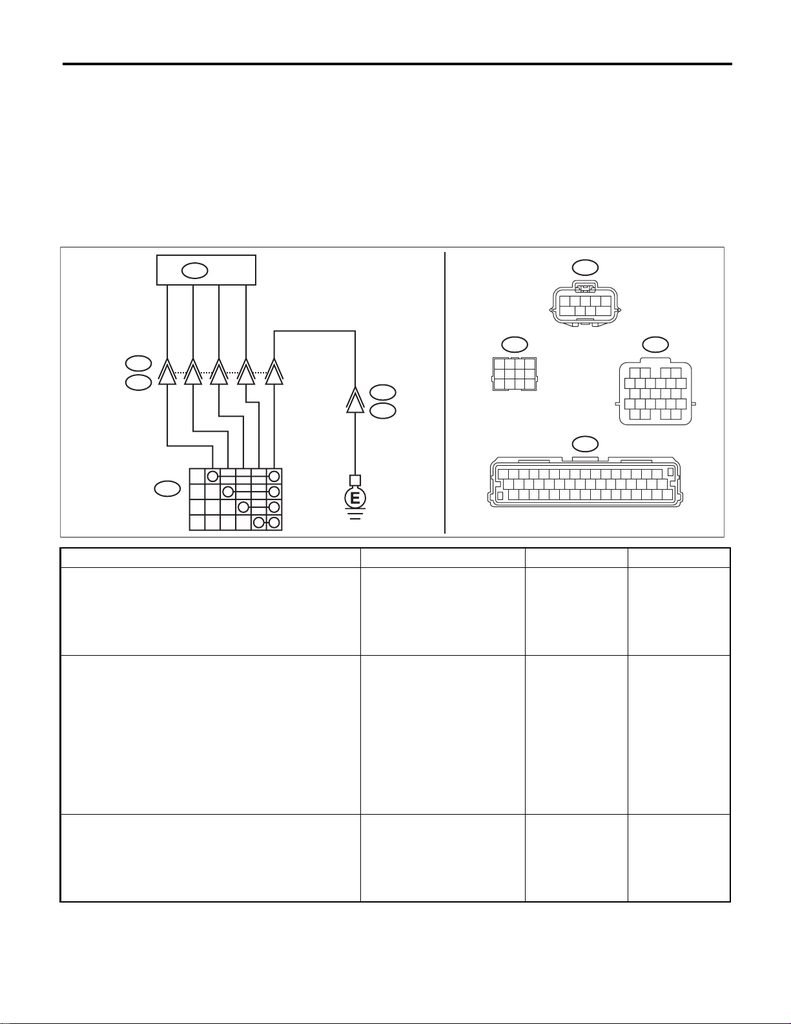

CVT(diag)-40

Diagnostic Procedure with Diagnostic Trouble Code (DTC)

CONTINUOUSLY VARIABLE TRANSMISSION (DIAGNOSTICS)

F: DTC P0708 AT RANGE SWITCH NOT INPUTTED

DTC DETECTING CONDITION:

• Immediately at fault recognition

• GENERAL DESCRIPTION <Ref. to GD(CVT)-10, DTC P0708 AT RANGE SWITCH NOT INPUTTED, Di-

agnostic Trouble Code (DTC) Detecting Criteria.>

TROUBLE SYMPTOM:

• Shift characteristics are erroneous.

• The range position of the select lever and the position of shift indicator display do not match.

WIRING DIAGRAM:

CVT control system <Ref. to WI-148, CVT Control System.>

Step Check Yes No

1 CHECK INPUT SIGNAL FOR TCM.

1) Turn the ignition switch to ON.

2) Move the select lever to each range, and

read the data of «P range», «R Range Signal»,

«N range» and «D Range Signal» using the

Subaru Select Monitor.

Is the display of the corre-

sponding range “ON”?

Go to step 7. Go to step 2.

2 CHECK HARNESS.

1) Turn the ignition switch to OFF.

2) Disconnect the TCM and transmission con-

nectors.

3) Measure the resistance of harness between

TCM connector and transmission connector.

Connector & terminal

(B54) No. 38 — (B12) No. 3:

(B54) No. 37 — (B12) No. 2:

(B54) No. 36 — (B12) No. 1:

(B54) No. 35 — (B12) No. 8:

Is each resistance less than 1

Ω?

Go to step 3. Repair the open

circuit of body har-

ness.

3 CHECK HARNESS.

Measure the resistance of harness between

inhibitor switch connector and transmission

ground.

Connector & terminal

(T7) No. 1 — Transmission ground:

Is the resistance less than 1 Ω? Go to step 4. Repair the open

circuit of harness.

B54

123456789

10 11 12 13 14 15 16

17 18 19 20 21 22 23 24 25 26 27 28 29 30 31 32

33 34 35 36 37 38 39 40 41 42 43 44 45 46 47 48

B11

567

12 34

9

10 11 12

17 18 19 20

8

13 14 15 16

13

B54

D

N

R

P

35

36

37

38

1

4

3

5

2

B12

T3

3

2

1

8

4

5

9

1

6

10

2

7

11

3

8

12

4

B12

T4

B11

T7

1

78

69

2345

T7

CVT00518

TCM

INHIBITOR

SWITCH

[figure not shown]

CVT(diag)-41

Diagnostic Procedure with Diagnostic Trouble Code (DTC)

CONTINUOUSLY VARIABLE TRANSMISSION (DIAGNOSTICS)

G: DTC P0711 ATF TEMP. SENSOR CIRCUIT RANGE/PERFORMANCE

DTC DETECTING CONDITION:

• Detected when two consecutive driving cycles with fault occur.

• GENERAL DESCRIPTION <Ref. to GD(CVT)-11, DTC P0711 ATF TEMP. SENSOR CIRCUIT RANGE/

PERFORMANCE, Diagnostic Trouble Code (DTC) Detecting Criteria.>

TROUBLE SYMPTOM:

• Excessive shift shock

• Shift characteristics malfunction

NOTE:

For the diagnostic procedure, perform the diagnosis according to DTC P0712 and P0713. <Ref. to CVT(di-

ag)-42, DTC P0712 TRANSMISSION FLUID TEMPERATURE SENSOR CIRCUIT LOW INPUT, Diagnostic

Procedure with Diagnostic Trouble Code (DTC).> <Ref. to CVT(diag)-44, DTC P0713 TRANSMISSION

FLUID TEMPERATURE SENSOR CIRCUIT HIGH INPUT, Diagnostic Procedure with Diagnostic Trouble

Code (DTC).>

4 CHECK HARNESS.

1) Disconnect the inhibitor switch connector.

2) Measure the resistance between transmis-

sion connector and inhibitor switch connector.

Connector & terminal

(T3) No. 3 — (T7) No. 2:

(T3) No. 2 — (T7) No. 5:

(T3) No. 1 — (T7) No. 3:

(T3) No. 8 — (T7) No. 4:

Is each resistance less than 1

Ω?

Go to step 5. Repair the open

circuit of transmis-

sion harness.

5 CHECK INHIBITOR SWITCH.

Move the select lever to each range, and mea-

sure the resistance between inhibitor switch

connector terminals.

Connector & terminal

(T7) No. 2 — (T7) No. 1:

(T7) No. 5 — (T7) No. 1:

(T7) No. 3 — (T7) No. 1:

(T7) No. 4 — (T7) No. 1:

Is the resistance of the corre-

sponding range less than 1

Go to step 6. Replace the inhibi-

tor switch. <Ref. to

CVT(TR690)-92,

Inhibitor Switch.>

6 CHECK HARNESS.

1) Turn the ignition switch to ON.

2) Measure the voltage between each connec-

tor and chassis ground.

Connector & terminal

Transmission connector (B12 side)

(B12) No. 3 (+) — Chassis ground (–):

(B12) No. 2 (+) — Chassis ground (–):

(B12) No. 1 (+) — Chassis ground (–):

(B12) No. 8 (+) — Chassis ground (–):

Transmission connector (T7 side)

(T7) No. 2 (+) — Chassis ground (–):

(T7) No. 5 (+) — Chassis ground (–):

(T7) No. 3 (+) — Chassis ground (–):

(T7) No. 4 (+) — Chassis ground (–):

Is each voltage less than 1 V? Go to step 7. Repair the harness

which outputs 1 V

or more.

7 CHECK FOR POOR CONTACT. Is there poor contact between

TCM, inhibitor switch, transmis-

sion ground?

Repair the poor

contact.

Replace the TCM.

<Ref. to

CVT(TR690)-126,

Transmission Con-

trol Module

(TCM).>

Step Check Yes No

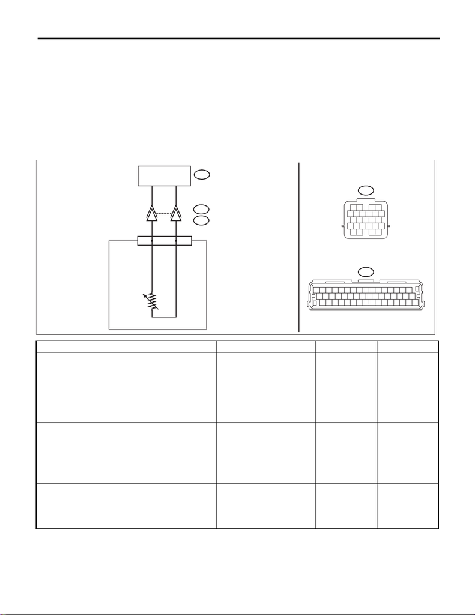

CVT(diag)-42

Diagnostic Procedure with Diagnostic Trouble Code (DTC)

CONTINUOUSLY VARIABLE TRANSMISSION (DIAGNOSTICS)

H: DTC P0712 TRANSMISSION FLUID TEMPERATURE SENSOR CIRCUIT LOW

INPUT

DTC DETECTING CONDITION:

• Immediately at fault recognition

• GENERAL DESCRIPTION <Ref. to GD(CVT)-12, DTC P0712 TRANSMISSION FLUID TEMPERATURE

SENSOR CIRCUIT LOW INPUT, Diagnostic Trouble Code (DTC) Detecting Criteria.>

TROUBLE SYMPTOM:

• Excessive shift shock

• Shift characteristics malfunction

WIRING DIAGRAM:

CVT control system <Ref. to WI-148, CVT Control System.>

Step Check Yes No

1 CHECK HARNESS.

1) Turn the ignition switch to OFF.

2) Disconnect the TCM connector.

3) Measure the resistance of harness between

TCM connector and chassis ground.

Connector & terminal

(B54) No. 1 — Chassis ground:

(B54) No. 6 — Chassis ground:

Is the resistance 1 MΩ or

more?

Go to step 4. Go to step 2.

2 CHECK HARNESS.

1) Disconnect the transmission connector.

2) Measure the resistance between transmis-

sion connector and transmission body.

Connector & terminal

(T4) No. 16 — Transmission body:

(T4) No. 19 — Transmission body:

Is the resistance 1 MΩ or

more?

Repair the short

circuit of body har-

ness.

Go to step 3.

3 CHECK HARNESS INSIDE TRANSMISSION.

CAUTION:

Start work after ATF cools down.

1) Remove the transmission oil pan.

2) Check for the harness pinch, damage.

Is there any fault in the har-

ness?

Replace the trans-

mission harness.

Go to step 4.

B54

123456789

10 11 12 13 14 15 16

17 18 19 20 21 22 23 24 25 26 27 28 29 30 31 32

33 34 35 36 37 38 39 40 41 42 43 44 45 46 47 48

B11

567

12 34

9

10 11 12

17 18 19 20

8

13 14 15 16

16

19

T4

B11

6

1

B54

CVT00519

TCM

CONTROL VALVE BODY

ATF TEMPERATURE

SENSOR

[figure not shown]

CVT(diag)-43

Diagnostic Procedure with Diagnostic Trouble Code (DTC)

CONTINUOUSLY VARIABLE TRANSMISSION (DIAGNOSTICS)

4 CHECK ATF TEMPERATURE SENSOR.

Measure the resistance between transmission

connector terminals.

Connector & terminal

(T4) No. 16 — No. 19:

Is resistance as follows?

Fluid temperature 0°C →

Approx. 6.2 kΩ

Fluid temperature 20°C →

Approx. 2.6 kΩ

Fluid temperature 80°C →

Approx. 370 Ω

Replace the TCM.

<Ref. to

CVT(TR690)-126,

Transmission Con-

trol Module

(TCM).>

Replace the con-

trol valve body.

<Ref. to

CVT(TR690)-112,

Control Valve

Body.>

Step Check Yes No

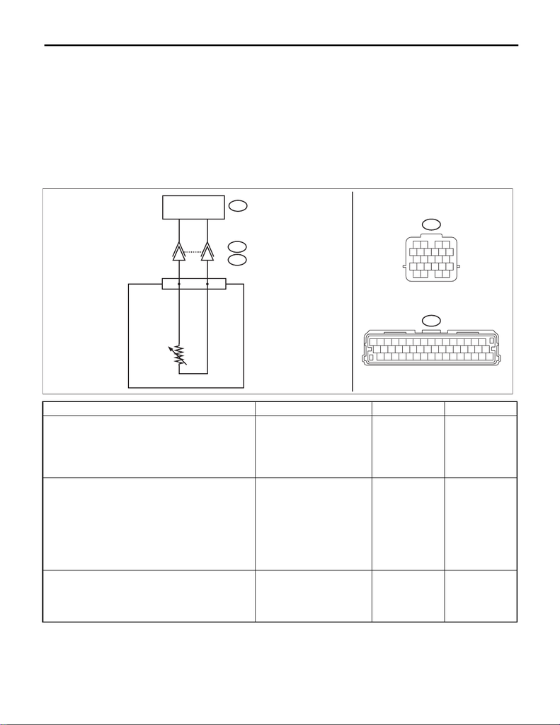

CVT(diag)-44

Diagnostic Procedure with Diagnostic Trouble Code (DTC)

CONTINUOUSLY VARIABLE TRANSMISSION (DIAGNOSTICS)

I: DTC P0713 TRANSMISSION FLUID TEMPERATURE SENSOR CIRCUIT HIGH

INPUT

DTC DETECTING CONDITION:

• Immediately at fault recognition

• GENERAL DESCRIPTION <Ref. to GD(CVT)-13, DTC P0713 TRANSMISSION FLUID TEMPERATURE

SENSOR CIRCUIT HIGH INPUT, Diagnostic Trouble Code (DTC) Detecting Criteria.>

TROUBLE SYMPTOM:

• Excessive shift shock

• Shift characteristics malfunction

WIRING DIAGRAM:

CVT control system <Ref. to WI-148, CVT Control System.>

Step Check Yes No

1 CHECK HARNESS.

1) Turn the ignition switch to ON.

2) Measure the voltage between TCM connec-

tors.

Connector & terminal

(B54) No. 6 (+) — (B54) No. 1 (–):

Is the voltage 5 V or more? Repair the short

circuit of harness.

Go to step 2.

2 CHECK HARNESS.

1) Turn the ignition switch to OFF.

2) Disconnect the TCM and transmission con-

nectors.

3) Measure the resistance between TCM con-

nector and transmission connectors.

Connector & terminal

(B54) No. 6 — (B11) No. 16:

(B54) No. 1 — (B11) No. 19:

Is the resistance less than 1 Ω? Go to step 3. Repair the open

circuit of body har-

ness.

3 CHECK ATF TEMPERATURE SENSOR.

Measure the resistance between transmission

connector terminals.

Connector & terminal

(T4) No. 16 — No. 19:

Is the resistance 1 MΩ or

more?

Repair the open

circuit of transmis-

sion harness.

Go to step 4.

B54

123456789

10 11 12 13 14 15 16

17 18 19 20 21 22 23 24 25 26 27 28 29 30 31 32

33 34 35 36 37 38 39 40 41 42 43 44 45 46 47 48

B11

567

12 34

9

10 11 12

17 18 19 20

8

13 14 15 16

16

19

T4

B11

6

1

B54

CVT00519

TCM

CONTROL VALVE BODY

ATF TEMPERATURE

SENSOR

[figure not shown]

CVT(diag)-45

Diagnostic Procedure with Diagnostic Trouble Code (DTC)

CONTINUOUSLY VARIABLE TRANSMISSION (DIAGNOSTICS)

4 CHECK ATF TEMPERATURE SENSOR.

1) Connect the connectors to TCM and trans-

mission.

2) Start the engine.

3) Warm up until the ATF temperature exceeds

50°C (122°F).

4) Turn the ignition switch to OFF.

5) Disconnect the transmission connector.

6) Measure the resistance between transmis-

sion connector terminals.

Connector & terminal

(T4) No. 16 — No. 19:

Is the resistance 730 — 1120

Ω?

Go to step 5. Go to step 7.

5 CHECK ATF TEMPERATURE SENSOR.

Measure the resistance between transmission

connector terminals.

Connector & terminal

(T4) No. 16 — No. 19:

Does the resistance value

increase gradually while the

ATF temperature decreases?

Go to step 6. Replace the con-

trol valve body.

<Ref. to

CVT(TR690)-112,

Control Valve

Body.>

6 CHECK INPUT SIGNAL FOR TCM.

1) Connect the connector to transmission.

2) Turn the ignition switch to ON. (Do not start

engine.)

3) Read the data of «ATF Temp.» using the

Subaru Select Monitor.

Does the ATF temperature

gradually decrease?

Check for poor

contact of the ATF

temperature sen-

sor and transmis-

sion connector

harness, and

repair the defective

part.

Go to step 7.

7 CHECK FOR POOR CONTACT. Is there poor contact of ATF

temperature sensor circuit?

Repair the poor

contact.

Replace the TCM.

<Ref. to

CVT(TR690)-126,

Transmission Con-

trol Module

(TCM).>

Step Check Yes No

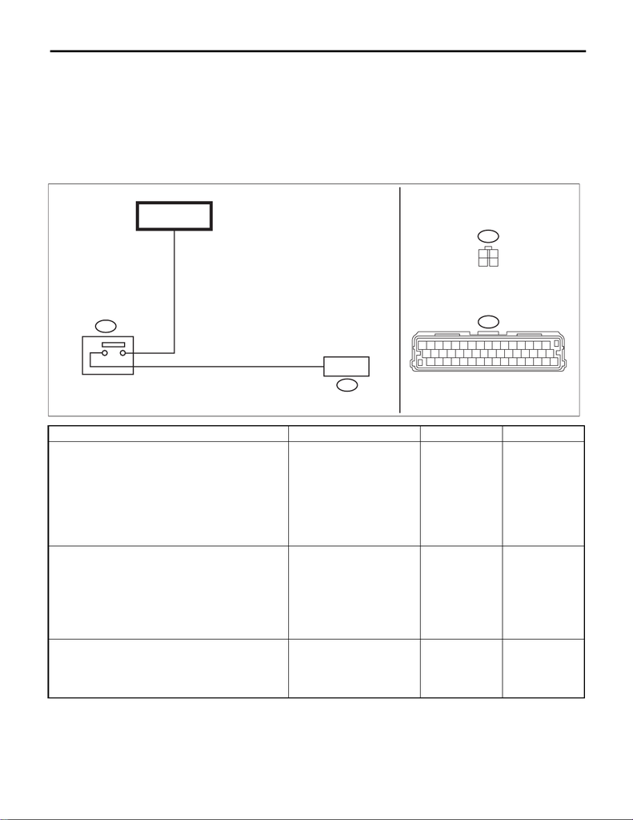

CVT(diag)-46

Diagnostic Procedure with Diagnostic Trouble Code (DTC)

CONTINUOUSLY VARIABLE TRANSMISSION (DIAGNOSTICS)

J: DTC P0719 BRAKE SWITCH CIRCUIT LOW

DTC DETECTING CONDITION:

• Immediately at fault recognition

• GENERAL DESCRIPTION <Ref. to GD(CVT)-14, DTC P0719 BRAKE SWITCH CIRCUIT LOW, Diagnos-

tic Trouble Code (DTC) Detecting Criteria.>

TROUBLE SYMPTOM:

Gear is not shifted down when climbing a hill or driving down a hill.

WIRING DIAGRAM:

Stop light system <Ref. to WI-397, Stop Light System.>

Step Check Yes No

1 CHECK FUSE (NO. 8).

1) Turn the ignition switch to OFF.

2) Remove the fuse (No. 8).

Is the fuse (No. 8) blown out? Replace the fuse

(No. 8). If the new

fuse (No. 8) has

blown out easily,

repair the short cir-

cuit of harness

between fuse

(No. 8) and stop

light switch.

Go to step 2.

2 CHECK HARNESS.

1) Turn the ignition switch to OFF.

2) Disconnect the TCM and stop light switch

connector.

3) Measure the resistance between TCM con-

nector and stop light switch connector.

Connector & terminal

(B54) No. 29 — (B65) No. 2:

Is the resistance less than 1 Ω? Go to step 3. Repair the open

circuit of harness.

3 CHECK HARNESS.

Measure the resistance between TCM connec-

tor and fuse (No. 8).

Connector & terminal

(B65) No. 1 — fuse (No. 8):

Is the resistance less than 1 Ω? Go to step 4. Repair the open

circuit of harness.

B54

123456789

10 11 12 13 14 15 16

17 18 19 20 21 22 23 24 25 26 27 28 29 30 31 32

33 34 35 36 37 38 39 40 41 42 43 44 45 46 47 48

B65

12

34

CVT00520

29

B54

B65

1

2

TCM

FB-3

F/B FUSE NO. 8

(B)

STOP LIGHT &

BRAKE SWITCH

[figure not shown]

CVT(diag)-47

Diagnostic Procedure with Diagnostic Trouble Code (DTC)

CONTINUOUSLY VARIABLE TRANSMISSION (DIAGNOSTICS)

4 CHECK INPUT SIGNAL FOR TCM.

1) Install the fuse (No. 8).

2) Connect the TCM and stop light switch con-

nector.

3) Depress the brake pedal.

4) Measure the voltage between TCM connec-

tor and chassis ground.

Connector & terminal

(B54) No. 29 (+) — Chassis ground (–):

Is the voltage 10 V or more? Go to step 5. Replace the stop

light switch. <Ref.

to BR-77, Stop

Light Switch.>

5 CHECK INPUT SIGNAL FOR TCM.

With brake pedal depressed, read the data of

«Stop Light Switch» using Subaru Select Moni-

tor.

Is “ON” displayed? Current condition

is normal. Check

for poor contact in

connectors or har-

nesses, and repair

the defective part.

Go to step 6.

6 CHECK FOR POOR CONTACT. Is there poor contact of input

signal of stop light switch?

Repair the poor

contact.

Replace the TCM.

<Ref. to

CVT(TR690)-126,

Transmission Con-

trol Module

(TCM).>

Step Check Yes No

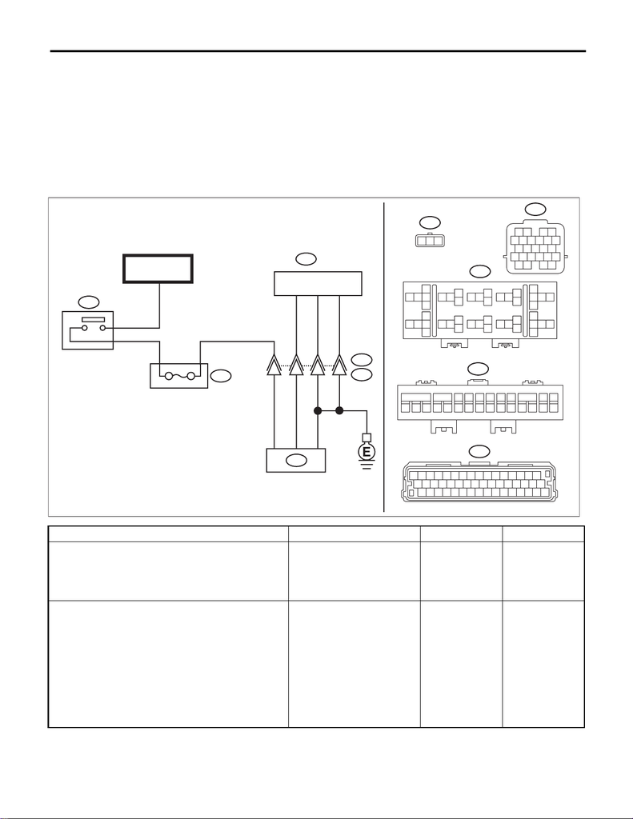

CVT(diag)-48

Diagnostic Procedure with Diagnostic Trouble Code (DTC)

CONTINUOUSLY VARIABLE TRANSMISSION (DIAGNOSTICS)

K: DTC P0720 OUTPUT SPEED SENSOR CIRCUIT

DTC DETECTING CONDITION:

• Immediately at fault recognition

• GENERAL DESCRIPTION <Ref. to GD(CVT)-15, DTC P0720 OUTPUT SPEED SENSOR CIRCUIT, Di-

agnostic Trouble Code (DTC) Detecting Criteria.>

TROUBLE SYMPTOM:

• Shock occurs when selecting shift position.

• Shift control malfunction

WIRING DIAGRAM:

CVT control system <Ref. to WI-148, CVT Control System.>

Step Check Yes No

1 CHECK FUSE.

1) Turn the ignition switch to OFF.

2) Remove the fuse (7.5 A) from the fuse

holder.

Is the fuse OK? Go to step 2. Replace the fuse. If

the fuse blows out

easily, repair the

short circuit of har-

ness.

2 CHECK HARNESS.

1) Turn the ignition switch to OFF.

2) Disconnect the TCM and transmission con-

nectors.

3) Measure the resistance between TCM con-

nector and transmission connectors.

Connector & terminal

(B54) No. 12 — (B11) No. 12:

(B54) No. 26 — (B11) No. 20:

(B54) No. 42 — (B11) No. 13:

(B550) No. 20 — (B11) No. 7:

Is the resistance less than 1 Ω? Go to step 3. Repair the open

circuit of harness.

20

26

B550

91

2

232221 262524201918

4

13

12

17

3

16

6

15

587

14

10 11

B220

10 11

12

13

14 15

16

18

19 21 22

20

17

24

5

3

17

9

8

6

32 33

34

35

28262423

25

27

29

30

31

36 37

38

40

41 43 44

42

39

16

31 32

33 34 35 36 37 38 39 40 41 42 43 44 45 46 47 48

B54

123456789

10 11 12 13 14 15

17 18 19 20 21 22 23 24 25 26 27 28 29 30

B11

567

12 34

9

10 11 12

17 18 19 20

8

13 14 15 16

123

AT5

14

15

B220

B11

T4

13

12

7

12

42

2

3

1

AT5

B54

6

20

B550

CVT00525

TCM

MB-26

M/B FUSE NO. 12

(B)

FUSE HOLDER

7.5A

FRONT WHEEL SPEED

SENSOR

SELF SHUT RELAY

RELAY HOLDER

FUSE HOLDER

[figure not shown]

CVT(diag)-49

Diagnostic Procedure with Diagnostic Trouble Code (DTC)

CONTINUOUSLY VARIABLE TRANSMISSION (DIAGNOSTICS)

3 CHECK HARNESS.

Measure the resistance between TCM connec-

tor and chassis ground.

Connector & terminal

(B54) No. 12 — Chassis ground:

Is the resistance 1 MΩ or

more?

Go to step 4. Repair the short

circuit of harness.

4 CHECK TRANSMISSION HARNESS.

1) Install the fuse.

2) Connect the TCM connector.

3) Turn the ignition switch to ON.

4) Measure the voltage between transmission

connector terminals.

Connector & terminal

(B11) No. 7 (+) — Chassis ground (–):

Is the voltage approx. 10 — 13

V?

Go to step 5. Repair the poor

contact of harness

or connector.

5 CHECK INPUT SIGNAL FOR TCM.

1) Turn the ignition switch to OFF.

2) Connect the transmission connector.

3) Lift up the vehicle.

4) Start the engine.

5) Slowly increase the speed to 30 km/h (19

MPH).

6) Read the data of «Front Wheel Speed»

using Subaru Select Monitor.

Does the value of «Front Wheel

Speed» change according to

the engine speed?

Current condition

is normal. Repair

the poor contacts

of harnesses of

front wheel speed

sensor and trans-

mission connector.

Go to step 6.

6 CHECK TRANSMISSION HARNESS.

1) Turn the ignition switch to OFF.

2) Disconnect the transmission connector.

3) Lift up the vehicle.

4) Disconnect the front wheel speed sensor

connector.

5) Measure the resistance between transmis-

sion connector and front wheel speed sensor

connector.

Connector & terminal

(T4) No. 7 — (AT5) No. 1:

(T4) No. 12 — (AT5) No. 2:

(T4) No. 13 — (AT5) No. 3:

(T4) No. 20 — (AT5) No. 3:

Is the resistance less than 1 Ω? Replace the front

wheel speed sen-

sor. <Ref. to

CVT(TR690)-105,

Front Wheel

Speed Sensor.>

Replace the trans-

mission harness.

Step Check Yes No

[figure not shown]

CVT(diag)-50

Diagnostic Procedure with Diagnostic Trouble Code (DTC)

CONTINUOUSLY VARIABLE TRANSMISSION (DIAGNOSTICS)

L: DTC P0721 OUTPUT SHAFT SPEED SENSOR CIRCUIT RANGE/PERFOR-

MANCE

DTC DETECTING CONDITION:

• Immediately at fault recognition

• GENERAL DESCRIPTION <Ref. to GD(CVT)-16, DTC P0721 OUTPUT SHAFT SPEED SENSOR CIR-

CUIT RANGE/PERFORMANCE, Diagnostic Trouble Code (DTC) Detecting Criteria.>

TROUBLE SYMPTOM:

• Acceleration is poor during standing start.

• No lock-up occurs.

• The engine stalls when the vehicle is stopped.

• Shift control malfunction

Step Check Yes No

1 CHECK DTC.

Read the DTC using Subaru Select Monitor.

Besides DTC P0721, is DTC

P1706 or P0500 displayed?

Perform the diag-

nosis according to

DTCs other than

P0721.

Perform the diag-

nosis according to

DTC P0720. <Ref.

to CVT(diag)-48,

DTC P0720 OUT-

PUT SPEED SEN-

SOR CIRCUIT,

Diagnostic Proce-

dure with Diagnos-

tic Trouble Code

(DTC).>

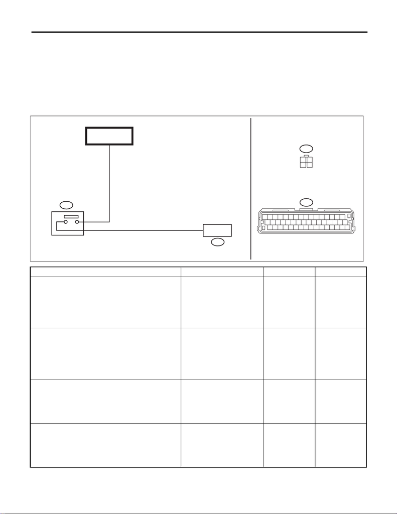

CVT(diag)-51

Diagnostic Procedure with Diagnostic Trouble Code (DTC)

CONTINUOUSLY VARIABLE TRANSMISSION (DIAGNOSTICS)

M: DTC P0724 BRAKE SWITCH CIRCUIT HIGH

DTC DETECTING CONDITION:

• Immediately at fault recognition

• GENERAL DESCRIPTION <Ref. to GD(CVT)-17, DTC P0724 BRAKE SWITCH CIRCUIT HIGH, Diagnos-

tic Trouble Code (DTC) Detecting Criteria.>

TROUBLE SYMPTOM:

Gear is not shifted down when climbing a hill or driving down a hill.

WIRING DIAGRAM:

Stop light system <Ref. to WI-397, Stop Light System.>

Step Check Yes No

1 CHECK STOP LIGHT SWITCH.

1) Turn the ignition switch to OFF.

2) Disconnect the stop light switch connector.

3) Measure the resistance between stop light

switch connectors.

Connector & terminal

(B65) No. 1 — No. 2:

Is the resistance 1 MΩ or

more?

Go to step 2. Replace the stop

light switch. <Ref.

to BR-77, Stop

Light Switch.>

2 CHECK HARNESS.

1) Disconnect the TCM connector.

2) Turn the ignition switch to ON.

3) Measure the voltage between TCM connec-

tor and chassis ground.

Connector & terminal

(B54) No. 29 (+) — Chassis ground (–):

Is the voltage 10 V or more? Repair the short

circuit of harness.

Go to step 3.

3 CHECK INPUT SIGNAL FOR TCM.

1) Connect the TCM and stop light switch con-

nector.

2) Turn the ignition switch to ON.

3) Read the data of «Stop Light Switch» using

Subaru Select Monitor.

Is “OFF” displayed? Current condition

is normal. Check

for poor contact in

connectors or har-

nesses, and repair

the defective part.

Go to step 4.

4 CHECK FOR POOR CONTACT. Is there poor contact of input

signal of stop light switch?

Repair the poor

contact.

Replace the TCM.

<Ref. to

CVT(TR690)-126,

Transmission Con-

trol Module

(TCM).>

B54

123456789

10 11 12 13 14 15 16

17 18 19 20 21 22 23 24 25 26 27 28 29 30 31 32

33 34 35 36 37 38 39 40 41 42 43 44 45 46 47 48

B65

12

34

CVT00520

29

B54

B65

1

2

TCM

FB-3

F/B FUSE NO. 8

(B)

STOP LIGHT &

BRAKE SWITCH

[figure not shown]

CVT(diag)-52

Diagnostic Procedure with Diagnostic Trouble Code (DTC)

CONTINUOUSLY VARIABLE TRANSMISSION (DIAGNOSTICS)

N: DTC P0730 GEARSHIFT CONTROL PERFORMANCE ABNORMAL

DTC DETECTING CONDITION:

• Immediately at fault recognition

• GENERAL DESCRIPTION <Ref. to GD(CVT)-18, DTC P0730 GEARSHIFT CONTROL PERFORMANCE

ABNORMAL, Diagnostic Trouble Code (DTC) Detecting Criteria.>

TROUBLE SYMPTOM:

• Acceleration is poor during standing start.

• Shift control malfunction

• Engine speed increases abruptly.

Step Check Yes No

1 CHECK TRANSMISSION FLUID.

Check the amount of ATF. <Ref. to

CVT(TR690)-36, ADJUSTMENT, CVTF.>

Is the ATF amount correct? Go to step 2. Adjust the amount

of ATF. <Ref. to

CVT(TR690)-36,

ADJUSTMENT,

CVTF.>

2 CHECK TRANSMISSION FLUID.

Check the condition of ATF. <Ref. to

CVT(TR690)-40, CONDITION CHECK, CVTF.>

Is the ATF OK? Go to step 3. Check according to

the “Corrective

action” of ATF

(CVTF) “CONDI-

TION CHECK”.

<Ref. to

CVT(TR690)-40,

CONDITION

CHECK, CVTF.>

3 CHECK INPUT SIGNAL FOR TCM.

1) Lift up the vehicle.

2) Start the engine.

3) Warm up until the ATF temperature reaches

to 40 — 70°C (104 — 158°F).

4) Shift the select lever to “P” range.

5) Stabilize the engine speed at idle.

6) Read the data of «Actual secondary pres-

sure» using Subaru Select Monitor.

Is the «Actual secondary pres-

sure» 0.5 — 1.5 MPa?

Go to step 4. Perform the diag-

nosis according to

DTC P0841. <Ref.

to CVT(diag)-68,

DTC P0841 SEC-

ONDARY OIL

PRESSURE SEN-

SOR PERFOR-

MANCE,

Diagnostic Proce-

dure with Diagnos-

tic Trouble Code

(DTC).>

4 CHECK INPUT SIGNAL FOR TCM.

1) Set the select lever to “D” range.

2) Release the brake pedal to stabilize the

engine speed and front wheel speed.

3) Read the data of «Actual Gear Ratio» using

Subaru Select Monitor.

Is the «Actual Gear Ratio» 2.0

— 2.4?

Go to step 5. Go to step 6.

5 CHECK INPUT SIGNAL FOR TCM.

1) Set the select lever to “D” range.

2) Slowly increase the speed to 40 km/h (25

MPH) and keep the constant speed.

3) Read the data of «Actual Gear Ratio» using

Subaru Select Monitor.

Is the «Actual Gear Ratio» 0.5

— 0.8?

Go to step 6. Replace the trans-

mission assembly.

<Ref. to

CVT(TR690)-56,

Automatic Trans-

mission Assem-

bly.>

[figure not shown]

CVT(diag)-53

Diagnostic Procedure with Diagnostic Trouble Code (DTC)

CONTINUOUSLY VARIABLE TRANSMISSION (DIAGNOSTICS)

6 DRIVING CHECK BY INSPECTION MODE.

1) Turn the ignition switch to OFF.

2) Perform a drive check based on the “Inspec-

tion Mode”. <Ref. to CVT(diag)-18, Inspection

Mode.>

Does the AT OIL TEMP light

blink and is DTC P0730 dis-

played?

Replace the trans-

mission assembly.

<Ref. to

CVT(TR690)-56,

Automatic Trans-

mission Assem-

bly.>

If there is shift

problems, abrupt

increase of engine

speed, standing

start problems,

replace the trans-

mission assembly.

<Ref. to

CVT(TR690)-56,

Automatic Trans-

mission Assem-

bly.> If it is normal,

temporary poor

contact occurs.

Step Check Yes No

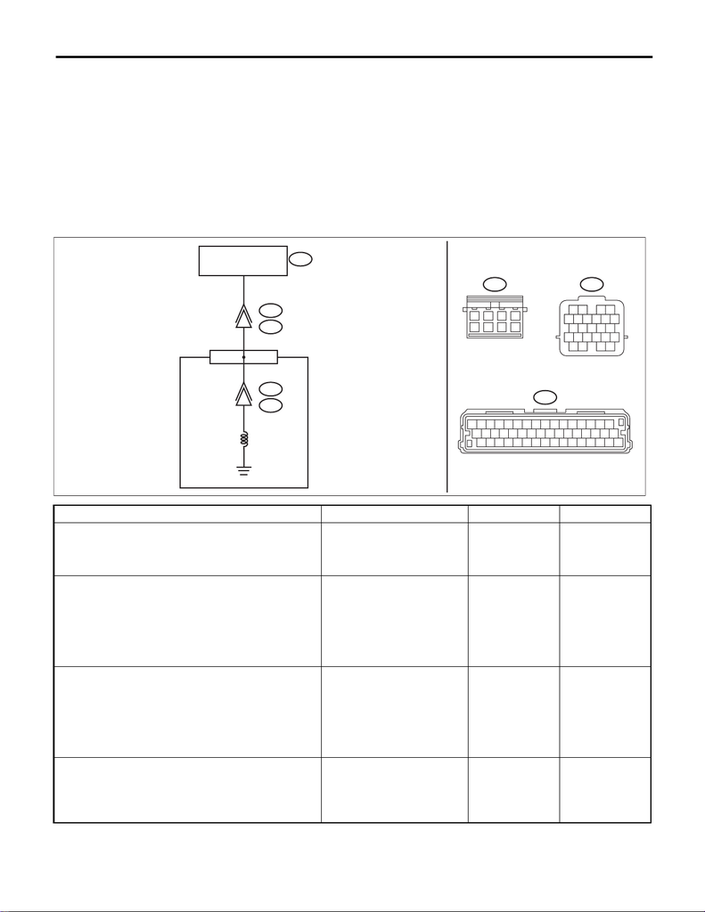

CVT(diag)-54

Diagnostic Procedure with Diagnostic Trouble Code (DTC)

CONTINUOUSLY VARIABLE TRANSMISSION (DIAGNOSTICS)

O: DTC P0746 PRESSURE CONTROL SOLENOID "A" PERFORMANCE/STUCK

OFF

DTC DETECTING CONDITION:

• Detected when two consecutive driving cycles with fault occur.

• GENERAL DESCRIPTION <Ref. to GD(CVT)-19, DTC P0746 PRESSURE CONTROL SOLENOID "A"

PERFORMANCE/STUCK OFF, Diagnostic Trouble Code (DTC) Detecting Criteria.>

TROUBLE SYMPTOM:

• Shift control malfunction

• CVT chain slippage

WIRING DIAGRAM:

CVT control system <Ref. to WI-148, CVT Control System.>

Step Check Yes No

1 CHECK DTC.

Read the DTC using Subaru Select Monitor.

Besides DTC P0746, is any of

the DTCs P0842, P0843,

P0962 and P0963 displayed?

Perform the diag-

nosis according to

DTCs other than

P0746.

Go to step 2.

2 CHECK SECONDARY SOLENOID (SYSTEM

OPERATION CHECK MODE).

1) Turn the ignition switch to ON.

2) Using the Subaru Select Monitor, perform

forced operation of the secondary solenoid.

<Ref. to CVT(diag)-22, System Operation

Check Mode.>

Does the indication of 0 → 500

mA appear repeatedly during

forced operation, and does

operating sound emit during

indicating 500 mA?

Go to step 5. Go to step 3.

3 CHECK SECONDARY SOLENOID.

1) Turn the ignition switch to OFF.

2) Disconnect the transmission connector.

3) Measure the resistance between transmis-

sion connector and transmission body.

Connector & terminal

(T4) No. 5 — Transmission body:

Is the resistance approx. 5 — 7

Ω? (when cold)

Go to step 7. Go to step 4.

4 CHECK HARNESS.

Check the continuity of transmission harness.

Is the harness normal? (Is it

free from defects such as open

circuit, power supply-output

short or GND-output short cir-

cuit, or poor contact?)

Go to step 7. Repair the har-

ness.

T11

13

4

6

78

2

5

B54

123456789

10 11 12 13 14 15 16

17 18 19 20 21 22 23 24 25 26 27 28 29 30 31 32

33 34 35 36 37 38 39 40 41 42 43 44 45 46 47 48

B11

567

12 34

9

10 11 12

17 18 19 20

8

13 14 15 16

CVT00530

T11

T31

15

32

B11

T4

B54

TCM

CONTROL VALVE BODY

SECONDARY

SOLENOID

[figure not shown]

CVT(diag)-55

Diagnostic Procedure with Diagnostic Trouble Code (DTC)

CONTINUOUSLY VARIABLE TRANSMISSION (DIAGNOSTICS)

5 CHECK TRANSMISSION FLUID.

1) Connect the transmission connector.

2) Check the amount of ATF. <Ref. to

CVT(TR690)-36, ADJUSTMENT, CVTF.>

Is the ATF amount correct? Go to step 6. Adjust the amount

of ATF. <Ref. to

CVT(TR690)-36,

ADJUSTMENT,

CVTF.>

6 CHECK TRANSMISSION FLUID.

Check the condition of ATF. <Ref. to

CVT(TR690)-40, CONDITION CHECK, CVTF.>

Is the ATF OK? Go to step 7. Check according to

the “Corrective

action” of ATF

(CVTF) “CONDI-

TION CHECK”.

<Ref. to

CVT(TR690)-40,

CONDITION

CHECK, CVTF.>

7 CHECK INPUT SIGNAL FOR TCM.

1) Lift up the vehicle.

2) Start the engine.

3) Warm up until the ATF temperature reaches

to 40 — 70°C (104 — 158°F).

4) Shift the select lever to “P” range.

5) Stabilize the engine speed at idle.

6) Read the data of «Actual secondary pres-

sure» using Subaru Select Monitor.

Is the «Actual secondary pres-

sure» 0.5 — 1.5 MPa?

Go to step 8. Replace the con-

trol valve body.

<Ref. to

CVT(TR690)-112,

Control Valve

Body.>

8 CHECK INPUT SIGNAL FOR TCM.

1) Keep the engine speed at 3,000 rpm.

2) Read the data of «Actual secondary pres-

sure» using Subaru Select Monitor.

Is the «Actual secondary pres-

sure» higher than step 7 value?

Does the value change accord-

ing to the engine speed, within

the range of 1.5 — 2.5 MPa?

Go to step 9. Replace the con-

trol valve body.

<Ref. to

CVT(TR690)-112,

Control Valve

Body.>

9 CHECK TCM INPUT SIGNAL (STALL TEST).

1) Apply the parking brake.

2) Set the select lever to “D” range.

3) Depress the brake pedal firmly.

4) Slowly open the accelerator fully, and stabi-

lize the engine speed.

5) Read the data of «Actual secondary pres-

sure» using Subaru Select Monitor.

CAUTION:

Do not perform a stall test for over 5 sec-

onds at a time.

Is the «Actual secondary pres-

sure» higher than step 8 value?

Does the value change accord-

ing to the engine speed, within

the range of 4.5 — 6.0 MPa?

Go to step 10. Replace the con-

trol valve body.

<Ref. to

CVT(TR690)-112,

Control Valve

Body.>

10 DRIVING CHECK BY INSPECTION MODE.

1) Turn the ignition switch to OFF.

2) Perform a drive check based on the “Inspec-

tion Mode”. <Ref. to CVT(diag)-18, Inspection

Mode.>

Does the AT OIL TEMP light

blink and is DTC P0746 dis-

played?

Perform the sec-

ondary pressure

test. <Ref. to

CVT(TR690)-49,

Secondary Pres-

sure (Line Pres-

sure) Test.>

If there is shift

problems, abrupt

increase of engine

speed, standing

start problems,

replace the trans-

mission assembly.

<Ref. to

CVT(TR690)-56,

Automatic Trans-

mission Assem-

bly.> If it is normal,

temporary poor

contact occurs.

Step Check Yes No

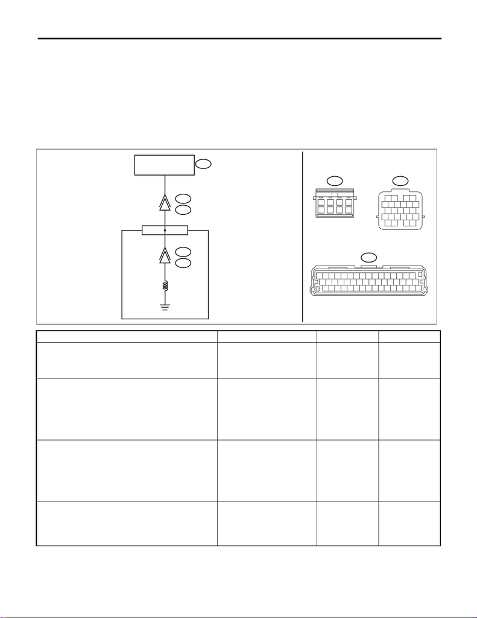

CVT(diag)-56

Diagnostic Procedure with Diagnostic Trouble Code (DTC)

CONTINUOUSLY VARIABLE TRANSMISSION (DIAGNOSTICS)

P: DTC P0747 PRESSURE CONTROL SOLENOID "A" STUCK ON

DTC DETECTING CONDITION:

• Detected when two consecutive driving cycles with fault occur.

• GENERAL DESCRIPTION <Ref. to GD(CVT)-22, DTC P0747 PRESSURE CONTROL SOLENOID "A"

STUCK ON, Diagnostic Trouble Code (DTC) Detecting Criteria.>

TROUBLE SYMPTOM:

• Acceleration is poor during standing start.

• Shift control malfunction

WIRING DIAGRAM:

CVT control system <Ref. to WI-148, CVT Control System.>

Step Check Yes No

1 CHECK DTC.

Read the DTC using Subaru Select Monitor.

Besides DTC P0747, is any of

the DTCs P0842, P0843,

P0962 and P0963 displayed?

Perform the diag-

nosis according to

DTCs other than

P0747.

Go to step 2.

2 CHECK SECONDARY SOLENOID (SYSTEM

OPERATION CHECK MODE).

1) Turn the ignition switch to ON.

2) Using the Subaru Select Monitor, perform

forced operation of the secondary solenoid.

<Ref. to CVT(diag)-22, System Operation

Check Mode.>

Does the indication of 0 → 500

mA appear repeatedly during

forced operation, and does

operating sound emit during

indicating 500 mA?

Go to step 5. Go to step 3.

3 CHECK SECONDARY SOLENOID.

1) Turn the ignition switch to OFF.

2) Disconnect the transmission connector.

3) Measure the resistance between transmis-

sion connector and transmission body.

Connector & terminal

(T4) No. 5 — Transmission body:

Is the resistance approx. 5 — 7

Ω? (when cold)

Go to step 7. Go to step 4.

4 CHECK HARNESS.

Check the continuity of transmission harness.

Is the harness normal? (Is it

free from defects such as open

circuit, power supply-output

short or GND-output short cir-

cuit, or poor contact?)

Go to step 7. Repair the har-

ness.

T11

13

4

6

78

2

5

B54

123456789

10 11 12 13 14 15 16

17 18 19 20 21 22 23 24 25 26 27 28 29 30 31 32

33 34 35 36 37 38 39 40 41 42 43 44 45 46 47 48

B11

567

12 34

9

10 11 12

17 18 19 20

8

13 14 15 16

CVT00530

T11

T31

15

32

B11

T4

B54

TCM

CONTROL VALVE BODY

SECONDARY

SOLENOID

[figure not shown]

CVT(diag)-57

Diagnostic Procedure with Diagnostic Trouble Code (DTC)

CONTINUOUSLY VARIABLE TRANSMISSION (DIAGNOSTICS)

5 CHECK TRANSMISSION FLUID.

1) Connect the transmission connector.

2) Check the amount of ATF. <Ref. to

CVT(TR690)-36, ADJUSTMENT, CVTF.>

Is the ATF amount correct? Go to step 6. Adjust the amount

of ATF. <Ref. to

CVT(TR690)-36,

ADJUSTMENT,

CVTF.>

6 CHECK TRANSMISSION FLUID.

Check the condition of ATF. <Ref. to

CVT(TR690)-40, CONDITION CHECK, CVTF.>

Is the ATF OK? Go to step 7. Check according to

the “Corrective

action” of ATF

(CVTF) “CONDI-

TION CHECK”.

<Ref. to

CVT(TR690)-40,

CONDITION

CHECK, CVTF.>

7 CHECK INPUT SIGNAL FOR TCM.

1) Lift up the vehicle.

2) Start the engine.

3) Warm up until the ATF temperature reaches

to 40 — 70°C (104 — 158°F).

4) Shift the select lever to “P” range.

5) Stabilize the engine speed at idle.

6) Read the data of «Actual secondary pres-

sure» using Subaru Select Monitor.

Is the «Actual secondary pres-

sure» 0.5 — 1.5 MPa?

Go to step 8. Replace the con-

trol valve body.

<Ref. to

CVT(TR690)-112,

Control Valve

Body.>

8 CHECK INPUT SIGNAL FOR TCM.

1) Keep the engine speed at 3,000 rpm.

2) Read the data of «Actual secondary pres-

sure» using Subaru Select Monitor.

Is the «Actual secondary pres-

sure» higher than step 7 value?

Does the value change accord-

ing to the engine speed, within

the range of 1.5 — 2.5 MPa?

Go to step 9. Replace the con-

trol valve body.

<Ref. to

CVT(TR690)-112,

Control Valve

Body.>

9 CHECK TCM INPUT SIGNAL (STALL TEST).

1) Apply the parking brake.

2) Set the select lever to “D” range.

3) Depress the brake pedal firmly.

4) Slowly open the accelerator fully, and stabi-

lize the engine speed.

5) Read the data of «Actual secondary pres-

sure» using Subaru Select Monitor.

CAUTION:

Do not perform a stall test for over 5 sec-

onds at a time.

Is the «Actual secondary pres-

sure» higher than step 8 value?

Does the value change accord-

ing to the engine speed, within

the range of 4.5 — 6.0 MPa?

Go to step 10. Replace the con-

trol valve body.

<Ref. to

CVT(TR690)-112,

Control Valve

Body.>

10 DRIVING CHECK BY INSPECTION MODE.

1) Turn the ignition switch to OFF.

2) Perform a drive check based on the “Inspec-

tion Mode”. <Ref. to CVT(diag)-18, Inspection

Mode.>

Does the AT OIL TEMP light

blink and is DTC P0747 dis-

played?

Perform the sec-

ondary pressure

test. <Ref. to

CVT(TR690)-49,

Secondary Pres-

sure (Line Pres-

sure) Test.>

If there is shift

problems, abrupt

increase of engine

speed, standing

start problems,

replace the trans-

mission assembly.

<Ref. to

CVT(TR690)-56,

Automatic Trans-

mission Assem-

bly.> If it is normal,

temporary poor

contact occurs.

Step Check Yes No

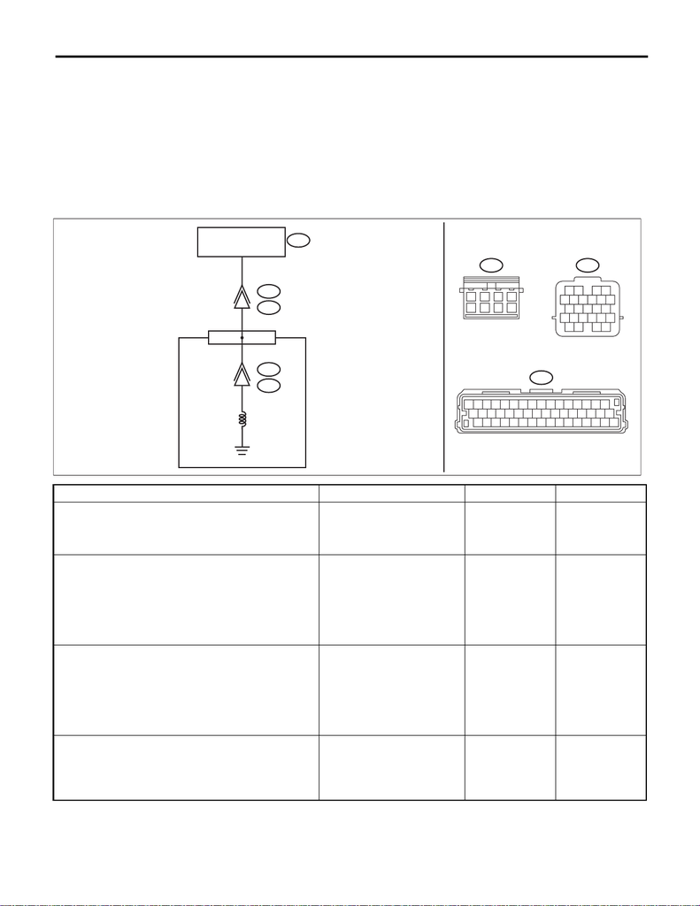

CVT(diag)-58

Diagnostic Procedure with Diagnostic Trouble Code (DTC)

CONTINUOUSLY VARIABLE TRANSMISSION (DIAGNOSTICS)

Q: DTC P0751 SHIFT SOLENOID "A" PERFORMANCE/STUCK OFF

DTC DETECTING CONDITION:

• Detected when two consecutive driving cycles with fault occur.

• GENERAL DESCRIPTION <Ref. to GD(CVT)-25, DTC P0751 SHIFT SOLENOID "A" PERFORMANCE/

STUCK OFF, Diagnostic Trouble Code (DTC) Detecting Criteria.>

TROUBLE SYMPTOM:

• Shift control malfunction

• Engine speed increases abruptly.

WIRING DIAGRAM:

CVT control system <Ref. to WI-148, CVT Control System.>

Step Check Yes No

1 CHECK DTC.

Read the DTC using Subaru Select Monitor.

Besides DTC P0751, is any of

the DTCs P0973, P0974,

P0976, P0977, P2747 and

P2751 displayed?

Perform the diag-

nosis according to

DTCs other than

P0751.

Go to step 2.

2 CHECK PRIMARY UP SOLENOID (SYSTEM

OPERATION CHECK MODE).

1) Turn the ignition switch to ON.

2) Using the Subaru Select Monitor, perform

forced operation of the primary UP solenoid.

<Ref. to CVT(diag)-22, System Operation

Check Mode.>

Does the indication of 0 → 50%

appear repeatedly during

forced operation, and does

operating sound emit during

indicating 50%?

Go to step 5. Go to step 3.

3 CHECK PRIMARY UP SOLENOID.

1) Turn the ignition switch to OFF.

2) Disconnect the transmission connector.

3) Measure the resistance between transmis-

sion connector and transmission body.

Connector & terminal

(T4) No. 6 — Transmission body:

Is the resistance approx. 10 —

13.5 Ω? (when cold)

Go to step 7. Go to step 4.

4 CHECK HARNESS.

Check the continuity of transmission harness.

Is the harness normal? (Is it

free from defects such as open

circuit, power supply-output

short or GND-output short cir-

cuit, or poor contact?)

Go to step 7. Repair the har-

ness.

T11

13

4

6

78

2

5

B54

123456789

10 11 12 13 14 15 16

17 18 19 20 21 22 23 24 25 26 27 28 29 30 31 32

33 34 35 36 37 38 39 40 41 42 43 44 45 46 47 48

B11

567

12 34

9

10 11 12

17 18 19 20

8

13 14 15 16

CVT00533

T11

T31

76

47

B11

T4

B54

TCM

CONTROL VALVE BODY

PRIMARY UP

SOLENOID

[figure not shown]

CVT(diag)-59

Diagnostic Procedure with Diagnostic Trouble Code (DTC)

CONTINUOUSLY VARIABLE TRANSMISSION (DIAGNOSTICS)

5 CHECK TRANSMISSION FLUID.

1) Connect the transmission connector.

2) Check the amount of ATF. <Ref. to

CVT(TR690)-36, ADJUSTMENT, CVTF.>

Is the ATF amount correct? Go to step 6. Adjust the amount

of ATF. <Ref. to

CVT(TR690)-36,

ADJUSTMENT,

CVTF.>

6 CHECK TRANSMISSION FLUID.

Check the condition of ATF. <Ref. to

CVT(TR690)-40, CONDITION CHECK, CVTF.>

Is the ATF OK? Go to step 7. Check according to

the “Corrective

action” of ATF

(CVTF) “CONDI-

TION CHECK”.

<Ref. to

CVT(TR690)-40,

CONDITION

CHECK, CVTF.>

7 CHECK INPUT SIGNAL FOR TCM.

1) Lift up the vehicle.

2) Start the engine.

3) Warm up until the ATF temperature reaches

to 40 — 70°C (104 — 158°F).

4) Shift the select lever to “P” range.

5) Stabilize the engine speed at idle.

6) Read the data of «Actual secondary pres-

sure» using Subaru Select Monitor.

Is the «Actual secondary pres-

sure» 0.5 — 1.5 MPa?

Go to step 8. Replace the trans-

mission assembly.

<Ref. to

CVT(TR690)-56,

Automatic Trans-

mission Assem-

bly.>

8 CHECK INPUT SIGNAL FOR TCM.

1) Set the select lever to “D” range.

2) Release the brake pedal to stabilize the

engine speed and front wheel speed.

3) Read the data of «Actual Gear Ratio» using

Subaru Select Monitor.

NOTE:

Before operation, set SI-DRIVE to I mode.

Is the «Actual Gear Ratio» 2.0

— 2.4?

Go to step 9. Replace the trans-

mission assembly.

<Ref. to

CVT(TR690)-56,

Automatic Trans-

mission Assem-

bly.>

9 CHECK INPUT SIGNAL FOR TCM.

1) Set the select lever to “D” range.

2) Slowly increase the speed to 40 km/h (25

MPH) and keep the constant speed.

3) Read the data of «Actual Gear Ratio» using

Subaru Select Monitor.

NOTE:

Before operation, set SI-DRIVE to I mode.

Is the «Actual Gear Ratio» 0.5

— 0.8?

Go to step 10. Replace the trans-

mission assembly.

<Ref. to

CVT(TR690)-56,

Automatic Trans-

mission Assem-

bly.>

10 DRIVING CHECK BY INSPECTION MODE.

1) Turn the ignition switch to OFF.

2) Perform a drive check based on the “Inspec-

tion Mode”. <Ref. to CVT(diag)-18, Inspection

Mode.>

Does the AT OIL TEMP light

blink and is DTC P0751 dis-

played?

Replace the trans-

mission assembly.

<Ref. to

CVT(TR690)-56,

Automatic Trans-

mission Assem-

bly.>

If there is shift

problems, abrupt

increase of engine

speed, standing

start problems,

replace the trans-

mission assembly.

<Ref. to

CVT(TR690)-56,

Automatic Trans-

mission Assem-

bly.> If it is normal,

temporary poor

contact occurs.

Step Check Yes No

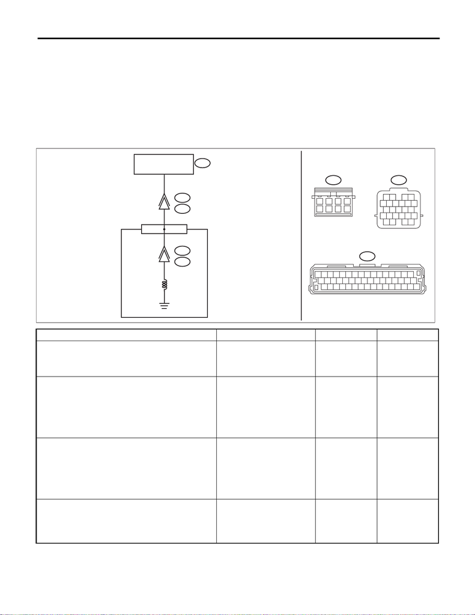

CVT(diag)-60

Diagnostic Procedure with Diagnostic Trouble Code (DTC)

CONTINUOUSLY VARIABLE TRANSMISSION (DIAGNOSTICS)

R: DTC P0752 SHIFT SOLENOID "A" STUCK ON

DTC DETECTING CONDITION:

• Detected when two consecutive driving cycles with fault occur.

• GENERAL DESCRIPTION <Ref. to GD(CVT)-26, DTC P0752 SHIFT SOLENOID "A" STUCK ON, Diag-

nostic Trouble Code (DTC) Detecting Criteria.>

TROUBLE SYMPTOM:

• Acceleration is poor during standing start.

• Shift control malfunction

WIRING DIAGRAM:

CVT control system <Ref. to WI-148, CVT Control System.>

Step Check Yes No

1 CHECK DTC.

Read the DTC using Subaru Select Monitor.

Besides DTC P0752, is any of

the DTCs P0973, P0974,

P0976, P0977, P2747 and

P2751 displayed?

Perform the diag-

nosis according to

DTCs other than

P0752.

Go to step 2.

2 CHECK PRIMARY UP SOLENOID (SYSTEM

OPERATION CHECK MODE).

1) Turn the ignition switch to ON.

2) Using the Subaru Select Monitor, perform

forced operation of the primary UP solenoid.

<Ref. to CVT(diag)-22, System Operation

Check Mode.>

Does the indication of 0 → 50%

appear repeatedly during

forced operation, and does

operating sound emit during

indicating 50%?

Go to step 5. Go to step 3.

3 CHECK PRIMARY UP SOLENOID.

1) Turn the ignition switch to OFF.

2) Disconnect the transmission connector.

3) Measure the resistance between transmis-

sion connector and transmission body.

Connector & terminal

(T4) No. 6 — Transmission body:

Is the resistance approx. 10 —

13.5 Ω? (when cold)

Go to step 7. Go to step 4.

4 CHECK HARNESS.

Check the continuity of transmission harness.

Is the harness normal? (Is it

free from defects such as open

circuit, power supply-output

short or GND-output short cir-

cuit, or poor contact?)

Go to step 7. Repair the har-

ness.

T11

13

4

6

78

2

5

B54

123456789

10 11 12 13 14 15 16

17 18 19 20 21 22 23 24 25 26 27 28 29 30 31 32

33 34 35 36 37 38 39 40 41 42 43 44 45 46 47 48

B11

567

12 34

9

10 11 12

17 18 19 20

8

13 14 15 16

CVT00533

T11

T31

76

47

B11

T4

B54

TCM

CONTROL VALVE BODY

PRIMARY UP

SOLENOID

[figure not shown]

CVT(diag)-61

Diagnostic Procedure with Diagnostic Trouble Code (DTC)

CONTINUOUSLY VARIABLE TRANSMISSION (DIAGNOSTICS)

5 CHECK TRANSMISSION FLUID.

1) Connect the transmission connector.

2) Check the amount of ATF. <Ref. to

CVT(TR690)-36, ADJUSTMENT, CVTF.>

Is the ATF amount correct? Go to step 6. Adjust the amount

of ATF. <Ref. to

CVT(TR690)-36,

ADJUSTMENT,

CVTF.>

6 CHECK TRANSMISSION FLUID.

Check the condition of ATF. <Ref. to

CVT(TR690)-40, CONDITION CHECK, CVTF.>

Is the ATF OK? Go to step 7. Check according to

the “Corrective

action” of ATF

(CVTF) “CONDI-

TION CHECK”.

<Ref. to

CVT(TR690)-40,

CONDITION

CHECK, CVTF.>

7 CHECK INPUT SIGNAL FOR TCM.

1) Lift up the vehicle.

2) Start the engine.

3) Warm up until the ATF temperature reaches

to 40 — 70°C (104 — 158°F).

4) Shift the select lever to “P” range.

5) Stabilize the engine speed at idle.

6) Read the data of «Actual secondary pres-

sure» using Subaru Select Monitor.

Is the «Actual secondary pres-

sure» 0.5 — 1.5 MPa?

Go to step 8. Replace the trans-

mission assembly.

<Ref. to

CVT(TR690)-56,

Automatic Trans-

mission Assem-

bly.>

8 CHECK INPUT SIGNAL FOR TCM.

1) Set the select lever to “D” range.

2) Release the brake pedal to stabilize the

engine speed and front wheel speed.

3) Read the data of «Actual Gear Ratio» using

Subaru Select Monitor.

NOTE:

Before operation, set SI-DRIVE to I mode.

Is the «Actual Gear Ratio» 2.0

— 2.4?

Go to step 9. Replace the trans-

mission assembly.

<Ref. to

CVT(TR690)-56,

Automatic Trans-

mission Assem-

bly.>

9 CHECK INPUT SIGNAL FOR TCM.

1) Set the select lever to “D” range.

2) Slowly increase the speed to 40 km/h (25

MPH) and keep the constant speed.

3) Read the data of «Actual Gear Ratio» using

Subaru Select Monitor.

NOTE:

Before operation, set SI-DRIVE to I mode.

Is the «Actual Gear Ratio» 0.5

— 0.8?

Go to step 10. Replace the trans-

mission assembly.

<Ref. to

CVT(TR690)-56,

Automatic Trans-

mission Assem-

bly.>

10 DRIVING CHECK BY INSPECTION MODE.

1) Turn the ignition switch to OFF.

2) Perform a drive check based on the “Inspec-

tion Mode”. <Ref. to CVT(diag)-18, Inspection

Mode.>

Does the AT OIL TEMP light

blink and is DTC P0752 dis-

played?

Replace the trans-

mission assembly.

<Ref. to

CVT(TR690)-56,

Automatic Trans-

mission Assem-

bly.>

If there is shift

problems, abrupt

increase of engine

speed, standing

start problems,

replace the trans-

mission assembly.

<Ref. to

CVT(TR690)-56,

Automatic Trans-

mission Assem-

bly.> If it is normal,

temporary poor

contact occurs.

Step Check Yes No

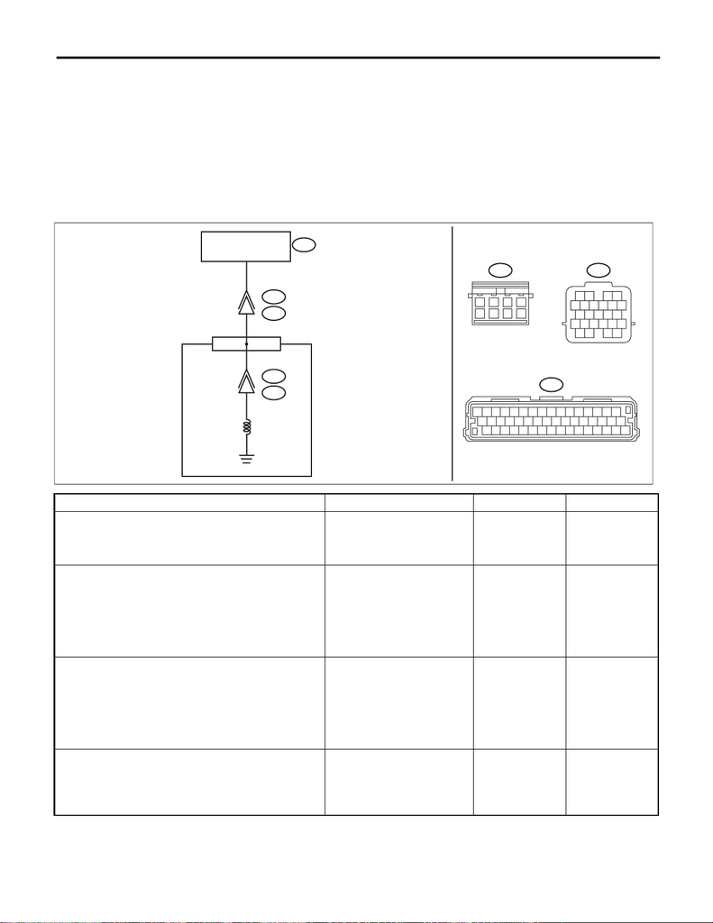

CVT(diag)-62

Diagnostic Procedure with Diagnostic Trouble Code (DTC)

CONTINUOUSLY VARIABLE TRANSMISSION (DIAGNOSTICS)

S: DTC P0756 SHIFT SOLENOID "B" PERFORMANCE/STUCK OFF

DTC DETECTING CONDITION:

• Detected when two consecutive driving cycles with fault occur.

• GENERAL DESCRIPTION <Ref. to GD(CVT)-27, DTC P0756 SHIFT SOLENOID "B" PERFORMANCE/

STUCK OFF, Diagnostic Trouble Code (DTC) Detecting Criteria.>

TROUBLE SYMPTOM:

• Acceleration is poor during standing start.

• Shift control malfunction

WIRING DIAGRAM:

CVT control system <Ref. to WI-148, CVT Control System.>

Step Check Yes No

1 CHECK DTC.

Read the DTC using Subaru Select Monitor.

Besides DTC P0756, is any of

the DTCs P0973, P0974,

P0976, P0977, P2747 and

P2751 displayed?

Perform the diag-

nosis according to

DTCs other than

P0756.

Go to step 2.

2 CHECK PRIMARY DOWN SOLENOID (SYS-

TEM OPERATION CHECK MODE).

1) Turn the ignition switch to ON.

2) Using the Subaru Select Monitor, perform

forced operation of the primary DOWN sole-

noid. <Ref. to CVT(diag)-22, System Operation

Check Mode.>

Does the indication of 0 → 50%

appear repeatedly during

forced operation, and does

operating sound emit during

indicating 50%?

Go to step 5. Go to step 3.

3 CHECK PRIMARY DOWN SOLENOID.

1) Turn the ignition switch to OFF.

2) Disconnect the transmission connector.

3) Measure the resistance between transmis-

sion connector and transmission body.

Connector & terminal

(T4) No. 1 — Transmission body:

Is the resistance approx. 10 —

13.5 Ω? (when cold)

Go to step 7. Go to step 4.

4 CHECK HARNESS.

Check the continuity of transmission harness.

Is the harness normal? (Is it

free from defects such as open

circuit, power supply-output

short or GND-output short cir-

cuit, or poor contact?)

Go to step 7. Repair the har-

ness.

T11

13

4

6

78

2

5

B54

123456789

10 11 12 13 14 15 16

17 18 19 20 21 22 23 24 25 26 27 28 29 30 31 32

33 34 35 36 37 38 39 40 41 42 43 44 45 46 47 48

B11

567

12 34

9

10 11 12

17 18 19 20

8

13 14 15 16

CVT00534

T11

T31

61

30

B11

T4

B54

TCM

CONTROL VALVE BODY

PRIMARY DOWN

SOLENOID

[figure not shown]

CVT(diag)-63

Diagnostic Procedure with Diagnostic Trouble Code (DTC)

CONTINUOUSLY VARIABLE TRANSMISSION (DIAGNOSTICS)

5 CHECK TRANSMISSION FLUID.

1) Connect the transmission connector.

2) Check the amount of ATF. <Ref. to

CVT(TR690)-36, ADJUSTMENT, CVTF.>

Is the ATF amount correct? Go to step 6. Adjust the amount

of ATF. <Ref. to

CVT(TR690)-36,

ADJUSTMENT,

CVTF.>

6 CHECK TRANSMISSION FLUID.

Check the condition of ATF. <Ref. to

CVT(TR690)-40, CONDITION CHECK, CVTF.>

Is the ATF OK? Go to step 7. Check according to

the “Corrective

action” of ATF

(CVTF) “CONDI-

TION CHECK”.

<Ref. to

CVT(TR690)-40,

CONDITION

CHECK, CVTF.>

7 CHECK INPUT SIGNAL FOR TCM.

1) Lift up the vehicle.

2) Start the engine.

3) Warm up until the ATF temperature reaches

to 40 — 70°C (104 — 158°F).

4) Shift the select lever to “P” range.

5) Stabilize the engine speed at idle.

6) Read the data of «Actual secondary pres-

sure» using Subaru Select Monitor.

Is the «Actual secondary pres-

sure» 0.5 — 1.5 MPa?

Go to step 8. Replace the trans-

mission assembly.

<Ref. to

CVT(TR690)-56,

Automatic Trans-

mission Assem-

bly.>

8 CHECK INPUT SIGNAL FOR TCM.

1) Set the select lever to “D” range.

2) Release the brake pedal to stabilize the

engine speed and front wheel speed.

3) Read the data of «Actual Gear Ratio» using

Subaru Select Monitor.

NOTE:

Before operation, set SI-DRIVE to I mode.

Is the «Actual Gear Ratio» 2.0

— 2.4?

Go to step 9. Replace the trans-

mission assembly.

<Ref. to

CVT(TR690)-56,

Automatic Trans-

mission Assem-

bly.>

9 CHECK INPUT SIGNAL FOR TCM.

1) Set the select lever to “D” range.

2) Slowly increase the speed to 40 km/h (25

MPH) and keep the constant speed.

3) Read the data of «Actual Gear Ratio» using

Subaru Select Monitor.

NOTE:

Before operation, set SI-DRIVE to I mode.

Is the «Actual Gear Ratio» 0.5

— 0.8?

Go to step 10. Replace the trans-

mission assembly.

<Ref. to

CVT(TR690)-56,

Automatic Trans-

mission Assem-

bly.>

10 DRIVING CHECK BY INSPECTION MODE.

1) Turn the ignition switch to OFF.

2) Perform a drive check based on the “Inspec-

tion Mode”. <Ref. to CVT(diag)-18, Inspection

Mode.>

Does the AT OIL TEMP light

blink and is DTC P0756 dis-

played?

Replace the trans-

mission assembly.

<Ref. to

CVT(TR690)-56,

Automatic Trans-

mission Assem-

bly.>

If there is shift

problems, abrupt

increase of engine

speed, standing

start problems,

replace the trans-

mission assembly.

<Ref. to

CVT(TR690)-56,

Automatic Trans-

mission Assem-

bly.> If it is normal,

temporary poor

contact occurs.

Step Check Yes No

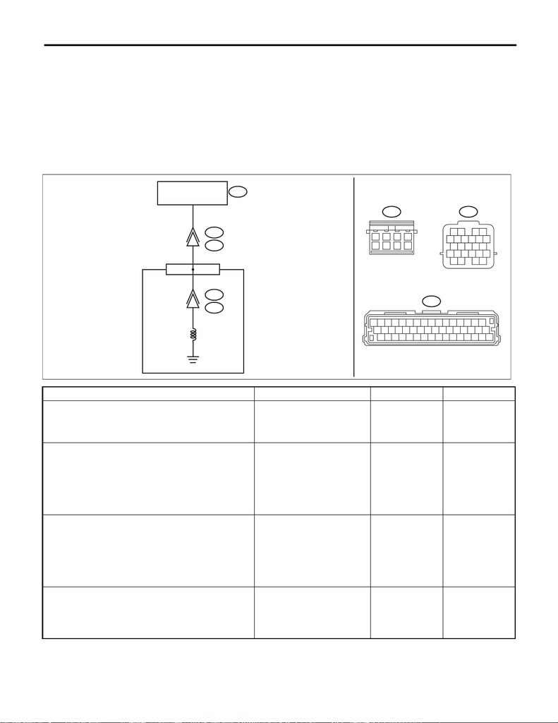

CVT(diag)-64

Diagnostic Procedure with Diagnostic Trouble Code (DTC)

CONTINUOUSLY VARIABLE TRANSMISSION (DIAGNOSTICS)

T: DTC P0757 SHIFT SOLENOID "B" STUCK ON

DTC DETECTING CONDITION:

• Detected when two consecutive driving cycles with fault occur.

• GENERAL DESCRIPTION <Ref. to GD(CVT)-28, DTC P0757 SHIFT SOLENOID "B" STUCK ON, Diag-

nostic Trouble Code (DTC) Detecting Criteria.>

TROUBLE SYMPTOM:

• Vibration occurs at shift change.

• Shift control malfunction

WIRING DIAGRAM:

CVT control system <Ref. to WI-148, CVT Control System.>

Step Check Yes No

1 CHECK DTC.

Read the DTC using Subaru Select Monitor.

Besides DTC P0757, is any of

the DTCs P0973, P0974,

P0976, P0977, P2747 and

P2751 displayed?

Perform the diag-

nosis according to

DTCs other than

P0757.

Go to step 2.

2 CHECK PRIMARY DOWN SOLENOID (SYS-

TEM OPERATION CHECK MODE).

1) Turn the ignition switch to ON.

2) Using the Subaru Select Monitor, perform

forced operation of the primary DOWN sole-

noid. <Ref. to CVT(diag)-22, System Operation

Check Mode.>

Does the indication of 0 → 50%

appear repeatedly during

forced operation, and does

operating sound emit during

indicating 50%?

Go to step 5. Go to step 3.

3 CHECK PRIMARY DOWN SOLENOID.

1) Turn the ignition switch to OFF.

2) Disconnect the transmission connector.

3) Measure the resistance between transmis-

sion connector and transmission body.

Connector & terminal

(T4) No. 1 — Transmission body:

Is the resistance approx. 10 —

13.5 Ω? (when cold)

Go to step 7. Go to step 4.

4 CHECK HARNESS.

Check the continuity of transmission harness.

Is the harness normal? (Is it

free from defects such as open

circuit, power supply-output

short or GND-output short cir-

cuit, or poor contact?)

Go to step 7. Repair the har-

ness.

T11

13

4

6

78

2

5

B54

123456789

10 11 12 13 14 15 16

17 18 19 20 21 22 23 24 25 26 27 28 29 30 31 32

33 34 35 36 37 38 39 40 41 42 43 44 45 46 47 48

B11

567

12 34

9

10 11 12

17 18 19 20

8

13 14 15 16

CVT00534

T11

T31

61

30

B11

T4

B54

TCM

CONTROL VALVE BODY

PRIMARY DOWN

SOLENOID

[figure not shown]

CVT(diag)-65

Diagnostic Procedure with Diagnostic Trouble Code (DTC)

CONTINUOUSLY VARIABLE TRANSMISSION (DIAGNOSTICS)

5 CHECK TRANSMISSION FLUID.

1) Connect the transmission connector.

2) Check the amount of ATF. <Ref. to

CVT(TR690)-36, ADJUSTMENT, CVTF.>

Is the ATF amount correct? Go to step 6. Adjust the amount

of ATF. <Ref. to

CVT(TR690)-36,

ADJUSTMENT,

CVTF.>

6 CHECK TRANSMISSION FLUID.

Check the condition of ATF. <Ref. to

CVT(TR690)-40, CONDITION CHECK, CVTF.>

Is the ATF OK? Go to step 7. Check according to

the “Corrective

action” of ATF

(CVTF) “CONDI-

TION CHECK”.

<Ref. to

CVT(TR690)-40,

CONDITION

CHECK, CVTF.>

7 CHECK INPUT SIGNAL FOR TCM.

1) Lift up the vehicle.

2) Start the engine.

3) Warm up until the ATF temperature reaches

to 40 — 70°C (104 — 158°F).

4) Shift the select lever to “P” range.

5) Stabilize the engine speed at idle.

6) Read the data of «Actual secondary pres-

sure» using Subaru Select Monitor.

Is the «Actual secondary pres-

sure» 0.5 — 1.5 MPa?

Go to step 8. Replace the trans-

mission assembly.

<Ref. to

CVT(TR690)-56,

Automatic Trans-

mission Assem-

bly.>

8 CHECK INPUT SIGNAL FOR TCM.

1) Set the select lever to “D” range.

2) Release the brake pedal to stabilize the

engine speed and front wheel speed.

3) Read the data of «Actual Gear Ratio» using

Subaru Select Monitor.

NOTE:

Before operation, set SI-DRIVE to I mode.

Is the «Actual Gear Ratio» 2.0

— 2.4?

Go to step 9. Replace the trans-

mission assembly.

<Ref. to

CVT(TR690)-56,

Automatic Trans-

mission Assem-

bly.>

9 CHECK INPUT SIGNAL FOR TCM.

1) Set the select lever to “D” range.

2) Slowly increase the speed to 40 km/h (25

MPH) and keep the constant speed.

3) Read the data of «Actual Gear Ratio» using

Subaru Select Monitor.

NOTE:

Before operation, set SI-DRIVE to I mode.

Is the «Actual Gear Ratio» 0.5

— 0.8?

Go to step 10. Replace the trans-

mission assembly.

<Ref. to

CVT(TR690)-56,

Automatic Trans-

mission Assem-

bly.>

10 DRIVING CHECK BY INSPECTION MODE.

1) Turn the ignition switch to OFF.

2) Perform a drive check based on the “Inspec-

tion Mode”. <Ref. to CVT(diag)-18, Inspection

Mode.>

Does the AT OIL TEMP light

blink and is DTC P0757 dis-

played?

Replace the trans-

mission assembly.

<Ref. to

CVT(TR690)-56,

Automatic Trans-

mission Assem-

bly.>

If there is shift

problems, abrupt

increase of engine

speed, standing

start problems,

replace the trans-

mission assembly.

<Ref. to

CVT(TR690)-56,

Automatic Trans-

mission Assem-

bly.> If it is normal,

temporary poor

contact occurs.

Step Check Yes No

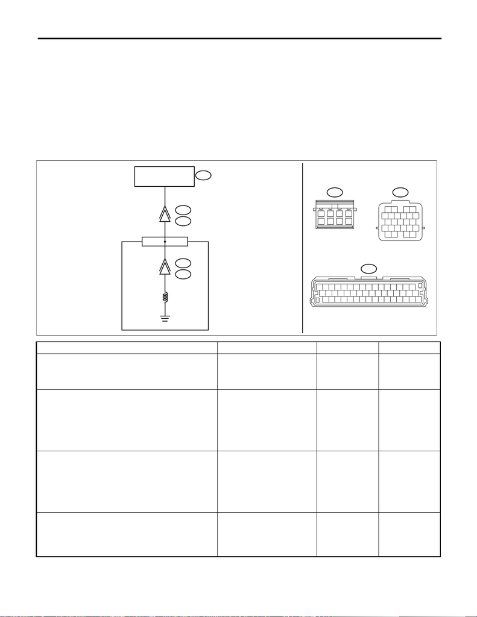

CVT(diag)-66

Diagnostic Procedure with Diagnostic Trouble Code (DTC)

CONTINUOUSLY VARIABLE TRANSMISSION (DIAGNOSTICS)

U: DTC P0776 PRESSURE CONTROL SOLENOID "B" PERFORMANCE/STUCK

OFF

DTC DETECTING CONDITION:

• Detected when two consecutive driving cycles with fault occur.

• GENERAL DESCRIPTION <Ref. to GD(CVT)-29, DTC P0776 PRESSURE CONTROL SOLENOID "B"

PERFORMANCE/STUCK OFF, Diagnostic Trouble Code (DTC) Detecting Criteria.>

TROUBLE SYMPTOM:

• Engine speed increases abruptly, and can not accelerate.

• Excessive slippage is felt.

WIRING DIAGRAM:

CVT control system <Ref. to WI-148, CVT Control System.>

Step Check Yes No

1 CHECK DTC.

Read the DTC using Subaru Select Monitor.

Besides DTC P0776, is any of

the DTCs P0720, P0966,

P0967, P1706 and P2751 dis-

played?

Perform the diag-

nosis according to

DTCs other than

P0776.

Go to step 2.

2 CHECK F&R SOLENOID (SYSTEM OPERA-

TION CHECK MODE).

1) Turn the ignition switch to ON.

2) Using the Subaru Select Monitor, perform

forced operation of the F&R solenoid. <Ref. to

CVT(diag)-22, System Operation Check

Mode.>

Does the indication of 0 → 500

mA appear repeatedly during

forced operation, and does

operating sound emit during

indicating 500 mA?

Go to step 5. Go to step 3.

3 CHECK F&R SOLENOID.

1) Turn the ignition switch to OFF.

2) Disconnect the transmission connector.

3) Measure the resistance between transmis-

sion connector and transmission body.

Connector & terminal

(T4) No. 9 — Transmission body:

Is the resistance approx. 4 — 6

Ω? (when cold)

Go to step 7. Go to step 4.

4 CHECK HARNESS.

Check the continuity of transmission harness.

Is the harness normal? (Is it

free from defects such as open

circuit, power supply-output

short or GND-output short cir-

cuit, or poor contact?)

Go to step 7. Repair the har-

ness.

T11

13

4

6

78

2

5

B54

10 11 12 13 14 15 16

17 18 19 20 21 22 23 24 25 26 27 28 29 30 31 32

33 34 35 36 37 38 39 40 41 42 43 44 45 46 47 48

B11

567

12 34

9

10 11 12

17 18 19 20

8

13 14 15 16

CVT00531

T11

T31

39

16

B11

T4

B54

TCM

CONTROL VALVE BODY

F & R

SOLENOID

[figure not shown]

CVT(diag)-67

Diagnostic Procedure with Diagnostic Trouble Code (DTC)

CONTINUOUSLY VARIABLE TRANSMISSION (DIAGNOSTICS)

V: DTC P0801 REVERSE INHIBIT CONTROL CIRCUIT

DTC DETECTING CONDITION:

• Immediately at fault recognition

• GENERAL DESCRIPTION <Ref. to GD(CVT)-30, DTC P0801 REVERSE INHIBIT CONTROL CIRCUIT,

Diagnostic Trouble Code (DTC) Detecting Criteria.>

NOTE:

For diagnostic procedures, refer to “BODY CONTROL SYSTEM (DIAGNOSTICS)”. <Ref. to BC(diag)-39,

DTC B1016 SHIFT LOCK CIRCUIT FAILURE, Diagnostic Procedure with Diagnostic Trouble Code (DTC).>

2) Check the amount of ATF. <Ref. to

CVT(TR690)-36, ADJUSTMENT, CVTF.>

Is the ATF amount correct? Go to step 6. Adjust the amount

of ATF. <Ref. to

CVT(TR690)-36,

ADJUSTMENT,

CVTF.>

6 CHECK TRANSMISSION FLUID.

Check the condition of ATF. <Ref. to

CVT(TR690)-40, CONDITION CHECK, CVTF.>

Is the ATF OK? Go to step 7. Check according to

the “Corrective

action” of ATF

(CVTF) “CONDI-

TION CHECK”.

<Ref. to

CVT(TR690)-40,

CONDITION

CHECK, CVTF.>

7 CHECK INPUT SIGNAL FOR TCM.

1) Start the engine.

2) Warm up until the ATF temperature reaches

to 40 — 70°C (104 — 158°F).

3) Shift the select lever to “P” range.

4) Stabilize the engine speed at idle.

5) Read the data of «Actual secondary pres-

sure» using Subaru Select Monitor.

Is the «Actual secondary pres-

sure» 0.5 — 1.5 MPa?

Go to step 8. Perform the diag-

nosis according to

DTC P0841. <Ref.

to CVT(diag)-68,

DTC P0841 SEC-

ONDARY OIL

PRESSURE SEN-

SOR PERFOR-

MANCE,

Diagnostic Proce-

dure with Diagnos-

tic Trouble Code

(DTC).>

8 STALL TEST.

Perform the stall test. <Ref. to CVT(TR690)-47,

Stall Test.>

Is the stall test normal? Go to step 9. If the engine speed

increases abruptly,

replace the trans-

mission assembly.

<Ref. to

CVT(TR690)-56,

Automatic Trans-

mission Assem-

bly.>

9 DRIVING CHECK BY INSPECTION MODE.

1) Turn the ignition switch to OFF.

2) Perform a drive check based on the “Inspec-

tion Mode”. <Ref. to CVT(diag)-18, Inspection

Mode.>

Does the AT OIL TEMP light

blink and is DTC P0776 dis-

played?

Replace the trans-

mission assembly.

<Ref. to

CVT(TR690)-56,

Automatic Trans-

mission Assem-

bly.>

If there is abrupt

increase of engine

speed, standing

start problems,

replace the trans-

mission assembly.

<Ref. to

CVT(TR690)-56,

Automatic Trans-

mission Assem-

bly.> If it is normal,

temporary poor

contact occurs.

Step Check Yes No

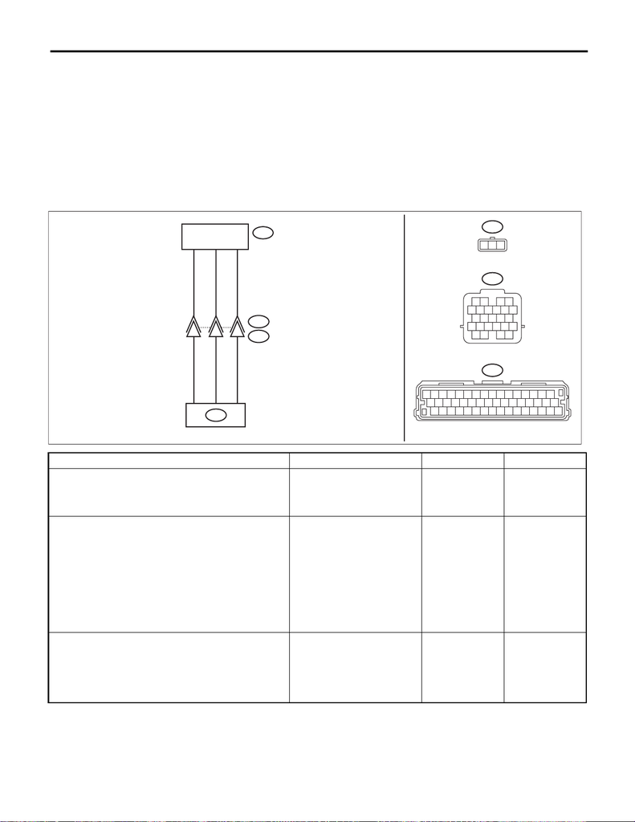

CVT(diag)-68

Diagnostic Procedure with Diagnostic Trouble Code (DTC)

CONTINUOUSLY VARIABLE TRANSMISSION (DIAGNOSTICS)

W: DTC P0841 SECONDARY OIL PRESSURE SENSOR PERFORMANCE

DTC DETECTING CONDITION:

• Immediately at fault recognition

• GENERAL DESCRIPTION <Ref. to GD(CVT)-31, DTC P0841 SECONDARY OIL PRESSURE SENSOR

PERFORMANCE, Diagnostic Trouble Code (DTC) Detecting Criteria.>

TROUBLE SYMPTOM:

• Acceleration is poor during standing start.

• Shift control malfunction

• Engine speed increases abruptly.

WIRING DIAGRAM:

CVT control system <Ref. to WI-148, CVT Control System.>

Step Check Yes No

1 CHECK DTC.

Read the DTC using Subaru Select Monitor.

Besides DTC P0841, is any of

the DTCs P0842, P0843,

P0962 and P0963 displayed?

Perform the diag-

nosis according to

DTCs other than

P0841.

Go to step 2.

2 CHECK HARNESS.

1) Turn the ignition switch to OFF.

2) Disconnect the TCM and transmission con-

nectors.

3) Measure the resistance between TCM con-

nector and transmission connectors.

Connector & terminal

(B54) No. 2 — (B11) No. 18:

(B54) No. 5 — (B11) No. 14:

(B54) No. 33 — (B11) No. 17:

Is the resistance less than 1 Ω? Go to step 3. Repair the open

circuit of harness.

3 CHECK HARNESS.

Measure the resistance between TCM connec-

tor and chassis ground.

Connector & terminal

(B54) No. 5 — Chassis ground:

(B54) No. 33 — Chassis ground:

Is the resistance 1 MΩ or

more?

Go to step 4. Repair the short

circuit of harness.

B54

10 11 12 13 14 15 16

17 18 19 20 21 22 23 24 25 26 27 28 29 30 31 32

33 34 35 36 37 38 39 40 41 42 43 44 45 46 47 48

B11

567

12 34

9

10 11 12

17 18 19 20

8

13 14 15 16

123

AT6

2

17

14

18

B11

T4

5

33

2

3

1

AT6

B54

CVT00527

TCM

SECONDARY PRESSURE SENSOR

[figure not shown]

CVT(diag)-69

Diagnostic Procedure with Diagnostic Trouble Code (DTC)

CONTINUOUSLY VARIABLE TRANSMISSION (DIAGNOSTICS)

4 CHECK TRANSMISSION HARNESS.

1) Disconnect the secondary pressure sensor

connector.

2) Measure the resistance between transmis-

sion connector and secondary pressure sensor

connector.

Connector & terminal

(T4) No. 14 — (AT6) No. 2:

(T4) No. 17 — (AT6) No. 1:

(T4) No. 18 — (AT6) No. 3:

Is the resistance less than 1 Ω? Go to step 5. Repair the open

circuit of harness.

5 CHECK TRANSMISSION HARNESS.

Measure the resistance between transmission

connector and chassis ground.

Connector & terminal

(T4) No. 14 — Chassis ground:

(T4) No. 17 — Chassis ground:

Is the resistance 1 MΩ or

more?

Go to step 6. Repair the short

circuit of harness.

6 CHECK SENSOR POWER SUPPLY.

1) Connect the connectors of TCM and trans-

mission.

2) Turn the ignition switch to ON.

3) Measure the voltage between secondary

pressure sensor connector terminals.

Connector & terminal

(AT6) No. 1 (+) — (AT6) No. 3 (–):

Is the voltage 4.5 V or more? Replace the sec-

ondary pressure

sensor. <Ref. to

CVT(TR690)-110,

Secondary Pres-

sure Sensor.>

Go to step 7.

7 CHECK TRANSMISSION FLUID.

1) Connect all connectors.

2) Check the amount of ATF. <Ref. to

CVT(TR690)-36, ADJUSTMENT, CVTF.>

Is the ATF amount correct? Go to step 8. Adjust the amount

of ATF. <Ref. to

CVT(TR690)-36,

ADJUSTMENT,

CVTF.>

8 CHECK TRANSMISSION FLUID.

Check the condition of ATF. <Ref. to

CVT(TR690)-40, CONDITION CHECK, CVTF.>

Is the ATF OK? Go to step 9. Check according to

the “Corrective

action” of ATF

(CVTF) “CONDI-

TION CHECK”.

<Ref. to

CVT(TR690)-40,

CONDITION

CHECK, CVTF.>

9 CHECK INPUT SIGNAL FOR TCM.

1) Lift up the vehicle.

2) Start the engine.

3) Warm up until the ATF temperature reaches

to 40 — 70°C (104 — 158°F).

4) Shift the select lever to “P” range.

5) Stabilize the engine speed at idle.

6) Read the data of «Actual secondary pres-

sure» using Subaru Select Monitor.

Is the «Actual secondary pres-

sure» 0.5 — 1.5 MPa?

Go to step 10. Replace the sec-

ondary pressure

sensor. <Ref. to

CVT(TR690)-110,

Secondary Pres-

sure Sensor.>

10 CHECK INPUT SIGNAL FOR TCM.

1) Keep the engine speed at 3,000 rpm.

2) Read the data of «Actual secondary pres-

sure» using Subaru Select Monitor.

Is the «Actual secondary pres-

sure» higher than step 9 value?

Does the value change accord-

ing to the engine speed, within

the range of 1.5 — 2.5 MPa?

Go to step 11. Replace the sec-

ondary pressure

sensor. <Ref. to

CVT(TR690)-110,

Secondary Pres-

sure Sensor.>

Step Check Yes No

[figure not shown]

CVT(diag)-70

Diagnostic Procedure with Diagnostic Trouble Code (DTC)

CONTINUOUSLY VARIABLE TRANSMISSION (DIAGNOSTICS)

11 CHECK TCM INPUT SIGNAL (STALL TEST).

1) Apply the parking brake.

2) Set the select lever to “D” range.

3) Depress the brake pedal firmly.

4) Slowly open the accelerator fully, and stabi-

lize the engine speed.

5) Read the data of «Actual secondary pres-

sure» using Subaru Select Monitor.

CAUTION:

Do not perform a stall test for over 5 sec-

onds at a time.

Is the «Actual secondary pres-

sure» higher than step 10

value? Does the value change

according to the engine speed,

within the range of 4.5 — 6.0

MPa?

Go to step 12. Replace the sec-

ondary pressure

sensor. <Ref. to

CVT(TR690)-110,

Secondary Pres-

sure Sensor.>

12 DRIVING CHECK BY INSPECTION MODE.

1) Turn the ignition switch to OFF.

2) Perform a drive check based on the “Inspec-

tion Mode”. <Ref. to CVT(diag)-18, Inspection

Mode.>

Does the AT OIL TEMP light

blink and is DTC P0841 dis-

played?

Perform the sec-

ondary pressure

test. <Ref. to

CVT(TR690)-49,

Secondary Pres-

sure (Line Pres-

sure) Test.>

If there is shift

problems, abrupt

increase of engine

speed, standing

start problems,

replace the trans-

mission assembly.

<Ref. to

CVT(TR690)-56,

Automatic Trans-

mission Assem-

bly.> If it is normal,

temporary poor

contact occurs.

Step Check Yes No

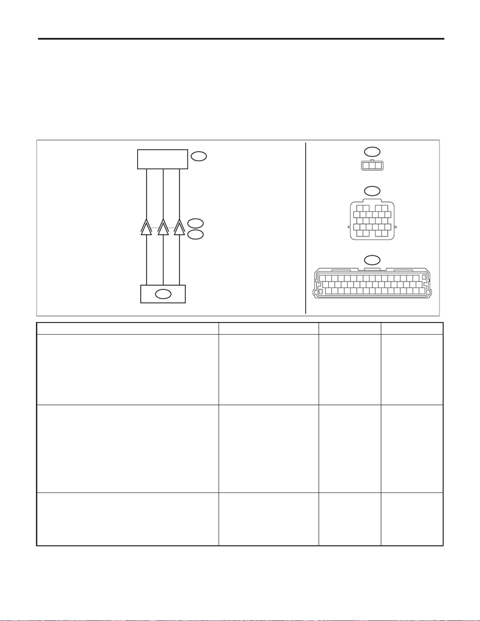

CVT(diag)-71

Diagnostic Procedure with Diagnostic Trouble Code (DTC)

CONTINUOUSLY VARIABLE TRANSMISSION (DIAGNOSTICS)

X: DTC P0842 SECONDARY OIL PRESSURE SENSOR CIRCUIT (LOW)

DTC DETECTING CONDITION:

• Immediately at fault recognition

• GENERAL DESCRIPTION <Ref. to GD(CVT)-32, DTC P0842 SECONDARY OIL PRESSURE SENSOR

CIRCUIT (LOW), Diagnostic Trouble Code (DTC) Detecting Criteria.>

TROUBLE SYMPTOM:

Shift characteristics malfunction

WIRING DIAGRAM:

CVT control system <Ref. to WI-148, CVT Control System.>

Step Check Yes No

1 CHECK INPUT SIGNAL FOR TCM.

1) Start the engine.

2) Warm up until the ATF temperature reaches

to 40 — 70°C (104 — 158°F).

3) Shift the select lever to “P” range.

4) Stabilize the engine speed at idle.

5) Read the data of «Actual secondary pres-

sure» using Subaru Select Monitor.

Is the «Actual secondary pres-

sure» 0.5 — 1.5 MPa?

Check for poor

contact of connec-

tor.

Go to step 2.

2 CHECK HARNESS.

1) Turn the ignition switch to OFF.

2) Disconnect the TCM and transmission con-

nectors.

3) Measure the resistance between TCM con-

nector and transmission connectors.

Connector & terminal

(B54) No. 2 — (B11) No. 18:

(B54) No. 5 — (B11) No. 14:

(B54) No. 33 — (B11) No. 17:

Is the resistance less than 1 Ω? Go to step 3. Repair the open

circuit of harness.

3 CHECK HARNESS.

Measure the resistance between TCM connec-

tor and chassis ground.

Connector & terminal

(B54) No. 5 — Chassis ground:

(B54) No. 33 — Chassis ground:

Is the resistance 1 MΩ or

more?

Go to step 4. Repair the short

circuit of harness.

B54

10 11 12 13 14 15 16

17 18 19 20 21 22 23 24 25 26 27 28 29 30 31 32

33 34 35 36 37 38 39 40 41 42 43 44 45 46 47 48

B11

567

12 34

9

10 11 12

17 18 19 20

8

13 14 15 16

123

AT6

2

17

14

18

B11

T4

5

33

2

3

1

AT6

B54

CVT00527

TCM

SECONDARY PRESSURE SENSOR

[figure not shown]

CVT(diag)-72

Diagnostic Procedure with Diagnostic Trouble Code (DTC)

CONTINUOUSLY VARIABLE TRANSMISSION (DIAGNOSTICS)

4 CHECK TRANSMISSION HARNESS.

1) Disconnect the secondary pressure sensor

connector.

2) Measure the resistance between transmis-

sion connector and secondary pressure sensor

connector.

Connector & terminal

(T4) No. 14 — (AT6) No. 2:

(T4) No. 17 — (AT6) No. 1:

(T4) No. 18 — (AT6) No. 3:

Is the resistance less than 1 Ω? Go to step 5. Repair the open

circuit of harness.

5 CHECK TRANSMISSION HARNESS.

Measure the resistance between transmission

connector and chassis ground.

Connector & terminal

(T4) No. 14 — Chassis ground:

(T4) No. 17 — Chassis ground:

Is the resistance 1 MΩ or

more?

Go to step 6. Repair the short

circuit of harness.

6 CHECK SENSOR POWER SUPPLY.

1) Connect the connectors of TCM and trans-

mission.

2) Turn the ignition switch to ON.

3) Measure the voltage between secondary

pressure sensor connector terminals.

Connector & terminal

(AT6) No. 1 (+) — (AT6) No. 3 (–):

Is the voltage 4.5 V or more? Replace the sec-

ondary pressure

sensor. <Ref. to

CVT(TR690)-110,

Secondary Pres-

sure Sensor.>

Check for poor

contact of connec-

tor, and if no fault is

found, replace the

TCM. <Ref. to

CVT(TR690)-126,

Transmission Con-

trol Module

(TCM).>

Step Check Yes No

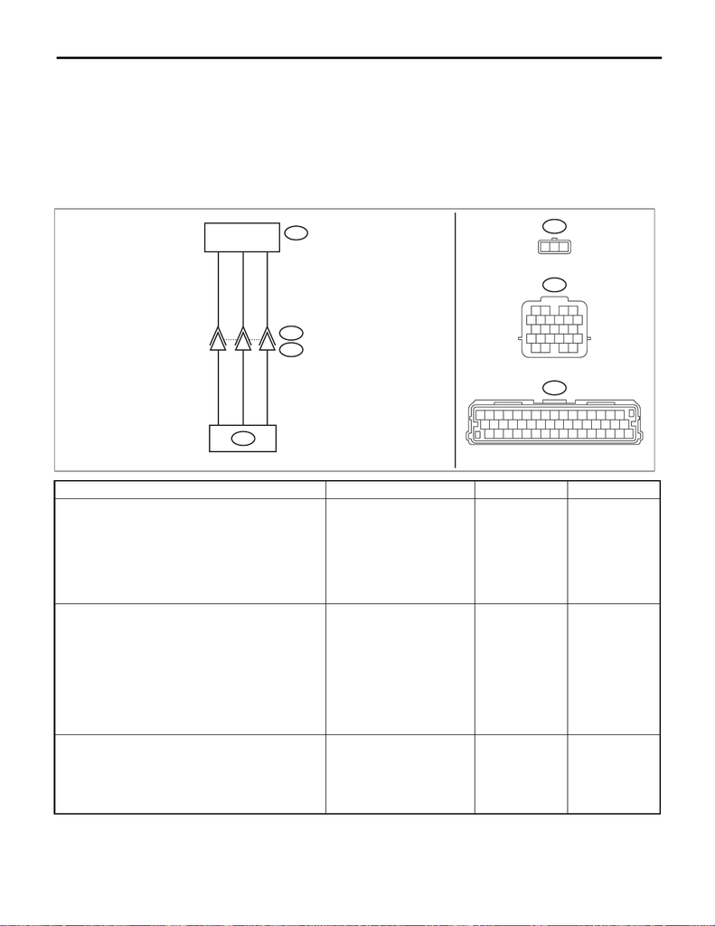

CVT(diag)-73

Diagnostic Procedure with Diagnostic Trouble Code (DTC)

CONTINUOUSLY VARIABLE TRANSMISSION (DIAGNOSTICS)

Y: DTC P0843 SECONDARY OIL PRESSURE SENSOR CIRCUIT (HIGH)

DTC DETECTING CONDITION:

• Immediately at fault recognition

• GENERAL DESCRIPTION <Ref. to GD(CVT)-33, DTC P0843 SECONDARY OIL PRESSURE SENSOR

CIRCUIT (HIGH), Diagnostic Trouble Code (DTC) Detecting Criteria.>

TROUBLE SYMPTOM:

Shift characteristics malfunction

WIRING DIAGRAM:

CVT control system <Ref. to WI-148, CVT Control System.>

Step Check Yes No

1 CHECK INPUT SIGNAL FOR TCM.

1) Start the engine.

2) Warm up until the ATF temperature reaches

to 40 — 70°C (104 — 158°F).

3) Shift the select lever to “P” range.

4) Stabilize the engine speed at idle.

5) Read the data of «Actual secondary pres-

sure» using Subaru Select Monitor.

Is the «Actual secondary pres-

sure» 0.5 — 1.5 MPa?

Check for poor

contact of connec-

tor.

Go to step 2.

2 CHECK HARNESS.

1) Turn the ignition switch to OFF.

2) Disconnect the TCM and transmission con-

nectors.

3) Turn the ignition switch to ON.

4) Measure the voltage between TCM connec-

tor and chassis ground.

Connector & terminal

(B54) No. 5 (+) — Chassis ground (–):

(B54) No. 33 (+) — Chassis ground (–):

Is the voltage approx. 0 V? Go to step 3. Repair the short

circuit of harness.

3 CHECK HARNESS.

1) Turn the ignition switch to OFF.

2) Measure the resistance between TCM con-

nector terminals.

Connector & terminal

(B54) No. 5 — (B54) No. 33:

Is the resistance less than 1 Ω? Repair the short

circuit of harness.

Go to step 4.

B54

10 11 12 13 14 15 16

17 18 19 20 21 22 23 24 25 26 27 28 29 30 31 32

33 34 35 36 37 38 39 40 41 42 43 44 45 46 47 48

B11

567

12 34

9

10 11 12

17 18 19 20

8

13 14 15 16

123

AT6

2

17

14

18

B11

T4

5

33

2

3

1

AT6

B54

CVT00527

TCM

SECONDARY PRESSURE SENSOR

[figure not shown]

CVT(diag)-74

Diagnostic Procedure with Diagnostic Trouble Code (DTC)

CONTINUOUSLY VARIABLE TRANSMISSION (DIAGNOSTICS)

4 CHECK TRANSMISSION HARNESS.

1) Disconnect the secondary pressure sensor

connector.

2) Turn the ignition switch to ON.

3) Measure the voltage between transmission

connector and chassis ground.

Connector & terminal

(T4) No. 14 (+) — Chassis ground (–):

(T4) No. 17 (+) — Chassis ground (–):

Is the voltage approx. 0 V? Go to step 5. Repair the short

circuit of harness.

5 CHECK TRANSMISSION HARNESS.

1) Turn the ignition switch to OFF.

2) Measure the resistance between transmis-

sion connector terminals.

Connector & terminal

(T4) No. 14 — (T4) No. 17:

Is the resistance less than 1 Ω? Repair the short

circuit of harness.

Go to step 6.

6 CHECK SENSOR POWER SUPPLY.

1) Connect the connectors of TCM and trans-

mission.

2) Turn the ignition switch to ON.

3) Measure the voltage between secondary

pressure sensor connector terminals.

Connector & terminal

(AT6) No. 1 (+) — (AT6) No. 3 (–):

Is the voltage 4.5 V or more? Replace the sec-

ondary pressure

sensor. <Ref. to

CVT(TR690)-110,

Secondary Pres-

sure Sensor.>

Check for poor

contact of connec-

tor, and if no fault is

found, replace the

TCM. <Ref. to

CVT(TR690)-126,

Transmission Con-

trol Module

(TCM).>

Step Check Yes No

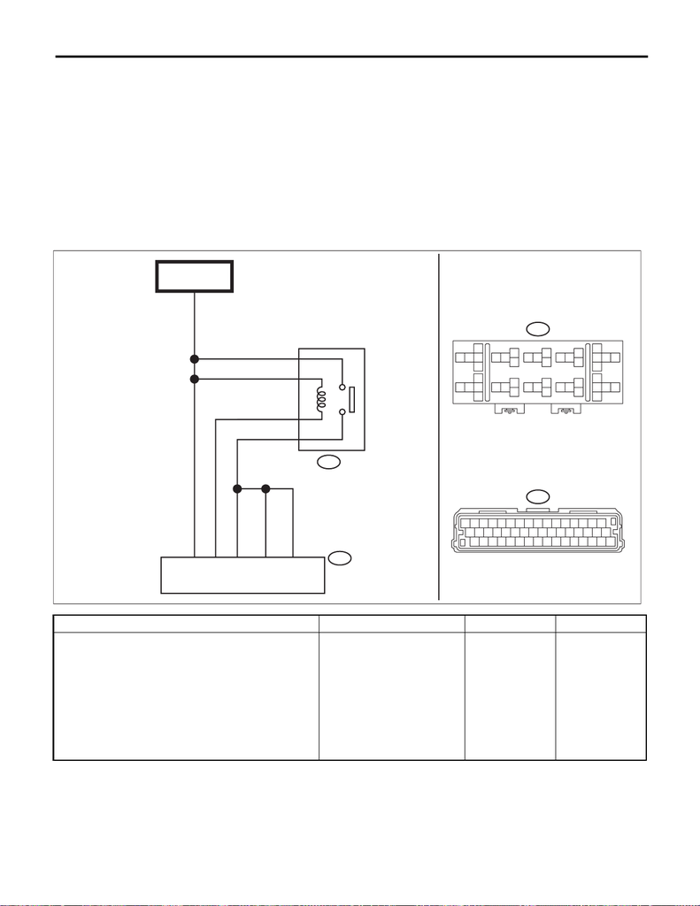

CVT(diag)-75

Diagnostic Procedure with Diagnostic Trouble Code (DTC)

CONTINUOUSLY VARIABLE TRANSMISSION (DIAGNOSTICS)

Z: DTC P0890 AT SELF-SHUT RELAY DIAGNOSIS (LOW)

DTC DETECTING CONDITION:

• Immediately at fault recognition

• GENERAL DESCRIPTION <Ref. to GD(CVT)-34, DTC P0890 AT SELF-SHUT RELAY DIAGNOSIS

(LOW), Diagnostic Trouble Code (DTC) Detecting Criteria.>

TROUBLE SYMPTOM:

Gear is not changed.

CAUTION:

After diagnosis, perform Clear Memory Mode for ECM. <Ref. to EN(w/o STI)(diag)-61, Clear Memory

Mode.>

WIRING DIAGRAM:

CVT control system <Ref. to WI-148, CVT Control System.>

Step Check Yes No

1 CHECK HARNESS.

1) Disconnect the TCM and self shut relay con-

nectors.

2) Measure the resistance between TCM con-

nector and self shut relay connector.

Connector & terminal

(B54) No. 25 — (B220) No. 16:

(B54) No. 8 — (B220) No. 15:

(B54) No. 24 — (B220) No. 15:

(B54) No. 40 — (B220) No. 15:

Is the resistance less than 1 Ω? Go to step 2. Repair the open

circuit of harness.

B220

10 11

12

13

14 15

16

18

19 21 22

20

17

24

5

3

17

9

8

6

32 33

34

35

25

27

29

30

31

36 37

38

40

41 43 44

42

39

16

31 32

33 34 35 36 37 38 39 40 41 42 43 44 45 46 47 48

B54

10 11 12 13 14 15

17 18 19 20 21 22 23 24 25 26 27 28 29 30

17

14

16

B220

15

40

34

25

8

24

B54

CVT00528

TCM

MB-26

M/B FUSE NO. 12

(B)

SELF SHUT RELAY

RELAY HOLDER

[figure not shown]

CVT(diag)-76

Diagnostic Procedure with Diagnostic Trouble Code (DTC)

CONTINUOUSLY VARIABLE TRANSMISSION (DIAGNOSTICS)

2 CHECK HARNESS.

Measure the resistance between TCM connec-

tor and chassis ground.

Connector & terminal

(B54) No. 25 — Chassis ground:

(B54) No. 8 — Chassis ground:

(B54) No. 24 — Chassis ground:

(B54) No. 40 — Chassis ground:

Is the resistance 1 MΩ or

more?

Go to step 3. Repair the short

circuit of harness.

3 CHECK RELAY POWER SUPPLY.

Measure the voltage between self shut relay

connector and chassis ground.

Connector & terminal

(B220) No. 14 (+) — Chassis ground (–):

(B220) No. 17 (+) — Chassis ground (–):

Is the voltage 11 — 13 V or

more?

Go to step 4. Repair the open or

short circuit of har-

ness.

4 CHECK SELF SHUT RELAY.

Measure the resistance between self shut relay

terminals.

Connector & terminal

(B220) No. 16 — (B220) No. 17:

Is the resistance 110 — 140 Ω? Go to step 5. Replace the self

shut relay.

5 CHECK SELF SHUT RELAY.

Measure the resistance between self shut relay

terminals.

Connector & terminal

(B220) No. 14 — (B220) No. 15:

Is the resistance 1 MΩ or

more?

Go to step 6. Replace the self

shut relay.

6 CHECK INPUT SIGNAL FOR TCM.

1) Connect the connectors of TCM and self

shut relay.

2) Read the data of «Control module voltage»

using Subaru Select Monitor.

Is the «Control module volt-

age» 10 V or more?

Current condition

is normal. Check

for poor contact in

connectors or har-

nesses, and repair

the defective part.

Go to step 7.

7 CHECK FOR POOR CONTACT. Is there poor contact of the self

shut relay circuit?

Repair the poor

contact.

Replace the TCM.

<Ref. to

CVT(TR690)-126,

Transmission Con-

trol Module

(TCM).>

Step Check Yes No

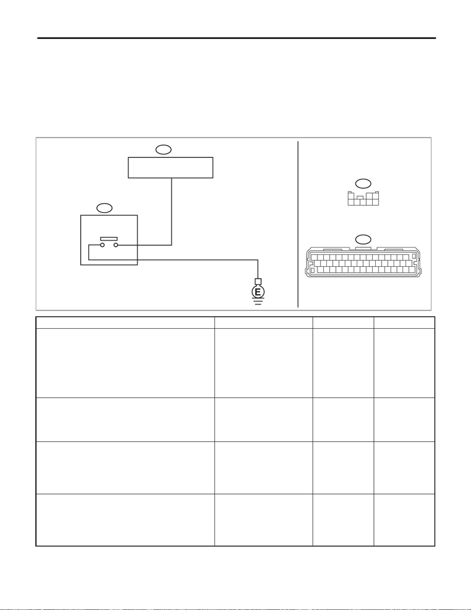

CVT(diag)-77

Diagnostic Procedure with Diagnostic Trouble Code (DTC)

CONTINUOUSLY VARIABLE TRANSMISSION (DIAGNOSTICS)

AA:DTC P0951 MANUAL SWITCH

DTC DETECTING CONDITION:

• Immediately at fault recognition

• GENERAL DESCRIPTION <Ref. to GD(CVT)-35, DTC P0951 MANUAL SWITCH, Diagnostic Trouble

Code (DTC) Detecting Criteria.>

TROUBLE SYMPTOM:

Manual mode can not be set.

WIRING DIAGRAM:

CVT control system <Ref. to WI-148, CVT Control System.>

Step Check Yes No

1 CHECK HARNESS.

1) Turn the ignition switch to OFF.

2) Disconnect the manual mode switch con-

nector.

3) Measure the resistance between manual

mode switch connector and chassis ground.

Connector & terminal

(B116) No. 8 — Chassis ground:

Is the resistance less than 1 Ω? Go to step 2. Repair the open

circuit of harness.

2 CHECK MANUAL MODE SWITCH.

Measure the resistance between manual mode

switch terminals.

Connector & terminal

(B116) No. 7 — No. 8:

Is the resistance 1 MΩ or

more?

Go to step 3. Replace the select

lever assembly.

<Ref. to CS-24,

Select Lever.>

3 CHECK MANUAL MODE SWITCH.

1) Shift the select lever to manual mode.

2) Measure the resistance between manual

mode switch terminals.

Connector & terminal

(B116) No. 7 — No. 8:

Is the resistance less than 1 Ω? Go to step 4. Replace the select

lever assembly.

<Ref. to CS-24,

Select Lever.>

4 CHECK HARNESS.

1) Disconnect the TCM connector.

2) Measure the resistance between TCM con-

nector and manual mode switch connector.

Connector & terminal

(B54) No. 20 — (B116) No. 7:

Is the resistance less than 1 Ω? Go to step 5. Repair the open

circuit of harness

or poor contact of

connector.

B116

123

45678

B54

10 11 12 13 14 15 16

17 18 19 20 21 22 23 24 25 26 27 28 29 30 31 32

33 34 35 36 37 38 39 40 41 42 43 44 45 46 47 48

20

B54

8

7

B116

CVT00529

TCM

SELECT LEVER

MANUAL MODE

SWITCH

[figure not shown]

CVT(diag)-78

Diagnostic Procedure with Diagnostic Trouble Code (DTC)

CONTINUOUSLY VARIABLE TRANSMISSION (DIAGNOSTICS)

5 CHECK HARNESS.

Measure the resistance between manual mode

switch connector and chassis ground.

Connector & terminal

(B116) No. 7 — Chassis ground:

Is the resistance 1 MΩ or

more?

Go to step 6. Repair the short

circuit of harness.

6 CHECK INPUT SIGNAL FOR TCM.

1) Connect the TCM and manual mode switch

connector.

2) Turn the ignition switch to ON.

3) Set the select lever to “D” range.

4) Read the data of «Tiptronic Mode Switch»

using Subaru Select Monitor.

Does the value of «Tiptronic

Mode Switch» change to “ON”

with select lever in manual

mode, and “OFF” with select

lever in other than manual

mode?

Current condition

is normal.

Go to step 7.

7 CHECK FOR POOR CONTACT. Is there poor contact of the

manual mode switch circuit?

Repair the poor

contact.

Replace the TCM.

<Ref. to

CVT(TR690)-126,

Transmission Con-

trol Module

(TCM).>

Step Check Yes No

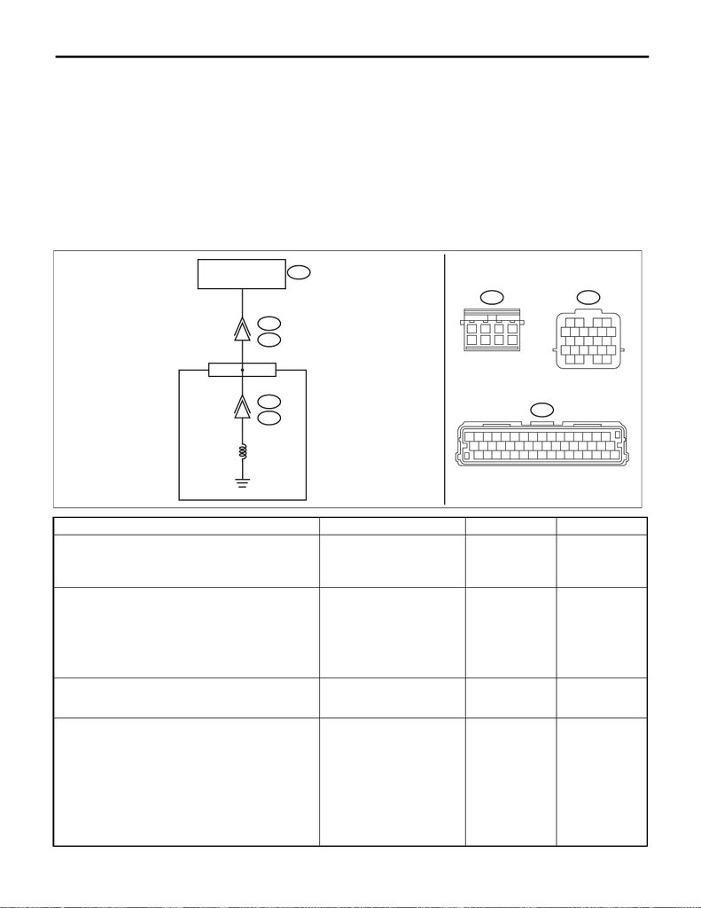

CVT(diag)-79

Diagnostic Procedure with Diagnostic Trouble Code (DTC)

CONTINUOUSLY VARIABLE TRANSMISSION (DIAGNOSTICS)

AB:DTC P0961 PRESSURE CONTROL SOLENOID "A" CONTROL CIRCUIT

RANGE/PERFORMANCE

DTC DETECTING CONDITION:

• Immediately at fault recognition

• GENERAL DESCRIPTION <Ref. to GD(CVT)-36, DTC P0961 PRESSURE CONTROL SOLENOID "A"

CONTROL CIRCUIT RANGE/PERFORMANCE, Diagnostic Trouble Code (DTC) Detecting Criteria.>

TROUBLE SYMPTOM:

• Acceleration is poor during standing start.

• Shift control malfunction

• Engine speed increases abruptly.

WIRING DIAGRAM:

CVT control system <Ref. to WI-148, CVT Control System.>

Step Check Yes No

1 CHECK DTC.

Read the DTC using Subaru Select Monitor.

Besides DTC P0961, is DTC

P0962 or P0963 displayed?

Perform the diag-

nosis according to

DTCs other than

P0961.

Go to step 2.

2 CHECK SECONDARY SOLENOID (SYSTEM

OPERATION CHECK MODE).

1) Turn the ignition switch to ON.

2) Using the Subaru Select Monitor, perform

forced operation of the secondary solenoid.

<Ref. to CVT(diag)-22, System Operation

Check Mode.>

Does the indication change as

300 → 500 → 700 mA during

forced operation, and does

«Sec. Sol. Actual Current» syn-

chronize with «Sec. Sol. Set

Current»?

Go to step 3. Replace the con-

trol valve body.

<Ref. to

CVT(TR690)-112,

Control Valve

Body.>

3 CHECK FOR POOR CONTACT.

Check for poor contact of harness and connec-

tor between TCM and secondary solenoid.

Is there poor contact? Repair the poor

contact of harness

and connector.

Go to step 4.

4 CHECK SECONDARY SOLENOID.

1) Turn the ignition switch to OFF.

2) Disconnect the transmission connector.

3) Measure the resistance between transmis-

sion connector and transmission body.

Connector & terminal

(T4) No. 5 — Transmission body:

Is the resistance approx. 5 — 7

Ω? (when cold)

Recheck the poor

contact of harness

and connector.

Replace the TCM if

no fault is found.

<Ref. to

CVT(TR690)-126,

Transmission Con-

trol Module

(TCM).>

Replace the con-

trol valve body.

<Ref. to

CVT(TR690)-112,

Control Valve

Body.>

T11

13

4

6

78

2

5

B54

10 11 12 13 14 15 16

17 18 19 20 21 22 23 24 25 26 27 28 29 30 31 32

33 34 35 36 37 38 39 40 41 42 43 44 45 46 47 48

B11

567

12 34

9

10 11 12

17 18 19 20

8

13 14 15 16

CVT00530

T11

T31

15

32

B11

T4

B54

TCM

CONTROL VALVE BODY

SECONDARY

SOLENOID

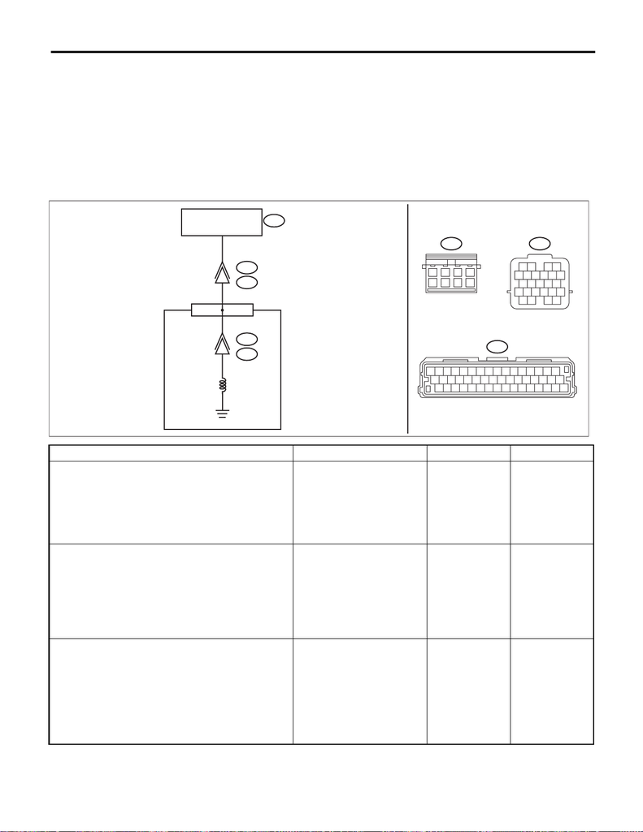

CVT(diag)-80

Diagnostic Procedure with Diagnostic Trouble Code (DTC)

CONTINUOUSLY VARIABLE TRANSMISSION (DIAGNOSTICS)

AC:DTC P0962 SECONDARY SOLENOID CIRCUIT (LOW)

DTC DETECTING CONDITION:

• Immediately at fault recognition

• GENERAL DESCRIPTION <Ref. to GD(CVT)-37, DTC P0962 SECONDARY SOLENOID CIRCUIT

(LOW), Diagnostic Trouble Code (DTC) Detecting Criteria.>

TROUBLE SYMPTOM:

• Engine speed increases abruptly, and can not start.

• Engine speed increases abruptly during driving.

WIRING DIAGRAM:

CVT control system <Ref. to WI-148, CVT Control System.>

Step Check Yes No

1 CHECK INPUT SIGNAL FOR TCM.

1) After driving with warm up condition, park

the vehicle while depressing the brake pedal at

“N” range.

2) Read the data of «Sec. Sol. Set Current»

and «Sec. Sol. Actual Current» using Subaru

Select Monitor.

Does the value of «Sec. Sol.

Set Current» and «Sec. Sol.

Actual Current» almost corre-

spond?

Check for poor

contact of connec-

tor.

Go to step 2.

2 CHECK HARNESS.

1) Turn the ignition switch to OFF.

2) Disconnect the TCM and transmission con-

nectors.

3) Measure the resistance between TCM con-

nector and chassis ground.

Connector & terminal

(B54) No. 32 — Chassis ground:

Is the resistance 1 MΩ or

more?

Go to step 3. Repair the short

circuit of harness.

3 CHECK SECONDARY SOLENOID.

Measure the resistance between transmission

connector and transmission body.

Connector & terminal

(T4) No. 5 — Transmission body:

Is the resistance approx. 5 — 7

Ω? (when cold)

Check for poor

contact of connec-

tor, and if no fault is

found, replace the

TCM. <Ref. to

CVT(TR690)-126,

Transmission Con-

trol Module

(TCM).>

Go to step 4.

T11

13

4

6

78

2

5

B54

10 11 12 13 14 15 16

17 18 19 20 21 22 23 24 25 26 27 28 29 30 31 32

33 34 35 36 37 38 39 40 41 42 43 44 45 46 47 48

B11

567

12 34

9

10 11 12

17 18 19 20

8

13 14 15 16

CVT00530

T11

T31

15

32

B11

T4

B54

TCM

CONTROL VALVE BODY

SECONDARY

SOLENOID

[figure not shown]

CVT(diag)-81

Diagnostic Procedure with Diagnostic Trouble Code (DTC)

CONTINUOUSLY VARIABLE TRANSMISSION (DIAGNOSTICS)

4 CHECK HARNESS INSIDE TRANSMISSION.

CAUTION:

Start work after ATF cools down.

1) Remove the transmission oil pan.

2) Check for the harness pinch, damage.

Is there any fault in the har-

ness?

Replace the trans-

mission harness.

Go to step 5.

5 CHECK HARNESS INSIDE TRANSMISSION.

1) Disconnect the control valve body connec-

tor.

2) Measure the resistance between transmis-

sion connector and transmission body.

Connector & terminal

(T4) No. 5 — Transmission body:

Is the resistance 1 MΩ or

more?

Replace the con-

trol valve body.

<Ref. to

CVT(TR690)-112,

Control Valve

Body.>

Replace the trans-

mission harness.

Step Check Yes No

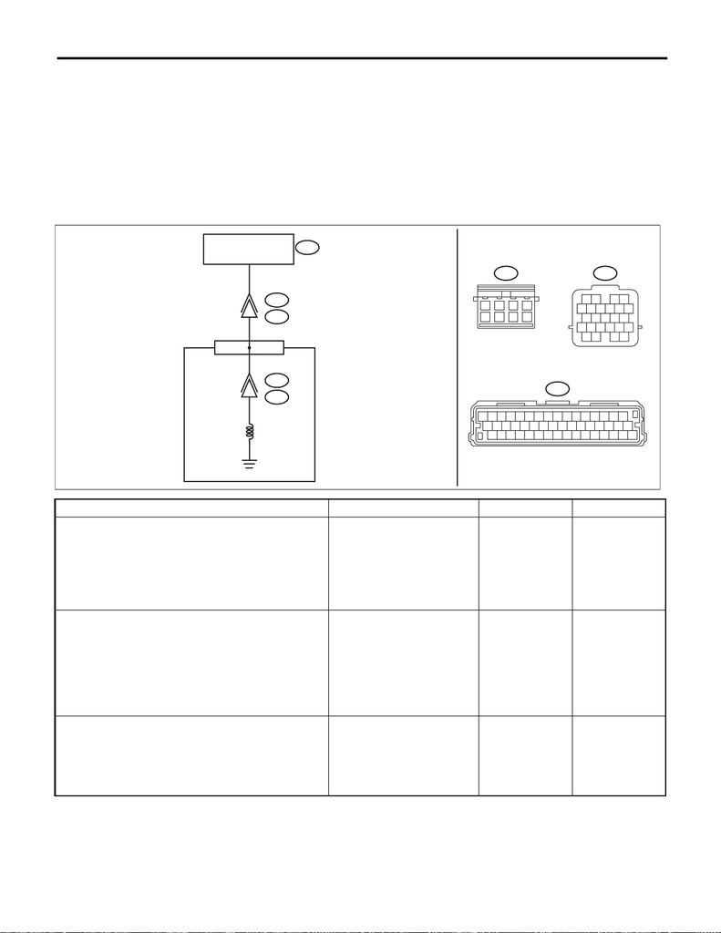

CVT(diag)-82

Diagnostic Procedure with Diagnostic Trouble Code (DTC)

CONTINUOUSLY VARIABLE TRANSMISSION (DIAGNOSTICS)

AD:DTC P0963 SECONDARY SOLENOID CIRCUIT (HIGH)

DTC DETECTING CONDITION:

• Immediately at fault recognition

• GENERAL DESCRIPTION <Ref. to GD(CVT)-38, DTC P0963 SECONDARY SOLENOID CIRCUIT

(HIGH), Diagnostic Trouble Code (DTC) Detecting Criteria.>

TROUBLE SYMPTOM:

• Engine speed increases abruptly, and can not start.

• Engine speed increases abruptly during driving.

WIRING DIAGRAM:

CVT control system <Ref. to WI-148, CVT Control System.>

Step Check Yes No

1 CHECK INPUT SIGNAL FOR TCM.

1) After driving with warm up condition, park

the vehicle while depressing the brake pedal at

“N” range.

2) Read the data of «Sec. Sol. Set Current»

and «Sec. Sol. Actual Current» using Subaru

Select Monitor.

Does the value of «Sec. Sol.

Set Current» and «Sec. Sol.

Actual Current» almost corre-

spond?

Check for poor

contact of connec-

tor.

Go to step 2.

2 CHECK HARNESS.

1) Turn the ignition switch to OFF.

2) Disconnect the TCM and transmission con-

nectors.

3) Measure the resistance between TCM con-

nector and transmission connectors.

Connector & terminal

(B54) No. 32 — (B11) No. 5:

Is the resistance less than 1 Ω? Go to step 3. Repair the open

circuit of harness.

3 CHECK HARNESS.

1) Turn the ignition switch to ON.

2) Measure the voltage between TCM connec-

tor and chassis ground.

Connector & terminal

(B54) No. 32 (+) — Chassis ground (–):

Is the voltage approx. 0 V? Go to step 4. Repair the short

circuit of harness.

T11

13

4

6

78

2

5

B54

10 11 12 13 14 15 16

17 18 19 20 21 22 23 24 25 26 27 28 29 30 31 32

33 34 35 36 37 38 39 40 41 42 43 44 45 46 47 48

B11

567

12 34

9

10 11 12

17 18 19 20

8

13 14 15 16

CVT00530

T11

T31

15

32

B11

T4

B54

TCM

CONTROL VALVE BODY

SECONDARY

SOLENOID

[figure not shown]

CVT(diag)-83

Diagnostic Procedure with Diagnostic Trouble Code (DTC)

CONTINUOUSLY VARIABLE TRANSMISSION (DIAGNOSTICS)

4 CHECK SECONDARY SOLENOID.

Measure the resistance between transmission

connector and transmission body.

Connector & terminal

(T4) No. 5 — Transmission body:

Is the resistance approx. 5 — 7

Ω? (when cold)

Check for poor

contact of connec-

tor, and if no fault is

found, replace the

TCM. <Ref. to

CVT(TR690)-126,

Transmission Con-

trol Module

(TCM).>

Go to step 5.

5 CHECK HARNESS INSIDE TRANSMISSION.

CAUTION:

Start work after ATF cools down.

1) Remove the transmission oil pan.

2) Check for the harness pinch, damage.

Is there any fault in the har-

ness?

Replace the trans-

mission harness.

Go to step 6.

6 CHECK HARNESS INSIDE TRANSMISSION.

1) Disconnect the control valve body connec-

tor.

2) Turn the ignition switch to ON.

3) Measure the voltage between transmission

connector and transmission body.

Connector & terminal

(T4) No. 5 (+) — Transmission body (–):

Is the voltage approx. 0 V? Replace the con-

trol valve body.

<Ref. to

CVT(TR690)-112,

Control Valve

Body.>

Replace the trans-

mission harness.

Step Check Yes No

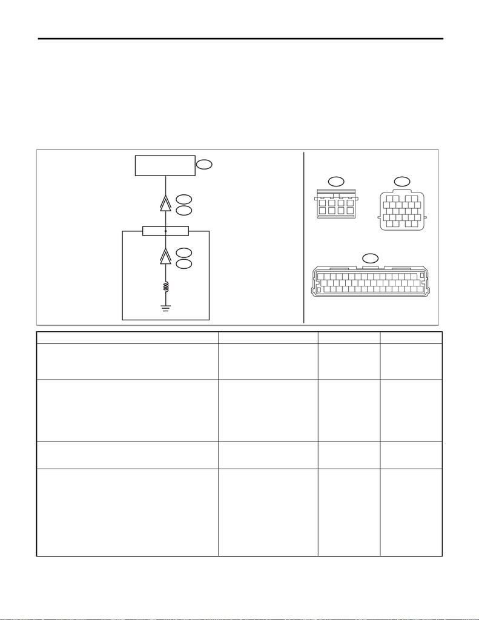

CVT(diag)-84

Diagnostic Procedure with Diagnostic Trouble Code (DTC)

CONTINUOUSLY VARIABLE TRANSMISSION (DIAGNOSTICS)

AE:DTC P0965 FORWARD & REVERSE SOLENOID FUNCTION

DTC DETECTING CONDITION:

• Immediately at fault recognition

• GENERAL DESCRIPTION <Ref. to GD(CVT)-39, DTC P0965 FORWARD & REVERSE SOLENOID

FUNCTION, Diagnostic Trouble Code (DTC) Detecting Criteria.>

TROUBLE SYMPTOM:

• Engine speed increases abruptly, and can not accelerate.

• Excessive slippage is felt.

WIRING DIAGRAM:

CVT control system <Ref. to WI-148, CVT Control System.>

Step Check Yes No

1 CHECK DTC.

Read the DTC using Subaru Select Monitor.

Besides DTC P0965, is any of

the DTCs P0720, P0966,

P0967, P1706 and P2751 dis-

played?

Perform the diag-

nosis according to

DTCs other than

P0965.

Go to step 2.

2 CHECK F&R SOLENOID (SYSTEM OPERA-

TION CHECK MODE).

1) Turn the ignition switch to ON.

2) Using the Subaru Select Monitor, perform

forced operation of the F&R solenoid. <Ref. to

CVT(diag)-22, System Operation Check

Mode.>

Does the indication change as

300 → 500 → 700 mA during

forced operation, and does

«F&R Linear Solenoid Actual

Current» synchronize with

«F&R Linear Solenoid Set Cur-

rent»?

Go to step 3. Replace the con-

trol valve body.

<Ref. to

CVT(TR690)-112,

Control Valve

Body.>

3 CHECK FOR POOR CONTACT.

Check for poor contact of harness and connec-

tor between TCM and F&R solenoid.

Is there poor contact? Repair the poor

contact of harness

and connector.

Go to step 4.

4 CHECK F&R SOLENOID.

1) Turn the ignition switch to OFF.

2) Disconnect the transmission connector.

3) Measure the resistance between transmis-

sion connector and transmission body.

Connector & terminal

(T4) No. 9 — Transmission body:

Is the resistance approx. 4 — 6

Ω? (when cold)

Recheck the poor

contact of harness

and connector.

Replace the TCM if

no fault is found.

<Ref. to

CVT(TR690)-126,

Transmission Con-

trol Module

(TCM).>

Replace the con-

trol valve body.

<Ref. to

CVT(TR690)-112,

Control Valve

Body.>

T11

13

4

6

78

2

5

B54

10 11 12 13 14 15 16

17 18 19 20 21 22 23 24 25 26 27 28 29 30 31 32

33 34 35 36 37 38 39 40 41 42 43 44 45 46 47 48

B11

567

12 34

9

10 11 12

17 18 19 20

8

13 14 15 16

CVT00531

T11

T31

39

16

B11

T4

B54

TCM

CONTROL VALVE BODY

F & R

SOLENOID

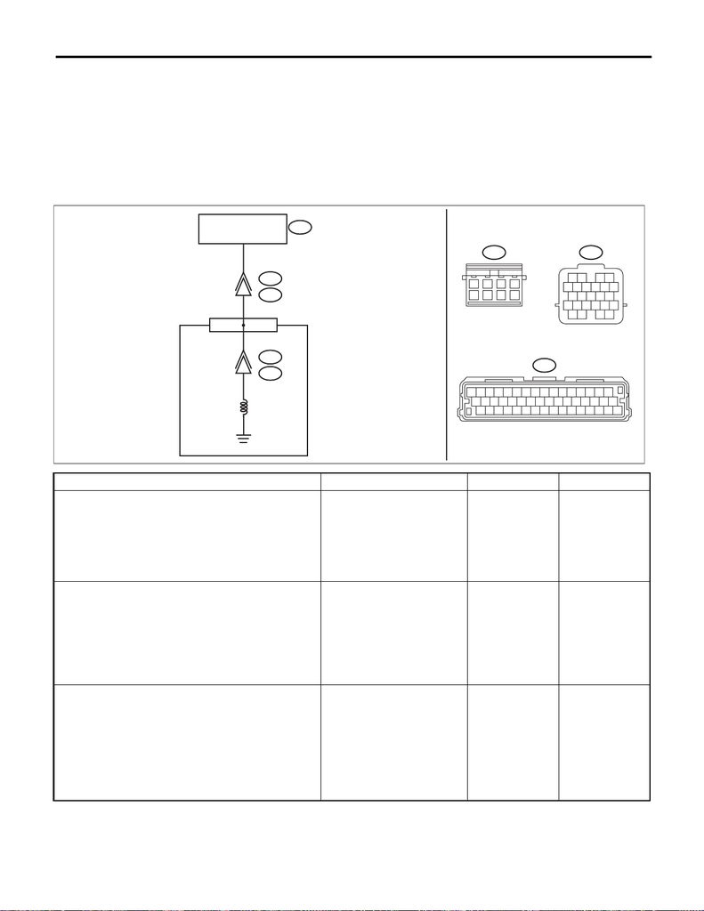

CVT(diag)-85

Diagnostic Procedure with Diagnostic Trouble Code (DTC)

CONTINUOUSLY VARIABLE TRANSMISSION (DIAGNOSTICS)

AF:DTC P0966 FORWARD & REVERSE SOLENOID CIRCUIT (LOW)

DTC DETECTING CONDITION:

• Immediately at fault recognition

• GENERAL DESCRIPTION <Ref. to GD(CVT)-40, DTC P0966 FORWARD & REVERSE SOLENOID CIR-

CUIT (LOW), Diagnostic Trouble Code (DTC) Detecting Criteria.>

TROUBLE SYMPTOM:

Excessive shift shock

WIRING DIAGRAM:

CVT control system <Ref. to WI-148, CVT Control System.>

Step Check Yes No

1 CHECK INPUT SIGNAL FOR TCM.

1) After driving with warm up condition, park

the vehicle while depressing the brake pedal at

“D” range.

2) Read the data of «F&R Linear Solenoid Set

Current» and «F&R Linear Solenoid Actual Cur-

rent» using Subaru Select Monitor.

Does the value of «F&R Linear

Solenoid Set Current» and

«F&R Linear Solenoid Actual

Current» almost correspond?

Check for poor

contact of connec-

tor.

Go to step 2.

2 CHECK HARNESS.

1) Turn the ignition switch to OFF.

2) Disconnect the TCM and transmission con-

nectors.

3) Measure the resistance between TCM con-

nector and chassis ground.

Connector & terminal

(B54) No. 16 — Chassis ground:

Is the resistance 1 MΩ or

more?

Go to step 3. Repair the short

circuit of harness.

3 CHECK F&R SOLENOID.

Measure the resistance between transmission

connector and transmission body.

Connector & terminal

(T4) No. 9 — Transmission body:

Is the resistance approx. 4 — 6

Ω? (when cold)

Check for poor

contact of connec-

tor, and if no fault is

found, replace the

TCM. <Ref. to

CVT(TR690)-126,

Transmission Con-

trol Module

(TCM).>

Go to step 4.

T11

13

4

6

78

2

5

B54

10 11 12 13 14 15 16

17 18 19 20 21 22 23 24 25 26 27 28 29 30 31 32

33 34 35 36 37 38 39 40 41 42 43 44 45 46 47 48

B11

567

12 34

9

10 11 12

17 18 19 20

8

13 14 15 16

CVT00531

T11

T31

39

16

B11

T4

B54

TCM

CONTROL VALVE BODY

F & R

SOLENOID

[figure not shown]

CVT(diag)-86

Diagnostic Procedure with Diagnostic Trouble Code (DTC)

CONTINUOUSLY VARIABLE TRANSMISSION (DIAGNOSTICS)

4 CHECK HARNESS INSIDE TRANSMISSION.

CAUTION:

Start work after ATF cools down.

1) Remove the transmission oil pan.

2) Check for the harness pinch, damage.

Is there any fault in the har-

ness?

Replace the trans-

mission harness.

Go to step 5.

5 CHECK HARNESS INSIDE TRANSMISSION.

1) Disconnect the control valve body connec-

tor.

2) Measure the resistance between transmis-

sion connector and transmission body.

Connector & terminal

(T4) No. 9 — Transmission body:

Is the resistance 1 MΩ or

more?

Replace the con-

trol valve body.

<Ref. to

CVT(TR690)-112,

Control Valve

Body.>

Replace the trans-

mission harness.

Step Check Yes No

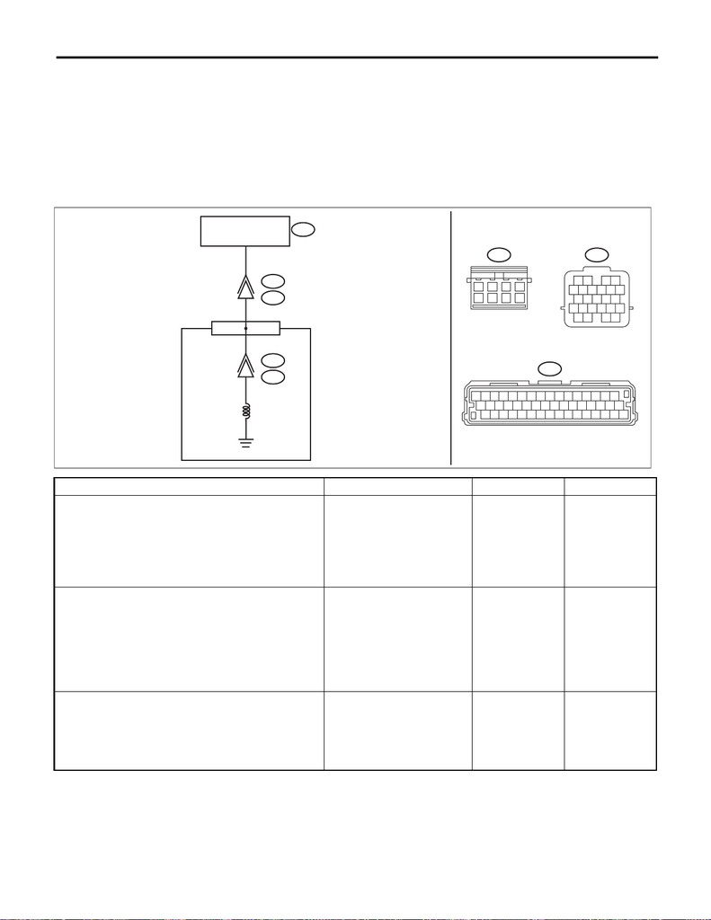

CVT(diag)-87

Diagnostic Procedure with Diagnostic Trouble Code (DTC)

CONTINUOUSLY VARIABLE TRANSMISSION (DIAGNOSTICS)

AG:DTC P0967 FORWARD & REVERSE LINEAR SOLENOID CIRCUIT (HIGH)

DTC DETECTING CONDITION:

• Immediately at fault recognition

• GENERAL DESCRIPTION <Ref. to GD(CVT)-41, DTC P0967 FORWARD & REVERSE LINEAR SOLE-

NOID CIRCUIT (HIGH), Diagnostic Trouble Code (DTC) Detecting Criteria.>

TROUBLE SYMPTOM:

Engine speed increases abruptly, and can not start.

WIRING DIAGRAM:

CVT control system <Ref. to WI-148, CVT Control System.>

Step Check Yes No

1 CHECK INPUT SIGNAL FOR TCM.

1) After driving with warm up condition, park

the vehicle while depressing the brake pedal at

“D” range.

2) Read the data of «F&R Linear Solenoid Set

Current» and «F&R Linear Solenoid Actual Cur-

rent» using Subaru Select Monitor.

Does the value of «F&R Linear

Solenoid Set Current» and

«F&R Linear Solenoid Actual

Current» almost correspond?

Check for poor

contact of connec-

tor.

Go to step 2.

2 CHECK HARNESS.

1) Turn the ignition switch to OFF.

2) Disconnect the TCM and transmission con-

nectors.

3) Measure the resistance between TCM con-

nector and transmission connectors.

Connector & terminal

(B54) No. 16 — (B11) No. 9:

Is the resistance less than 1 Ω? Go to step 3. Repair the open

circuit of harness.

3 CHECK HARNESS.

1) Turn the ignition switch to ON.

2) Measure the voltage between TCM connec-

tor and chassis ground.

Connector & terminal

(B54) No. 16 (+) — Chassis ground (–):

Is the voltage approx. 0 V? Go to step 4. Repair the short

circuit of harness.

T11

13

4

6

78

2

5

B54

10 11 12 13 14 15 16

17 18 19 20 21 22 23 24 25 26 27 28 29 30 31 32

33 34 35 36 37 38 39 40 41 42 43 44 45 46 47 48

B11

567

12 34

9

10 11 12

17 18 19 20

8

13 14 15 16

CVT00531

T11

T31

39

16

B11

T4

B54

TCM

CONTROL VALVE BODY

F & R

SOLENOID

[figure not shown]

CVT(diag)-88

Diagnostic Procedure with Diagnostic Trouble Code (DTC)

CONTINUOUSLY VARIABLE TRANSMISSION (DIAGNOSTICS)

4 CHECK F&R SOLENOID.

Measure the resistance between transmission

connector and transmission body.

Connector & terminal

(T4) No. 9 — Transmission body:

Is the resistance approx. 4 — 6

Ω? (when cold)

Check for poor

contact of connec-

tor, and if no fault is

found, replace the

TCM. <Ref. to

CVT(TR690)-126,

Transmission Con-

trol Module

(TCM).>

Go to step 5.

5 CHECK HARNESS INSIDE TRANSMISSION.

CAUTION:

Start work after ATF cools down.

1) Remove the transmission oil pan.

2) Check for the harness pinch, damage.

Is there any fault in the har-

ness?

Replace the trans-

mission harness.

Go to step 6.

6 CHECK HARNESS INSIDE TRANSMISSION.

1) Disconnect the control valve body connec-

tor.

2) Turn the ignition switch to ON.

3) Measure the voltage between transmission

connector and transmission body.

Connector & terminal

(T4) No. 9 (+) — Transmission body (–):

Is the voltage approx. 0 V? Replace the con-

trol valve body.

<Ref. to

CVT(TR690)-112,

Control Valve

Body.>

Replace the trans-

mission harness.

Step Check Yes No

CVT(diag)-89

Diagnostic Procedure with Diagnostic Trouble Code (DTC)

CONTINUOUSLY VARIABLE TRANSMISSION (DIAGNOSTICS)

AH:DTC P0970 TRANSFER SOLENOID CIRCUIT (LOW)

DTC DETECTING CONDITION:

• Immediately at fault recognition

• GENERAL DESCRIPTION <Ref. to GD(CVT)-42, DTC P0970 TRANSFER SOLENOID CIRCUIT (LOW),

Diagnostic Trouble Code (DTC) Detecting Criteria.>

TROUBLE SYMPTOM:

Drivability getting worse.

WIRING DIAGRAM:

CVT control system <Ref. to WI-148, CVT Control System.>

Step Check Yes No

1 CHECK HARNESS.

1) Turn the ignition switch to OFF.

2) Disconnect the TCM and transmission con-

nectors.

3) Measure the resistance between TCM con-

nector and chassis ground.

Connector & terminal

(B54) No. 48 — Chassis ground:

Is the resistance 1 MΩ or

more?

Go to step 2. Repair the short

circuit of harness.

2 CHECK AWD SOLENOID.

Measure the resistance between transmission

connector and transmission body.

Connector & terminal

(T4) No. 4 — Transmission body:

Is the resistance approx. 2 —

4.5 Ω? (when cold)

Check for poor

contact of connec-

tor, and if no fault is

found, replace the

TCM. <Ref. to

CVT(TR690)-126,

Transmission Con-

trol Module

(TCM).>

Go to step 3.

3 CHECK HARNESS INSIDE TRANSMISSION.

CAUTION:

Start work after ATF cools down.

1) Remove the transmission oil pan.

2) Check for the harness pinch, damage.

Is there any fault in the har-

ness?

Replace the trans-

mission harness.

Go to step 4.

T11

13

4

6

78

2

5

B54

10 11 12 13 14 15 16

17 18 19 20 21 22 23 24 25 26 27 28 29 30 31 32

33 34 35 36 37 38 39 40 41 42 43 44 45 46 47 48

B11

567

12 34

9

10 11 12

17 18 19 20

8

13 14 15 16

CVT00532

T11

T31

84

48

B11

T4

B54

TCM

CONTROL VALVE BODY

AWD

SOLENOID

CVT(diag)-90

Diagnostic Procedure with Diagnostic Trouble Code (DTC)

CONTINUOUSLY VARIABLE TRANSMISSION (DIAGNOSTICS)

4 CHECK HARNESS INSIDE TRANSMISSION.

1) Disconnect the control valve body connec-

tor.

2) Measure the resistance between transmis-

sion connector and transmission body.

Connector & terminal

(T4) No. 4 — Transmission body:

Is the resistance 1 MΩ or

more?

Replace the con-

trol valve body.

<Ref. to

CVT(TR690)-112,

Control Valve

Body.>

Replace the trans-

mission harness.

Step Check Yes No

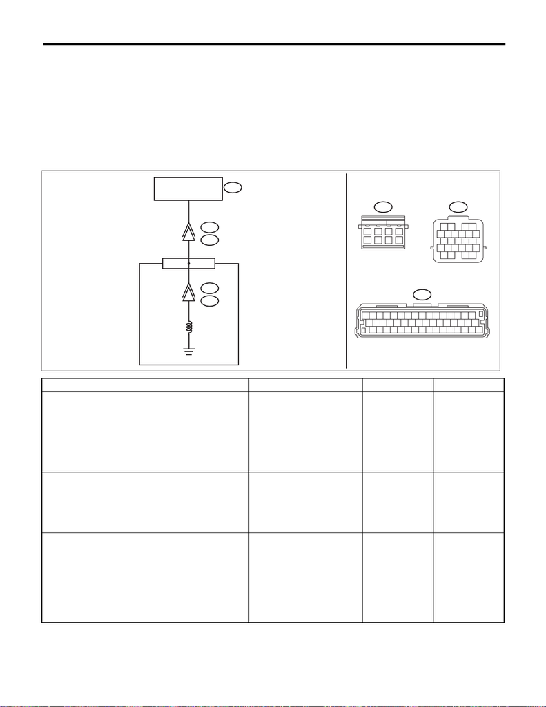

CVT(diag)-91

Diagnostic Procedure with Diagnostic Trouble Code (DTC)

CONTINUOUSLY VARIABLE TRANSMISSION (DIAGNOSTICS)

AI: DTC P0971 TRANSFER SOLENOID CIRCUIT (HIGH)

DTC DETECTING CONDITION:

• Immediately at fault recognition

• GENERAL DESCRIPTION <Ref. to GD(CVT)-43, DTC P0971 TRANSFER SOLENOID CIRCUIT (HIGH),

Diagnostic Trouble Code (DTC) Detecting Criteria.>

TROUBLE SYMPTOM:

• Tight corner braking phenomenon occurs.

• Drivability getting worse.

WIRING DIAGRAM:

CVT control system <Ref. to WI-148, CVT Control System.>

Step Check Yes No

1 CHECK HARNESS.

1) Turn the ignition switch to OFF.

2) Disconnect the TCM and transmission con-

nectors.

3) Measure the resistance between TCM con-

nector and transmission connectors.

Connector & terminal

(B54) No. 48 — (B11) No. 4:

Is the resistance less than 1 Ω? Go to step 2. Repair the open

circuit of harness.

2 CHECK HARNESS.

1) Turn the ignition switch to ON.

2) Measure the voltage between TCM connec-

tor and chassis ground.

Connector & terminal

(B54) No. 48 (+) — Chassis ground (–):

Is the voltage approx. 0 V? Go to step 3. Repair the short

circuit of harness.

3 CHECK AWD SOLENOID.

Measure the resistance between transmission

connector and transmission body.

Connector & terminal

(T4) No. 4 — Transmission body:

Is the resistance approx. 2 —

4.5 Ω? (when cold)

Check for poor

contact of connec-

tor, and if no fault is

found, replace the

TCM. <Ref. to

CVT(TR690)-126,

Transmission Con-

trol Module

(TCM).>

Go to step 4.

T11

13

4

6

78

2

5

B54

10 11 12 13 14 15 16

17 18 19 20 21 22 23 24 25 26 27 28 29 30 31 32

33 34 35 36 37 38 39 40 41 42 43 44 45 46 47 48

B11

567

12 34

9

10 11 12

17 18 19 20

8

13 14 15 16

CVT00532

T11

T31

84

48

B11

T4

B54

TCM

CONTROL VALVE BODY

AWD

SOLENOID

[figure not shown]

CVT(diag)-92

Diagnostic Procedure with Diagnostic Trouble Code (DTC)

CONTINUOUSLY VARIABLE TRANSMISSION (DIAGNOSTICS)

4 CHECK HARNESS INSIDE TRANSMISSION.

CAUTION:

Start work after ATF cools down.

1) Remove the transmission oil pan.

2) Check for the harness pinch, damage.

Is there any fault in the har-

ness?

Replace the trans-

mission harness.

Go to step 5.

5 CHECK HARNESS INSIDE TRANSMISSION.

1) Disconnect the control valve body connec-

tor.

2) Turn the ignition switch to ON.

3) Measure the voltage between transmission

connector and transmission body.

Connector & terminal

(T4) No. 4 (+) — Transmission body (–):

Is the voltage approx. 0 V? Replace the con-

trol valve body.

<Ref. to

CVT(TR690)-112,

Control Valve

Body.>

Replace the trans-

mission harness.

Step Check Yes No

CVT(diag)-93

Diagnostic Procedure with Diagnostic Trouble Code (DTC)

CONTINUOUSLY VARIABLE TRANSMISSION (DIAGNOSTICS)

AJ:DTC P0973 PRIMARY SOLENOID SYSTEM A CIRCUIT (LOW)

DTC DETECTING CONDITION:

• Immediately at fault recognition

• GENERAL DESCRIPTION <Ref. to GD(CVT)-44, DTC P0973 PRIMARY SOLENOID SYSTEM A CIR-

CUIT (LOW), Diagnostic Trouble Code (DTC) Detecting Criteria.>

TROUBLE SYMPTOM:

Gear is not changed. (No up-shift)

WIRING DIAGRAM:

CVT control system <Ref. to WI-148, CVT Control System.>

Step Check Yes No

1 CHECK HARNESS.

1) Turn the ignition switch to OFF.

2) Disconnect the TCM and transmission con-

nectors.

3) Measure the resistance between TCM con-

nector and chassis ground.

Connector & terminal

(B54) No. 47 — Chassis ground:

Is the resistance 1 MΩ or

more?

Go to step 2. Repair the short

circuit of harness.

2 CHECK PRIMARY UP SOLENOID.

Measure the resistance between transmission

connector and transmission body.

Connector & terminal

(T4) No. 6 — Transmission body:

Is the resistance approx. 10 —

13.5 Ω? (when cold)

Check for poor

contact of connec-

tor, and if no fault is

found, replace the

TCM. <Ref. to

CVT(TR690)-126,

Transmission Con-

trol Module

(TCM).>

Go to step 3.

3 CHECK HARNESS INSIDE TRANSMISSION.

CAUTION:

Start work after ATF cools down.

1) Remove the transmission oil pan.

2) Check for the harness pinch, damage.

Is there any fault in the har-

ness?

Replace the trans-

mission harness.

Go to step 4.

T11

13

4

6

78

2

5

B54

10 11 12 13 14 15 16

17 18 19 20 21 22 23 24 25 26 27 28 29 30 31 32

33 34 35 36 37 38 39 40 41 42 43 44 45 46 47 48

B11

567

12 34

9

10 11 12

17 18 19 20

8

13 14 15 16

CVT00533

T11

T31

76

47

B11

T4

B54

TCM

CONTROL VALVE BODY

PRIMARY UP

SOLENOID

CVT(diag)-94

Diagnostic Procedure with Diagnostic Trouble Code (DTC)

CONTINUOUSLY VARIABLE TRANSMISSION (DIAGNOSTICS)

4 CHECK HARNESS INSIDE TRANSMISSION.

1) Disconnect the control valve body connec-

tor.

2) Measure the resistance between transmis-

sion connector and transmission body.

Connector & terminal

(T4) No. 6 — Transmission body:

Is the resistance 1 MΩ or

more?

Replace the con-

trol valve body.

<Ref. to

CVT(TR690)-112,

Control Valve

Body.>

Replace the trans-

mission harness.

Step Check Yes No

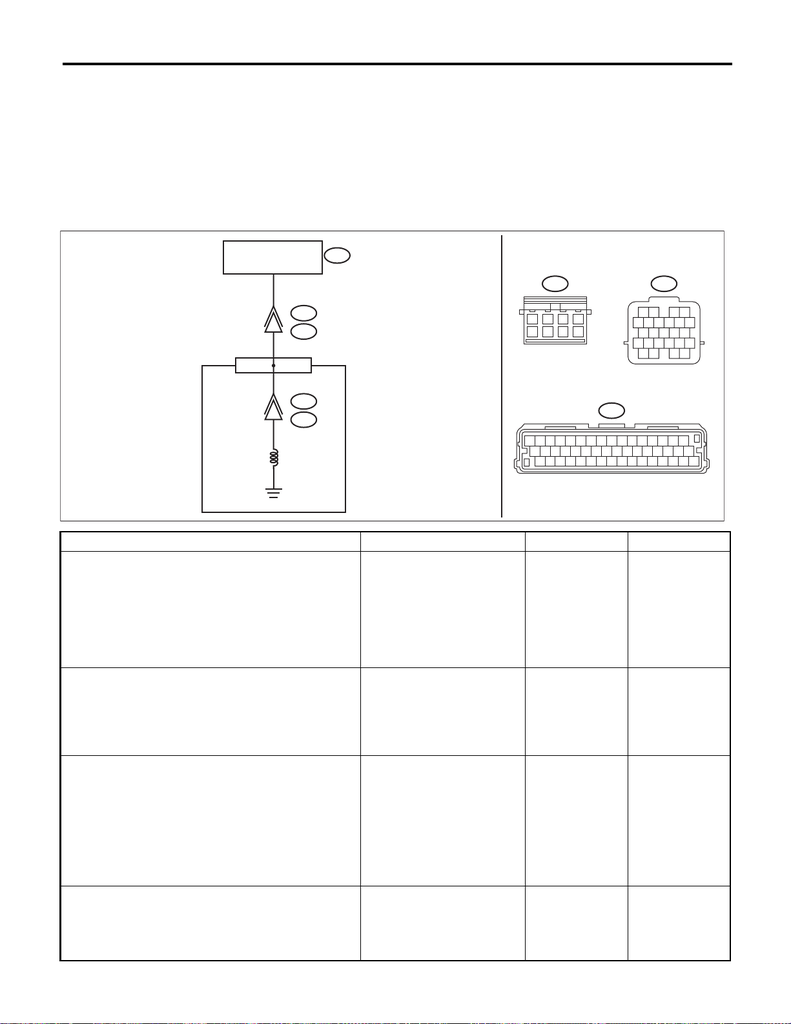

CVT(diag)-95

Diagnostic Procedure with Diagnostic Trouble Code (DTC)

CONTINUOUSLY VARIABLE TRANSMISSION (DIAGNOSTICS)

AK:DTC P0974 PRIMARY SOLENOID SYSTEM A CIRCUIT (HIGH)

DTC DETECTING CONDITION:

• Immediately at fault recognition

• GENERAL DESCRIPTION <Ref. to GD(CVT)-45, DTC P0974 PRIMARY SOLENOID SYSTEM A CIR-

CUIT (HIGH), Diagnostic Trouble Code (DTC) Detecting Criteria.>

TROUBLE SYMPTOM:

Gear is not changed. (No up-shift)

WIRING DIAGRAM:

CVT control system <Ref. to WI-148, CVT Control System.>

Step Check Yes No

1 CHECK HARNESS.

1) Turn the ignition switch to OFF.

2) Disconnect the TCM and transmission con-

nectors.

3) Measure the resistance between TCM con-

nector and transmission connectors.

Connector & terminal

(B54) No. 47 — (B11) No. 6:

Is the resistance less than 1 Ω? Go to step 2. Repair the open

circuit of harness.

2 CHECK HARNESS.

1) Turn the ignition switch to ON.

2) Measure the voltage between TCM connec-

tor and chassis ground.

Connector & terminal

(B54) No. 47 (+) — Chassis ground (–):

Is the voltage approx. 0 V? Go to step 3. Repair the short

circuit of harness.

3 CHECK PRIMARY UP SOLENOID.

Measure the resistance between transmission

connector and transmission body.

Connector & terminal

(T4) No. 6 — Transmission body:

Is the resistance approx. 10 —

13.5 Ω? (when cold)

Check for poor

contact of connec-

tor, and if no fault is

found, replace the

TCM. <Ref. to

CVT(TR690)-126,

Transmission Con-

trol Module

(TCM).>

Go to step 4.

4 CHECK HARNESS INSIDE TRANSMISSION.

CAUTION:

Start work after ATF cools down.

1) Remove the transmission oil pan.

2) Check for the harness pinch, damage.

Is there any fault in the har-

ness?

Replace the trans-

mission harness.

Go to step 5.

T11

13

4

6

78

2

5

B54

10 11 12 13 14 15 16

17 18 19 20 21 22 23 24 25 26 27 28 29 30 31 32

33 34 35 36 37 38 39 40 41 42 43 44 45 46 47 48

B11

567

12 34

9

10 11 12

17 18 19 20

8

13 14 15 16

CVT00533

T11

T31

76

47

B11

T4

B54

TCM

CONTROL VALVE BODY

PRIMARY UP

SOLENOID

[figure not shown]

CVT(diag)-96

Diagnostic Procedure with Diagnostic Trouble Code (DTC)

CONTINUOUSLY VARIABLE TRANSMISSION (DIAGNOSTICS)

5 CHECK HARNESS INSIDE TRANSMISSION.

1) Disconnect the control valve body connec-

tor.

2) Turn the ignition switch to ON.

3) Measure the voltage between transmission

connector and transmission body.

Connector & terminal

(T4) No. 6 (+) — Transmission body (–):

Is the voltage approx. 0 V? Replace the con-

trol valve body.

<Ref. to

CVT(TR690)-112,

Control Valve

Body.>

Replace the trans-

mission harness.

Step Check Yes No

CVT(diag)-97

Diagnostic Procedure with Diagnostic Trouble Code (DTC)

CONTINUOUSLY VARIABLE TRANSMISSION (DIAGNOSTICS)

AL:DTC P0976 PRIMARY SOLENOID SYSTEM B CIRCUIT (LOW)

DTC DETECTING CONDITION:

• Immediately at fault recognition

• GENERAL DESCRIPTION <Ref. to GD(CVT)-46, DTC P0976 PRIMARY SOLENOID SYSTEM B CIR-

CUIT (LOW), Diagnostic Trouble Code (DTC) Detecting Criteria.>

TROUBLE SYMPTOM:

Gear is not changed. (No down-shift)

WIRING DIAGRAM:

CVT control system <Ref. to WI-148, CVT Control System.>

Step Check Yes No

1 CHECK HARNESS.

1) Turn the ignition switch to OFF.

2) Disconnect the TCM and transmission con-

nectors.

3) Measure the resistance between TCM con-

nector and chassis ground.

Connector & terminal

(B54) No. 30 — Chassis ground:

Is the resistance 1 MΩ or

more?

Go to step 2. Repair the short

circuit of harness.

2 CHECK PRIMARY DOWN SOLENOID.

Measure the resistance between transmission

connector and transmission body.

Connector & terminal

(T4) No. 1 — Transmission body:

Is the resistance approx. 10 —

13.5 Ω? (when cold)

Check for poor

contact of connec-

tor, and if no fault is

found, replace the

TCM. <Ref. to

CVT(TR690)-126,

Transmission Con-

trol Module

(TCM).>

Go to step 3.

3 CHECK HARNESS INSIDE TRANSMISSION.

CAUTION:

Start work after ATF cools down.

1) Remove the transmission oil pan.

2) Check for the harness pinch, damage.

Is there any fault in the har-

ness?

Replace the trans-

mission harness.

Go to step 4.

T11

13

4

6

78

2

5

B54

10 11 12 13 14 15 16

17 18 19 20 21 22 23 24 25 26 27 28 29 30 31 32

33 34 35 36 37 38 39 40 41 42 43 44 45 46 47 48

B11

567

12 34

9

10 11 12

17 18 19 20

8

13 14 15 16

CVT00534

T11

T31

61

30

B11

T4

B54

TCM

CONTROL VALVE BODY

PRIMARY DOWN

SOLENOID

CVT(diag)-98

Diagnostic Procedure with Diagnostic Trouble Code (DTC)

CONTINUOUSLY VARIABLE TRANSMISSION (DIAGNOSTICS)

4 CHECK HARNESS INSIDE TRANSMISSION.

1) Disconnect the control valve body connec-

tor.

2) Measure the resistance between transmis-

sion connector and transmission body.

Connector & terminal

(T4) No. 1 — Transmission body:

Is the resistance 1 MΩ or

more?

Replace the con-

trol valve body.

<Ref. to

CVT(TR690)-112,

Control Valve

Body.>

Replace the trans-

mission harness.

Step Check Yes No

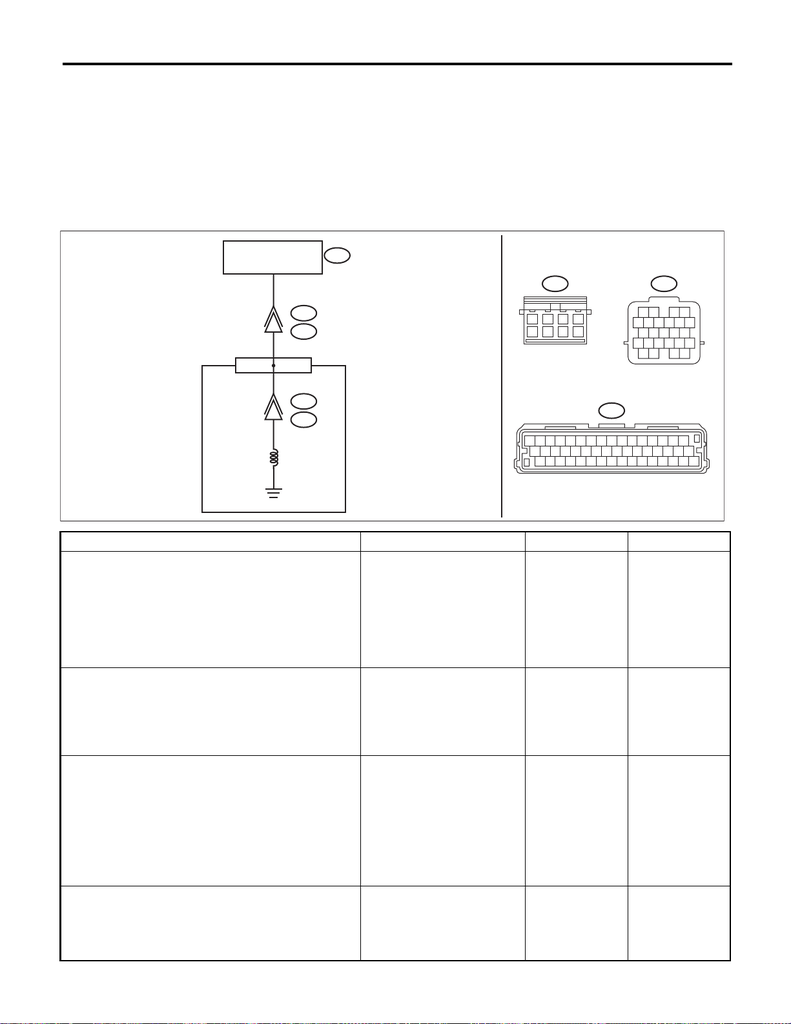

CVT(diag)-99

Diagnostic Procedure with Diagnostic Trouble Code (DTC)

CONTINUOUSLY VARIABLE TRANSMISSION (DIAGNOSTICS)

AM:DTC P0977 PRIMARY SOLENOID SYSTEM B CIRCUIT (HIGH)

DTC DETECTING CONDITION:

• Immediately at fault recognition

• GENERAL DESCRIPTION <Ref. to GD(CVT)-47, DTC P0977 PRIMARY SOLENOID SYSTEM B CIR-

CUIT (HIGH), Diagnostic Trouble Code (DTC) Detecting Criteria.>

TROUBLE SYMPTOM:

Gear is not changed. (No down-shift)

WIRING DIAGRAM:

CVT control system <Ref. to WI-148, CVT Control System.>

Step Check Yes No

1 CHECK HARNESS.

1) Turn the ignition switch to OFF.

2) Disconnect the TCM and transmission con-

nectors.

3) Measure the resistance between TCM con-

nector and transmission connectors.

Connector & terminal

(B54) No. 30 — (B11) No. 1:

Is the resistance less than 1 Ω? Go to step 2. Repair the open

circuit of harness.

2 CHECK HARNESS.

1) Turn the ignition switch to ON.

2) Measure the voltage between TCM connec-

tor and chassis ground.

Connector & terminal

(B54) No. 30 (+) — Chassis ground (–):

Is the voltage approx. 0 V? Go to step 3. Repair the short

circuit of harness.

3 CHECK PRIMARY DOWN SOLENOID.

Measure the resistance between transmission

connector and transmission body.

Connector & terminal

(T4) No. 1 — Transmission body:

Is the resistance approx. 10 —

13.5 Ω? (when cold)

Check for poor

contact of connec-

tor, and if no fault is

found, replace the

TCM. <Ref. to

CVT(TR690)-126,

Transmission Con-

trol Module

(TCM).>

Go to step 4.

4 CHECK HARNESS INSIDE TRANSMISSION.

CAUTION:

Start work after ATF cools down.

1) Remove the transmission oil pan.

2) Check for the harness pinch, damage.

Is there any fault in the har-

ness?

Replace the trans-

mission harness.

Go to step 5.

T11

13

4

6

78

2

5

B54

10 11 12 13 14 15 16

17 18 19 20 21 22 23 24 25 26 27 28 29 30 31 32

33 34 35 36 37 38 39 40 41 42 43 44 45 46 47 48

B11

567

12 34

9

10 11 12

17 18 19 20

8

13 14 15 16

CVT00534

T11

T31

61

30

B11

T4

B54

TCM

CONTROL VALVE BODY

PRIMARY DOWN

SOLENOID

[figure not shown]

CVT(diag)-100

Diagnostic Procedure with Diagnostic Trouble Code (DTC)

CONTINUOUSLY VARIABLE TRANSMISSION (DIAGNOSTICS)

5 CHECK HARNESS INSIDE TRANSMISSION.

1) Disconnect the control valve body connec-

tor.

2) Turn the ignition switch to ON.

3) Measure the voltage between transmission

connector and transmission body.

Connector & terminal

(T4) No. 1 (+) — Transmission body (–):

Is the voltage approx. 0 V? Replace the con-

trol valve body.

<Ref. to

CVT(TR690)-112,

Control Valve

Body.>

Replace the trans-

mission harness.

Step Check Yes No

[figure not shown]

CVT(diag)-101

Diagnostic Procedure with Diagnostic Trouble Code (DTC)

CONTINUOUSLY VARIABLE TRANSMISSION (DIAGNOSTICS)

AN:DTC P160A RANDOM ACCESS MEMORY (RAM) ERROR

DTC DETECTING CONDITION:

• Detected when two consecutive driving cycles with fault occur.

• GENERAL DESCRIPTION <Ref. to GD(CVT)-48, DTC P160A RANDOM ACCESS MEMORY (RAM) ER-

ROR, Diagnostic Trouble Code (DTC) Detecting Criteria.>

TROUBLE SYMPTOM:

TCM RAM malfunction

Step Check Yes No

1 CHECK DTC.

1) Perform the Clear Memory Mode using the

Subaru Select Monitor. <Ref. to CVT(diag)-17,

Clear Memory Mode.>

2) Read the DTC.

Is DTC P160A displayed? Replace the TCM.

<Ref. to

CVT(TR690)-126,

Transmission Con-

trol Module

(TCM).>

Current condition

is normal. Check

for interference

from noise, etc.

[figure not shown]

CVT(diag)-102

Diagnostic Procedure with Diagnostic Trouble Code (DTC)

CONTINUOUSLY VARIABLE TRANSMISSION (DIAGNOSTICS)

AO:DTC P1706 AT VEHICLE SPEED SENSOR CIRCUIT MALFUNCTION (REAR

WHEEL)

DTC DETECTING CONDITION:

• Immediately at fault recognition

• GENERAL DESCRIPTION <Ref. to GD(CVT)-49, DTC P1706 AT VEHICLE SPEED SENSOR CIRCUIT

MALFUNCTION (REAR WHEEL), Diagnostic Trouble Code (DTC) Detecting Criteria.>

TROUBLE SYMPTOM:

AWD does not function.

WIRING DIAGRAM:

CVT control system <Ref. to WI-148, CVT Control System.>

Step Check Yes No

1 CHECK FUSE.

1) Turn the ignition switch to OFF.

2) Remove the fuse (7.5 A) from the fuse

holder.

Is the fuse OK? Go to step 2. Replace the fuse. If

the fuse blows out

easily, repair the

short circuit of har-

ness.

2 CHECK HARNESS.

1) Turn the ignition switch to OFF.

2) Disconnect the TCM and transmission con-

nectors.

3) Measure the resistance between TCM con-

nector and transmission connectors.

Connector & terminal

(B54) No. 11 — (B11) No. 8:

(B54) No. 26 — (B11) No. 20:

(B54) No. 42 — (B11) No. 13:

(B550) No. 20 — (B11) No. 11:

Is the resistance less than 1 Ω? Go to step 3. Repair the open

circuit of harness.

13

42

B550

91

2

232221 262524201918

4

13

12

17

3

16

6

15

587

14

10 11

B220

10 11

12

13

14 15

16

18

19 21 22

20

17

24

5

3

17

9

8

6

32 33

34

35

28262423

25

27

29

30

31

36 37

38

40

41 43 44

42

39

16

31 32

B54

123456789

10 11 12 13 14 15

17 18 19 20 21 22 23 24 25 26 27 28 29 30

B11

567

12 34

9

10 11 12

17 18 19 20

8

13 14 15 16

123

AT7

14

15

B220

B11

T4

20

8

11

11

26

2

1

3

AT7

B54

6

20

B550

CVT00526

TCM

MB-26

M/B FUSE NO. 12

(B)

FUSE HOLDER

7.5A

REAR WHEEL SPEED

SENSOR

SELF SHUT RELAY

RELAY HOLDER

FUSE HOLDER

[figure not shown]

CVT(diag)-103

Diagnostic Procedure with Diagnostic Trouble Code (DTC)

CONTINUOUSLY VARIABLE TRANSMISSION (DIAGNOSTICS)

3 CHECK HARNESS.

Measure the resistance between TCM connec-

tor and chassis ground.

Connector & terminal

(B54) No. 11 — Chassis ground:

Is the resistance 1 MΩ or

more?

Go to step 4. Repair the short

circuit of harness.

4 CHECK TRANSMISSION HARNESS.

1) Install the fuse.

2) Connect the TCM connector.

3) Turn the ignition switch to ON.

4) Measure the voltage between transmission

connector terminals.

Connector & terminal

(B11) No. 11 (+) — Chassis ground (–):

Is the voltage approx. 10 — 13

V?

Go to step 5. Repair the poor

contact of harness

or connector.

5 CHECK INPUT SIGNAL FOR TCM.

1) Turn the ignition switch to OFF.

2) Connect the transmission connector.

3) Lift up the vehicle.

4) Start the engine.

5) Slowly increase the speed to 30 km/h (19

MPH).

6) Read the data of «Rear Wheel Speed»

using Subaru Select Monitor.

Does the value of «Rear Wheel

Speed» change according to

the engine speed?

Current condition

is normal. Repair

the poor contacts

of harnesses of

rear wheel speed

sensor and trans-

mission connector.

Go to step 6.

6 CHECK TRANSMISSION HARNESS.

1) Turn the ignition switch to OFF.

2) Disconnect the transmission connector.

3) Lift up the vehicle.

4) Disconnect the rear wheel speed sensor

connector.

5) Measure the resistance between transmis-

sion connector and rear wheel speed sensor

connector.

Connector & terminal

(T4) No. 13 — (AT7) No. 1:

(T4) No. 20 — (AT7) No. 1:

(T4) No. 8 — (AT7) No. 2:

(T4) No. 11 — (AT7) No. 3:

Is the resistance less than 1 Ω? Replace the rear

wheel speed sen-

sor. <Ref. to

CVT(TR690)-107,

Rear Wheel Speed

Sensor.>

Replace the trans-

mission harness.

Step Check Yes No

[figure not shown]

CVT(diag)-104

Diagnostic Procedure with Diagnostic Trouble Code (DTC)

CONTINUOUSLY VARIABLE TRANSMISSION (DIAGNOSTICS)

AP:DTC P170B OUTPUT SPEED SENSOR CIRCUIT RANGE/PERFORMANCE

REAR

DTC DETECTING CONDITION:

• Immediately at fault recognition

• GENERAL DESCRIPTION <Ref. to GD(CVT)-50, DTC P170B OUTPUT SPEED SENSOR CIRCUIT

RANGE/PERFORMANCE REAR, Diagnostic Trouble Code (DTC) Detecting Criteria.>

TROUBLE SYMPTOM:

• Acceleration is poor during standing start.

• No lock-up occurs.

• The engine stalls when the vehicle is stopped.

• Shift control malfunction

Step Check Yes No

1 CHECK DTC.

Read the DTC using Subaru Select Monitor.

Besides DTC P170B, is any of

the DTCs P0720, P1706 and

P0500 displayed?

Perform the diag-

nosis according to

DTCs other than

P170B.

Perform the diag-

nosis according to

DTC P1706. <Ref.

to CVT(diag)-102,

DTC P1706 AT

VEHICLE SPEED

SENSOR CIR-

CUIT MALFUNC-

TION (REAR

WHEEL), Diagnos-

tic Procedure with

Diagnostic Trouble

Code (DTC).>

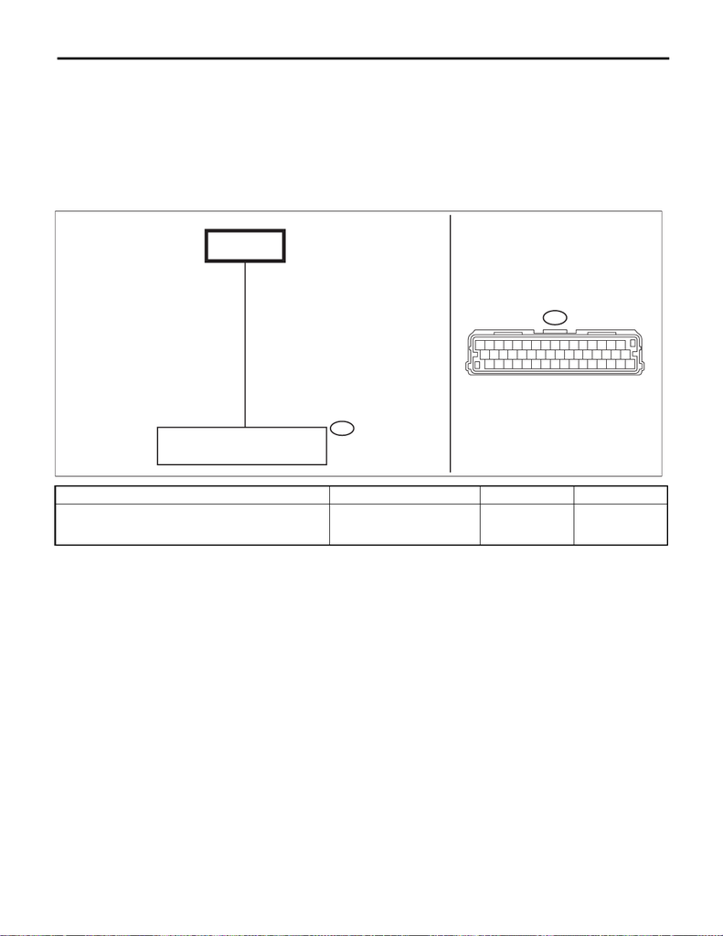

CVT(diag)-105

Diagnostic Procedure with Diagnostic Trouble Code (DTC)

CONTINUOUSLY VARIABLE TRANSMISSION (DIAGNOSTICS)

AQ:DTC P2530 IGNITION SWITCH RUN POSITION CIRCUIT

DTC DETECTING CONDITION:

• Immediately at fault recognition

• GENERAL DESCRIPTION <Ref. to GD(CVT)-51, DTC P2530 IGNITION SWITCH RUN POSITION CIR-

CUIT, Diagnostic Trouble Code (DTC) Detecting Criteria.>

TROUBLE SYMPTOM:

Faulty TCM operation

WIRING DIAGRAM:

CVT control system <Ref. to WI-148, CVT Control System.>

Step Check Yes No

1 CHECK CONNECTOR.

Check the installing condition of TCM connec-

tor.

Is the TCM connector installed

properly?

Go to step 2. Install the TCM

connector.

16

31 32

B54

123456789

10 11 12 13 14 15

17 18 19 20 21 22 23 24 25 26 27 28 29 30

B54

41

CVT00544

TCM

FB-38

F/B FUSE NO. 12

(IG)

[figure not shown]

CVT(diag)-106

Diagnostic Procedure with Diagnostic Trouble Code (DTC)

CONTINUOUSLY VARIABLE TRANSMISSION (DIAGNOSTICS)

2 CHECK INPUT VOLTAGE OF TCM.

1) Turn the ignition switch to ON.

2) Measure the voltage between TCM connec-

tor and chassis ground. (While wiggling the har-

ness)

Connector & terminal

(B54) No. 41 (+) — Chassis ground (–):

Is the voltage 8 V or more? Even if DTC is

detected, the cir-

cuit has returned to

a normal condition

at this time. Repro-

duce the failure,

and then perform

the diagnosis

again.

NOTE:

In this case, the fol-

lowing items may

be the cause of

fault.

• Open circuit or

short circuit to

ground of harness

between TCM con-

nector and ignition

switch connector

(IG relay 1 connec-

tor for model with

push button start)

• Poor contact of

ignition switch con-

nector (IG relay 1

connector for

model with push

button start)

• Poor contact of

ignition switch (IG

relay 1 for model

with push button

start)

Repair the harness

and connector.

NOTE:

In this case, repair

the following item:

• Open circuit or

short circuit to

ground of harness

between TCM con-

nector and ignition

switch connector

(IG relay 1 connec-

tor for model with

push button start)

• Poor contact of

ignition switch con-

nector (IG relay 1

connector for

model with push

button start)

• Poor contact of

ignition switch (IG

relay 1 for model

with push button

start)

Step Check Yes No

[figure not shown]

CVT(diag)-107

Diagnostic Procedure with Diagnostic Trouble Code (DTC)

CONTINUOUSLY VARIABLE TRANSMISSION (DIAGNOSTICS)

AR:DTC P2746 PRIMARY PULLEY REVOLUTION SPEED SENSOR CIRCUIT

DTC DETECTING CONDITION:

• Immediately at fault recognition

• GENERAL DESCRIPTION <Ref. to GD(CVT)-52, DTC P2746 PRIMARY PULLEY REVOLUTION SPEED

SENSOR CIRCUIT, Diagnostic Trouble Code (DTC) Detecting Criteria.>

TROUBLE SYMPTOM:

• Standing start problems

• Shock occurs when engaging the lockup clutch.

• Shock occurs when selecting shift position.

Step Check Yes No

1 CHECK DTC.

Read the DTC using Subaru Select Monitor.

Besides DTC P2746, is any of

the DTCs P2747, U0100 and

U0401 displayed?

Perform the diag-

nosis according to

DTCs other than

P2746.

Perform the diag-

nosis according to

DTC P2747. <Ref.

to CVT(diag)-108,

DTC P2747

INTERMEDIATE

SHAFT SPEED

SENSOR "B" CIR-

CUIT NO SIGNAL,

Diagnostic Proce-

dure with Diagnos-

tic Trouble Code

(DTC).>

[figure not shown]

CVT(diag)-108

Diagnostic Procedure with Diagnostic Trouble Code (DTC)

CONTINUOUSLY VARIABLE TRANSMISSION (DIAGNOSTICS)

AS:DTC P2747 INTERMEDIATE SHAFT SPEED SENSOR "B" CIRCUIT NO SIG-

NAL

DTC DETECTING CONDITION:

• Immediately at fault recognition

• GENERAL DESCRIPTION <Ref. to GD(CVT)-53, DTC P2747 INTERMEDIATE SHAFT SPEED SENSOR

"B" CIRCUIT NO SIGNAL, Diagnostic Trouble Code (DTC) Detecting Criteria.>

TROUBLE SYMPTOM:

• Standing start problems

• Shock occurs when engaging the lockup clutch.

• Shock occurs when selecting shift position.

WIRING DIAGRAM:

CVT control system <Ref. to WI-148, CVT Control System.>

Step Check Yes No

1 CHECK FUSE.

1) Turn the ignition switch to OFF.

2) Remove the fuse (7.5 A) from the fuse

holder.

Is the fuse OK? Go to step 2. Replace the fuse. If

the fuse blows out

easily, repair the

short circuit of har-

ness.

2 CHECK HARNESS.

1) Turn the ignition switch to OFF.

2) Disconnect the TCM and transmission con-

nectors.

3) Measure the resistance between TCM con-

nector and transmission connectors.

Connector & terminal

(B54) No. 26 — (B11) No. 20:

(B54) No. 42 — (B11) No. 13:

(B54) No. 14 — (B12) No. 6:

(B54) No. 42 — (B12) No. 7:

(B550) No. 20 — (B12) No. 5:

Is the resistance less than 1 Ω? Go to step 3. Repair the open

circuit of harness.

B11

567

12 34

9

10 11 12

17 18 19 20

8

13 14 15 16

B11

T4

26

13

20

B12

5

9

1

6

10

2

7

11

3

8

12

4

AT1

2

1

3

B550

91

2

4

13

12

17

3

16

6

15

587

14

10 11

B220

10 11

12

13

14 15

16

18

19 21 22

20

17

24

5

3

17

9

8

6

32 33

34

35

28262423

25

27

29

30

31

36 37

38

40

41 43 44

42

39

16

31 32

B54

123456789

10 11 12 13 14 15

14

15

B220

B12

T3

7

6

5

14

42

2

3

1

AT1

B54

6

20

B550

CVT00524

TCM

MB-26

M/B FUSE NO. 12

(B)

FUSE HOLDER

7.5A

PRIMARY SPEED

SENSOR

SELF SHUT RELAY

RELAY HOLDER

FUSE HOLDER

[figure not shown]

CVT(diag)-109

Diagnostic Procedure with Diagnostic Trouble Code (DTC)

CONTINUOUSLY VARIABLE TRANSMISSION (DIAGNOSTICS)

3 CHECK HARNESS.

Measure the resistance between TCM connec-

tor and chassis ground.

Connector & terminal

(B54) No. 14 — Chassis ground:

Is the resistance 1 MΩ or

more?

Go to step 4. Repair the short

circuit of harness.

4 CHECK TRANSMISSION HARNESS.

1) Install the fuse.

2) Connect the TCM connector.

3) Turn the ignition switch to ON.

4) Measure the voltage between transmission

connector terminals.

Connector & terminal

(B12) No. 5 (+) — Chassis ground (–):

Is the voltage 10 — 13 V? Go to step 5. Repair the open

circuit of harness

or poor contact of

connector.

5 CHECK INPUT SIGNAL FOR TCM.

1) Turn the ignition switch to OFF.

2) Connect the transmission connector.

3) Lift up the vehicle.

4) Start the engine.

5) Set the select lever to “D” range.

6) Read the data of «Primary Pulley Speed»

using Subaru Select Monitor.

Does the value of «Primary Pul-

ley Speed» change according

to those of «Turbine Revolution

Speed»?

Current condition

is normal. Repair

the poor contacts

of harnesses of pri-

mary speed sensor

and transmission

connector.

Go to step 6.

6 CHECK TRANSMISSION HARNESS.

1) Turn the ignition switch to OFF.

2) Disconnect the transmission connector.

3) Disconnect the primary speed sensor con-

nector.

4) Measure the resistance between transmis-

sion connector and primary speed sensor con-

nector.

Connector & terminal

(T3) No. 5 — (AT1) No. 1:

(T3) No. 6 — (AT1) No. 2:

(T3) No. 7 — (AT1) No. 3:

Is the resistance less than 1 Ω? Replace the pri-

mary speed sen-

sor. <Ref. to

CVT(TR690)-102,

Primary Speed

Sensor.>

Replace the trans-

mission harness.

Step Check Yes No

[figure not shown]

CVT(diag)-110

Diagnostic Procedure with Diagnostic Trouble Code (DTC)

CONTINUOUSLY VARIABLE TRANSMISSION (DIAGNOSTICS)

AT:DTC P2750 SEC. PULLEY REVOLUTION SPEED SENSOR CIRCUIT

DTC DETECTING CONDITION:

• Immediately at fault recognition

• GENERAL DESCRIPTION <Ref. to GD(CVT)-54, DTC P2750 SEC. PULLEY REVOLUTION SPEED

SENSOR CIRCUIT, Diagnostic Trouble Code (DTC) Detecting Criteria.>

TROUBLE SYMPTOM:

• Shifting shock is felt.

• Acceleration is poor during standing start.

• Shift control malfunction

Step Check Yes No

1 CHECK DTC.

Read the DTC using Subaru Select Monitor.

Besides DTC P2750, is DTC

P2747 or P2751 displayed?

Perform the diag-

nosis according to

DTCs other than

P2750.

Perform the diag-

nosis according to

DTC P2751. <Ref.

to CVT(diag)-111,

DTC P2751

INTERMEDIATE

SHAFT SPEED

SENSOR "C" CIR-

CUIT NO SIGNAL,

Diagnostic Proce-

dure with Diagnos-

tic Trouble Code

(DTC).>

[figure not shown]

CVT(diag)-111

Diagnostic Procedure with Diagnostic Trouble Code (DTC)

CONTINUOUSLY VARIABLE TRANSMISSION (DIAGNOSTICS)

AU:DTC P2751 INTERMEDIATE SHAFT SPEED SENSOR "C" CIRCUIT NO SIG-

NAL

DTC DETECTING CONDITION:

• Immediately at fault recognition

• GENERAL DESCRIPTION <Ref. to GD(CVT)-55, DTC P2751 INTERMEDIATE SHAFT SPEED SENSOR

"C" CIRCUIT NO SIGNAL, Diagnostic Trouble Code (DTC) Detecting Criteria.>

TROUBLE SYMPTOM:

• Shifting shock is felt.

• Acceleration is poor during standing start.

• Shift control malfunction

WIRING DIAGRAM:

CVT control system <Ref. to WI-148, CVT Control System.>

Step Check Yes No

1 CHECK FUSE.

1) Turn the ignition switch to OFF.

2) Remove the fuse (7.5 A) from the fuse

holder.

Is the fuse OK? Go to step 2. Replace the fuse. If

the fuse blows out

easily, repair the

short circuit of har-

ness.

2 CHECK HARNESS.

1) Turn the ignition switch to OFF.

2) Disconnect the TCM and transmission con-

nectors.

3) Measure the resistance between TCM con-

nector and transmission connectors.

Connector & terminal

(B54) No. 13 — (B11) No. 10:

(B54) No. 26 — (B11) No. 20:

(B54) No. 42 — (B11) No. 13:

(B550) No. 20 — (B11) No. 11:

Is the resistance less than 1 Ω? Go to step 3. Repair the open

circuit of harness.

42

13

B550

91

2

4

13

12

17

3

16

6

15

587

14

10 11

B220

10 11

12

13

14 15

16

18

19 21 22

20

17

24

5

3

17

9

8

6

32 33

34

35

28262423

25

27

29

30

31

36 37

38

40

41 43 44

42

39

16

31 32

B54

123456789

10 11 12 13 14 15

B11

567

12 34

9

10 11 12

17 18 19 20

8

13 14 15 16

123

AT4

14

15

B220

B11

T4

20

10

11

13

26

2

1

3

AT4

B54

6

20

B550

CVT00523

TCM

MB-26

M/B FUSE NO. 12

(B)

FUSE HOLDER

7.5A

SECONDARY SPEED

SENSOR

SELF SHUT RELAY

RELAY HOLDER

FUSE HOLDER

[figure not shown]

CVT(diag)-112

Diagnostic Procedure with Diagnostic Trouble Code (DTC)

CONTINUOUSLY VARIABLE TRANSMISSION (DIAGNOSTICS)

3 CHECK HARNESS.

Measure the resistance between TCM connec-

tor and chassis ground.

Connector & terminal

(B54) No. 13 — Chassis ground:

Is the resistance 1 MΩ or

more?

Go to step 4. Repair the short

circuit of harness.

4 CHECK TRANSMISSION HARNESS.

1) Install the fuse.

2) Connect the TCM connector.

3) Turn the ignition switch to ON.

4) Measure the voltage between transmission

connector terminals.

Connector & terminal

(B11) No. 11 (+) — Chassis ground (–):

Is the voltage 10 — 13 V? Go to step 5. Repair the open

circuit of harness

or poor contact of

connector.

5 CHECK INPUT SIGNAL FOR TCM.

1) Turn the ignition switch to OFF.

2) Connect the transmission connector.

3) Lift up the vehicle.

4) Start the engine.

5) Set the select lever to “D” range.

6) Read the data of «Secondary Pulley

Speed» using Subaru Select Monitor.

Does the value of «Secondary

Pulley Speed» change accord-

ing to those of «Front Wheel

Speed»?

Current condition

is normal. Repair

the poor contacts

of harnesses of

secondary speed

sensor and trans-

mission connector.

Go to step 6.

6 CHECK TRANSMISSION HARNESS.

1) Turn the ignition switch to OFF.

2) Disconnect the transmission connector.

3) Disconnect the secondary speed sensor

connector.

4) Measure the resistance between transmis-

sion connector and secondary speed sensor

connector.

Connector & terminal

(T4) No. 10 — (AT4) No. 2:

(T4) No. 11 — (AT4) No. 3:

(T4) No. 13 — (AT4) No. 1:

(T4) No. 20 — (AT4) No. 1:

Is the resistance less than 1 Ω? Replace the sec-

ondary speed sen-

sor. <Ref. to

CVT(TR690)-99,

Secondary Speed

Sensor.>

Replace the trans-

mission harness.

Step Check Yes No

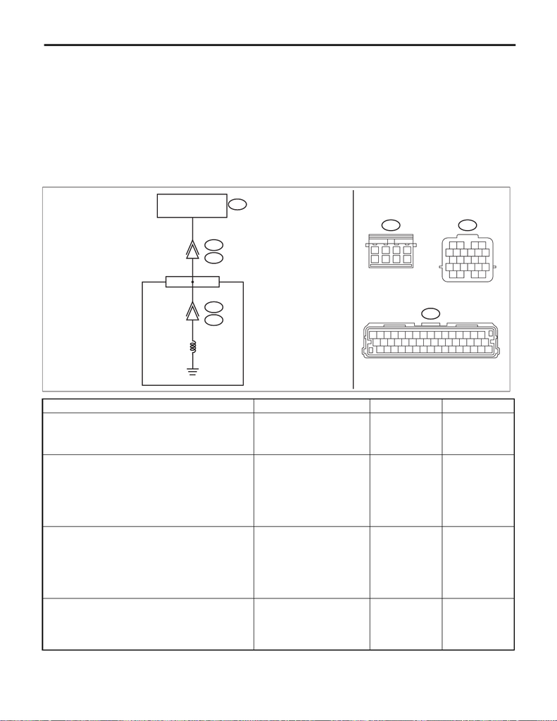

CVT(diag)-113

Diagnostic Procedure with Diagnostic Trouble Code (DTC)

CONTINUOUSLY VARIABLE TRANSMISSION (DIAGNOSTICS)

AV:DTC P2757 TORQUE CONVERTER CLUTCH PRESSURE CONTROL SOLE-

NOID CONTROL CIRCUIT PERFORMANCE/STUCK OFF

DTC DETECTING CONDITION:

• Detected when two consecutive driving cycles with fault occur.

• GENERAL DESCRIPTION <Ref. to GD(CVT)-56, DTC P2757 TORQUE CONVERTER CLUTCH PRES-

SURE CONTROL SOLENOID CONTROL CIRCUIT PERFORMANCE/STUCK OFF, Diagnostic Trouble

Code (DTC) Detecting Criteria.>

TROUBLE SYMPTOM:

No lock-up occurs.

WIRING DIAGRAM:

CVT control system <Ref. to WI-148, CVT Control System.>

Step Check Yes No

1 CHECK DTC.

Read the DTC using Subaru Select Monitor.

Besides DTC P2757, is any of

the DTCs P2747, P2763,

P2764, U0100 and U0401 dis-

played?

Perform the diag-

nosis according to

DTCs other than

P2757.

Go to step 2.

2 CHECK LOCK-UP DUTY SOLENOID (SYS-

TEM OPERATION CHECK MODE).

1) Turn the ignition switch to ON.

2) Using the Subaru Select Monitor, perform

forced operation of the lock-up duty solenoid.

<Ref. to CVT(diag)-22, System Operation

Check Mode.>

Does the indication of 0 → 50%

appear repeatedly during

forced operation, and does

operating sound emit during

indicating 50%?

Go to step 5. Go to step 3.

3 CHECK LOCK-UP DUTY SOLENOID.

1) Turn the ignition switch to OFF.

2) Disconnect the transmission connector.

3) Measure the resistance between transmis-

sion connector and transmission body.

Connector & terminal

(T4) No. 2 — Transmission body:

Is the resistance approx. 10 —

13.5 Ω? (when cold)

Go to step 7. Go to step 4.

4 CHECK HARNESS.

Check the continuity of transmission harness.

Is the harness normal? (Is it

free from defects such as open

circuit, power supply-output

short or GND-output short cir-

cuit, or poor contact?)

Go to step 7. Repair the har-

ness.

T11

13

4

6

78

2

5

B54

123456789

10 11 12 13 14 15 16

33 34 35 36 37 38 39 40 41 42 43 44 45 46 47 48

B11

567

12 34

9

10 11 12

17 18 19 20

8

13 14 15 16

CVT00522

T11

T31

22

15

B11

T4

B54

TCM

CONTROL VALVE BODY

LOCK-UP DUTY

SOLENOID

[figure not shown]

CVT(diag)-114

Diagnostic Procedure with Diagnostic Trouble Code (DTC)

CONTINUOUSLY VARIABLE TRANSMISSION (DIAGNOSTICS)

5 CHECK TRANSMISSION FLUID.

1) Connect the transmission connector.

2) Check the amount of ATF. <Ref. to

CVT(TR690)-36, ADJUSTMENT, CVTF.>

Is the ATF amount correct? Go to step 6. Adjust the amount

of ATF. <Ref. to

CVT(TR690)-36,

ADJUSTMENT,

CVTF.>

6 CHECK TRANSMISSION FLUID.

Check the condition of ATF. <Ref. to

CVT(TR690)-40, CONDITION CHECK, CVTF.>

Is the ATF OK? Go to step 7. Check according to

the “Corrective

action” of ATF

(CVTF) “CONDI-

TION CHECK”.

<Ref. to

CVT(TR690)-40,

CONDITION

CHECK, CVTF.>

7 CHECK INPUT SIGNAL FOR TCM.

1) Lift up the vehicle.

2) Start the engine.

3) Warm up until the ATF temperature reaches

to 40 — 70°C (104 — 158°F).

4) Shift the select lever to “P” range.

5) Stabilize the engine speed at idle.

6) Read the data of «Actual secondary pres-

sure» using Subaru Select Monitor.

Is the «Actual secondary pres-

sure» 0.5 — 1.5 MPa?

Go to step 8. Perform the diag-

nosis according to

DTC P0841. <Ref.

to CVT(diag)-68,

DTC P0841 SEC-

ONDARY OIL

PRESSURE SEN-

SOR PERFOR-

MANCE,

Diagnostic Proce-

dure with Diagnos-

tic Trouble Code

(DTC).>

8 DRIVING CHECK FOR LOCK-UP CONDI-

TION.

1) Perform the “Clear Memory Mode”. <Ref. to

CVT(diag)-17, Clear Memory Mode.>

2) Turn the ignition switch to OFF.

3) Start the engine.

4) Warm up until the ATF temperature exceeds

50°C.

5) Drive the vehicle for one minute or more

while keeping such constant speed that «Lock

Up Duty Ratio» is 70% or more, and «Front

Wheel Speed» is 40 km/h (25 MPH) or more,

which are displayed on the Subaru Select Mon-

itor.

6) Turn the ignition switch to OFF.

7) Start the engine.

8) Perform the procedure in step 5) again.

9) Read the DTC using Subaru Select Monitor.

Does the AT OIL TEMP light

blink and is DTC P2757 dis-

played?

Perform the sec-

ondary pressure

test. <Ref. to

CVT(TR690)-49,

Secondary Pres-

sure (Line Pres-

sure) Test.> When

DTC other than

P2757 is dis-

played, perform

the diagnosis cor-

responding to the

DTC.

Current condition

is normal. Tempo-

rary oil pressure

malfunction.

Step Check Yes No

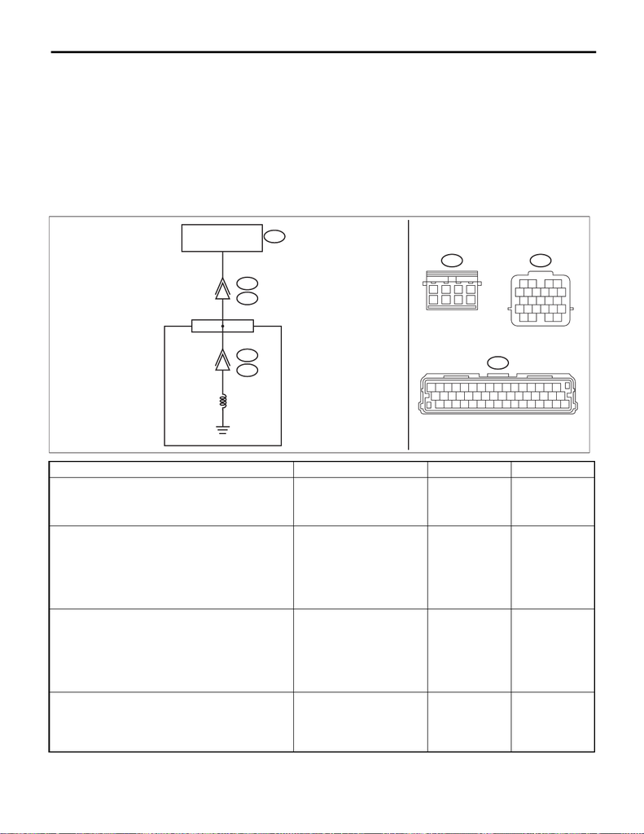

CVT(diag)-115

Diagnostic Procedure with Diagnostic Trouble Code (DTC)

CONTINUOUSLY VARIABLE TRANSMISSION (DIAGNOSTICS)

AW:DTC P2758 TORQUE CONVERTER CLUTCH PRESSURE CONTROL SOLE-

NOID CONTROL CIRCUIT STUCK ON

DTC DETECTING CONDITION:

• Detected when two consecutive driving cycles with fault occur.

• GENERAL DESCRIPTION <Ref. to GD(CVT)-57, DTC P2758 TORQUE CONVERTER CLUTCH PRES-

SURE CONTROL SOLENOID CONTROL CIRCUIT STUCK ON, Diagnostic Trouble Code (DTC) Detecting

Criteria.>

TROUBLE SYMPTOM:

The engine stalls when the vehicle is stopped.

WIRING DIAGRAM:

CVT control system <Ref. to WI-148, CVT Control System.>

Step Check Yes No

1 CHECK DTC.

Read the DTC using Subaru Select Monitor.

Besides DTC P2758, is any of

the DTCs P2747, P2763,

P2764, U0100 and U0401 dis-

played?

Perform the diag-

nosis according to

DTCs other than

P2758.

Go to step 2.

2 CHECK LOCK-UP DUTY SOLENOID (SYS-

TEM OPERATION CHECK MODE).

1) Turn the ignition switch to ON.

2) Using the Subaru Select Monitor, perform

forced operation of the lock-up duty solenoid.

<Ref. to CVT(diag)-22, System Operation

Check Mode.>

Does the indication of 0 → 50%

appear repeatedly during

forced operation, and does

operating sound emit during

indicating 50%?

Go to step 5. Go to step 3.

3 CHECK LOCK-UP DUTY SOLENOID.

1) Turn the ignition switch to OFF.

2) Disconnect the transmission connector.

3) Measure the resistance between transmis-

sion connector and transmission body.

Connector & terminal

(T4) No. 2 — Transmission body:

Is the resistance approx. 10 —

13.5 Ω? (when cold)

Go to step 7. Go to step 4.

4 CHECK HARNESS.

Check the continuity of transmission harness.

Is the harness normal? (Is it

free from defects such as open

circuit, power supply-output

short or GND-output short cir-

cuit, or poor contact?)

Go to step 7. Repair the har-

ness.

T11

13

4

6

78

2

5

B54

123456789

10 11 12 13 14 15 16

33 34 35 36 37 38 39 40 41 42 43 44 45 46 47 48

B11

567

12 34

9

10 11 12

17 18 19 20

8

13 14 15 16

CVT00522

T11

T31

22

15

B11

T4

B54

TCM

CONTROL VALVE BODY

LOCK-UP DUTY

SOLENOID

[figure not shown]

CVT(diag)-116

Diagnostic Procedure with Diagnostic Trouble Code (DTC)

CONTINUOUSLY VARIABLE TRANSMISSION (DIAGNOSTICS)

5 CHECK TRANSMISSION FLUID.

1) Connect the transmission connector.

2) Check the amount of ATF. <Ref. to

CVT(TR690)-36, ADJUSTMENT, CVTF.>

Is the ATF amount correct? Go to step 6. Adjust the amount

of ATF. <Ref. to

CVT(TR690)-36,

ADJUSTMENT,

CVTF.>

6 CHECK TRANSMISSION FLUID.

Check the condition of ATF. <Ref. to

CVT(TR690)-40, CONDITION CHECK, CVTF.>

Is the ATF OK? Go to step 7. Check according to

the “Corrective

action” of ATF

(CVTF) “CONDI-

TION CHECK”.

<Ref. to

CVT(TR690)-40,

CONDITION

CHECK, CVTF.>

7 CHECK INPUT SIGNAL FOR TCM.

1) Lift up the vehicle.

2) Start the engine.

3) Warm up until the ATF temperature reaches

to 40 — 70°C (104 — 158°F).

4) Shift the select lever to “P” range.

5) Stabilize the engine speed at idle.

6) Read the data of «Actual secondary pres-

sure» using Subaru Select Monitor.

Is the «Actual secondary pres-

sure» 0.5 — 1.5 MPa?

Go to step 8. Perform the diag-

nosis according to

DTC P0841. <Ref.

to CVT(diag)-68,

DTC P0841 SEC-

ONDARY OIL

PRESSURE SEN-

SOR PERFOR-

MANCE,

Diagnostic Proce-

dure with Diagnos-

tic Trouble Code

(DTC).>

8 DRIVING CHECK FOR LOCK-UP CONDI-

TION.

1) Perform the “Clear Memory Mode”. <Ref. to

CVT(diag)-17, Clear Memory Mode.>

2) Turn the ignition switch to OFF.

3) Start the engine.

4) Warm up until the ATF temperature exceeds

50°C.

5) Drive the vehicle for one minute or more

while keeping such constant speed that «Lock

Up Duty Ratio» is 0%, and «Front Wheel

Speed» is 5 km/h (3 MPH) or less, which are

displayed on the Subaru Select Monitor.

6) Turn the ignition switch to OFF.

7) Start the engine.

8) Perform the procedure in step 5) again.

9) Read the DTC using Subaru Select Monitor.

Does the AT OIL TEMP light

blink and is DTC P2758 dis-

played? Or does the engine

stall?

Perform the sec-

ondary pressure

test. <Ref. to

CVT(TR690)-49,

Secondary Pres-

sure (Line Pres-

sure) Test.> When

DTC other than

P2758 is dis-

played, perform

the diagnosis

according to the

DTC.

Current condition

is normal. Tempo-

rary oil pressure

malfunction.

Step Check Yes No

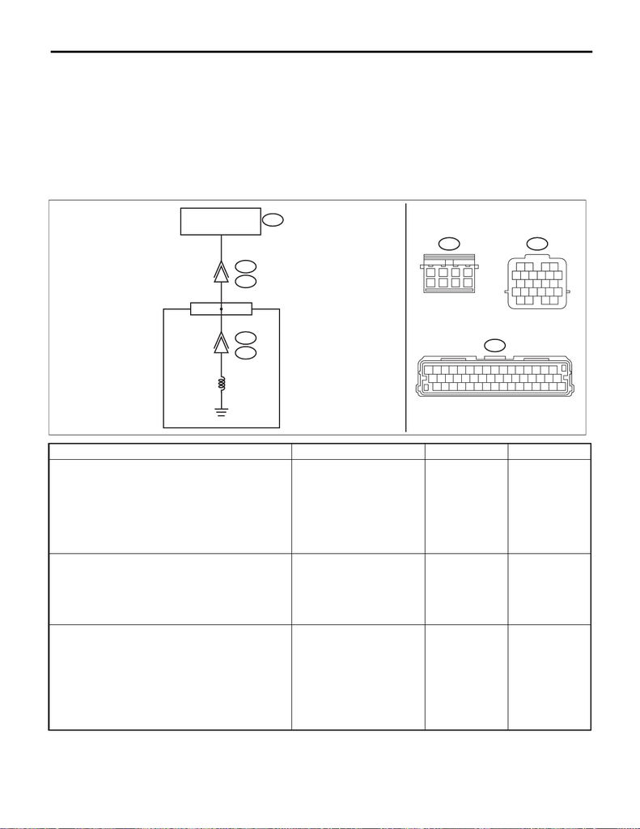

CVT(diag)-117

Diagnostic Procedure with Diagnostic Trouble Code (DTC)

CONTINUOUSLY VARIABLE TRANSMISSION (DIAGNOSTICS)

AX:DTC P2763 LOCK-UP DUTY SOLENOID CIRCUIT (HIGH)

DTC DETECTING CONDITION:

• Immediately at fault recognition

• GENERAL DESCRIPTION <Ref. to GD(CVT)-58, DTC P2763 LOCK-UP DUTY SOLENOID CIRCUIT

(HIGH), Diagnostic Trouble Code (DTC) Detecting Criteria.>

TROUBLE SYMPTOM:

• No lock-up occurs.

• Engine stalls.

WIRING DIAGRAM:

CVT control system <Ref. to WI-148, CVT Control System.>

Step Check Yes No

1 CHECK HARNESS.

1) Turn the ignition switch to OFF.

2) Disconnect the TCM and transmission con-

nectors.

3) Measure the resistance between TCM con-

nector and transmission connectors.

Connector & terminal

(B54) No. 15 — (B11) No. 2:

Is the resistance less than 1 Ω? Go to step 2. Repair the open

circuit of harness.

2 CHECK HARNESS.

1) Turn the ignition switch to ON.

2) Measure the voltage between TCM connec-

tor and chassis ground.

Connector & terminal

(B54) No. 15 (+) — Chassis ground (–):

Is the voltage approx. 0 V? Go to step 3. Repair the short

circuit of harness.

3 CHECK LOCK-UP DUTY SOLENOID.

Measure the resistance between transmission

connector and transmission body.

Connector & terminal

(T4) No. 2 — Transmission body:

Is the resistance approx. 10 —

13.5 Ω? (when cold)

Check for poor

contact of connec-

tor, and if no fault is

found, replace the

TCM. <Ref. to

CVT(TR690)-126,

Transmission Con-

trol Module

(TCM).>

Go to step 4.

T11

13

4

6

78

2

5

B54

123456789

10 11 12 13 14 15 16

33 34 35 36 37 38 39 40 41 42 43 44 45 46 47 48

B11

567

12 34

9

10 11 12

17 18 19 20

8

13 14 15 16

CVT00522

T11

T31

22

15

B11

T4

B54

TCM

CONTROL VALVE BODY

LOCK-UP DUTY

SOLENOID

[figure not shown]

CVT(diag)-118

Diagnostic Procedure with Diagnostic Trouble Code (DTC)

CONTINUOUSLY VARIABLE TRANSMISSION (DIAGNOSTICS)

4 CHECK HARNESS INSIDE TRANSMISSION.

CAUTION:

Start work after ATF cools down.

1) Remove the transmission oil pan.

2) Check for the harness pinch, damage.

Is there any fault in the har-

ness?

Replace the trans-

mission harness.

Go to step 5.

5 CHECK HARNESS INSIDE TRANSMISSION.

1) Disconnect the control valve body connec-

tor.

2) Turn the ignition switch to ON.

3) Measure the voltage between transmission

connector and transmission body.

Connector & terminal

(T4) No. 2 (+) — Transmission body (–):

Is the voltage approx. 0 V? Replace the con-

trol valve body.

<Ref. to

CVT(TR690)-112,

Control Valve

Body.>

Replace the trans-

mission harness.

Step Check Yes No

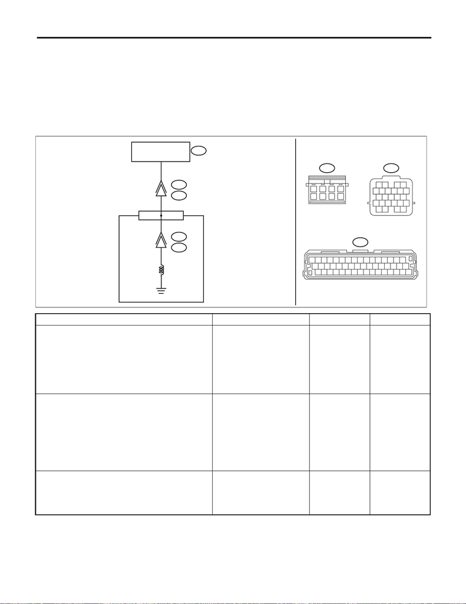

CVT(diag)-119

Diagnostic Procedure with Diagnostic Trouble Code (DTC)

CONTINUOUSLY VARIABLE TRANSMISSION (DIAGNOSTICS)

AY:DTC P2764 LOCK-UP DUTY SOLENOID CIRCUIT (LOW)

DTC DETECTING CONDITION:

• Immediately at fault recognition

• GENERAL DESCRIPTION <Ref. to GD(CVT)-59, DTC P2764 LOCK-UP DUTY SOLENOID CIRCUIT

(LOW), Diagnostic Trouble Code (DTC) Detecting Criteria.>

TROUBLE SYMPTOM:

No lock-up occurs.

WIRING DIAGRAM:

CVT control system <Ref. to WI-148, CVT Control System.>

Step Check Yes No

1 CHECK HARNESS.

1) Turn the ignition switch to OFF.

2) Disconnect the TCM and transmission con-

nectors.

3) Measure the resistance between TCM con-

nector and chassis ground.

Connector & terminal

(B54) No. 15 — Chassis ground:

Is the resistance 1 MΩ or

more?

Go to step 2. Repair the short

circuit of harness.

2 CHECK LOCK-UP DUTY SOLENOID.

Measure the resistance between transmission

connector and transmission body.

Connector & terminal

(T4) No. 2 — Transmission body:

Is the resistance approx. 10 —

13.5 Ω? (when cold)

Check for poor

contact of connec-

tor, and if no fault is

found, replace the

TCM. <Ref. to

CVT(TR690)-126,

Transmission Con-

trol Module

(TCM).>

Go to step 3.

3 CHECK HARNESS INSIDE TRANSMISSION.

CAUTION:

Start work after ATF cools down.

1) Remove the transmission oil pan.

2) Check for the harness pinch, damage.

Is there any fault in the har-

ness?

Replace the trans-

mission harness.

Go to step 4.

T11

13

4

6

78

2

5

B54

123456789

10 11 12 13 14 15 16

33 34 35 36 37 38 39 40 41 42 43 44 45 46 47 48

B11

567

12 34

9

10 11 12

17 18 19 20

8

13 14 15 16

CVT00522

T11

T31

22

15

B11

T4

B54

TCM

CONTROL VALVE BODY

LOCK-UP DUTY

SOLENOID

[figure not shown]

CVT(diag)-120

Diagnostic Procedure with Diagnostic Trouble Code (DTC)

CONTINUOUSLY VARIABLE TRANSMISSION (DIAGNOSTICS)

4 CHECK HARNESS INSIDE TRANSMISSION.

1) Disconnect the control valve body connec-

tor.

2) Measure the resistance between transmis-

sion connector and transmission body.

Connector & terminal

(T4) No. 2 — Transmission body:

Is the resistance 1 MΩ or

more?

Replace the con-

trol valve body.

<Ref. to

CVT(TR690)-112,

Control Valve

Body.>

Replace the trans-

mission harness.

Step Check Yes No

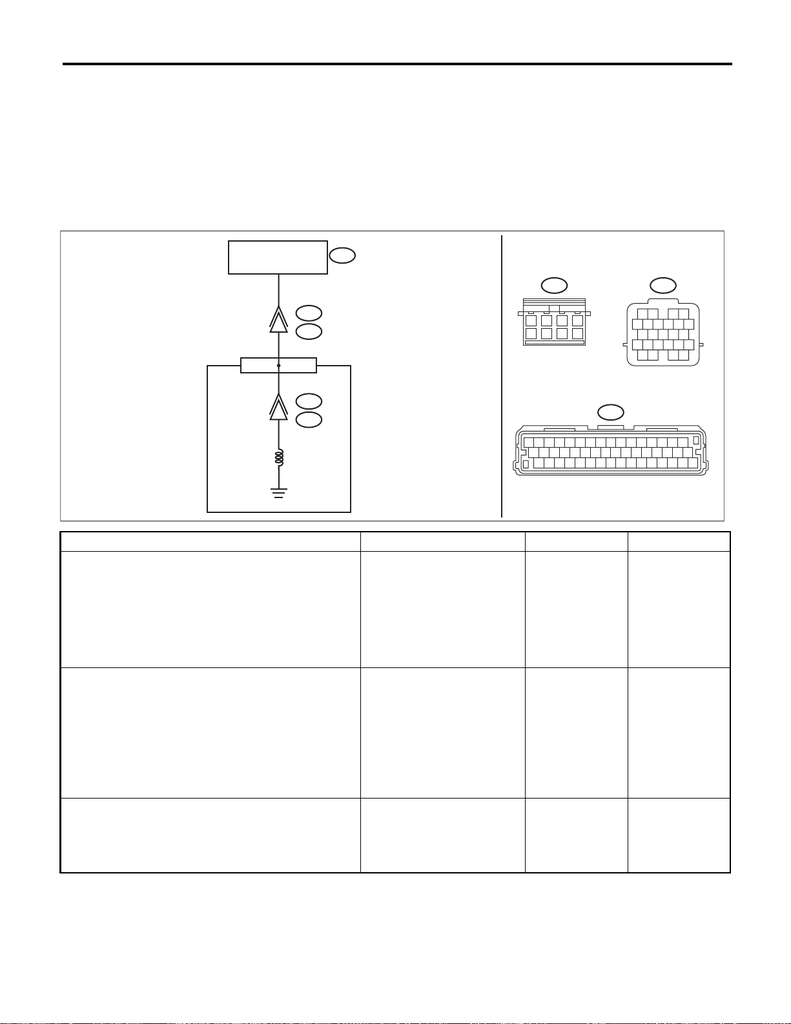

CVT(diag)-121

Diagnostic Procedure with Diagnostic Trouble Code (DTC)

CONTINUOUSLY VARIABLE TRANSMISSION (DIAGNOSTICS)

AZ:DTC P2769 LOCK-UP ON/OFF SOLENOID CIRCUIT (LOW)

DTC DETECTING CONDITION:

• Immediately at fault recognition

• GENERAL DESCRIPTION <Ref. to GD(CVT)-60, DTC P2769 LOCK-UP ON/OFF SOLENOID CIRCUIT

(LOW), Diagnostic Trouble Code (DTC) Detecting Criteria.>

TROUBLE SYMPTOM:

No lock-up occurs.

WIRING DIAGRAM:

CVT control system <Ref. to WI-148, CVT Control System.>

Step Check Yes No

1 CHECK HARNESS.

1) Turn the ignition switch to OFF.

2) Disconnect the TCM and transmission con-

nectors.

3) Measure the resistance between TCM con-

nector and chassis ground.

Connector & terminal

(B54) No. 31 — Chassis ground:

Is the resistance 1 MΩ or

more?

Go to step 2. Repair the short

circuit of harness.

2 CHECK LOCK UP ON/OFF SOLENOID.

Measure the resistance between transmission

connector and transmission body.

Connector & terminal

(T4) No. 3 — Transmission body:

Is the resistance approx. 13 —

18.5 Ω? (when cold)

Check for poor

contact of connec-

tor, and if no fault is

found, replace the

TCM. <Ref. to

CVT(TR690)-126,

Transmission Con-

trol Module

(TCM).>

Go to step 3.

3 CHECK HARNESS INSIDE TRANSMISSION.

CAUTION:

Start work after ATF cools down.

1) Remove the transmission oil pan.

2) Check for the harness pinch, damage.

Is there any fault in the har-

ness?

Replace the trans-

mission harness.

Go to step 4.

T11

13

4

6

78

2

5

B54

123456789

10 11 12 13 14 15 16

33 34 35 36 37 38 39 40 41 42 43 44 45 46 47 48

B11

567

12 34

9

10 11 12

17 18 19 20

8

13 14 15 16

T11

T31

53

31

B11

T4

B54

CVT00521

TCM

CONTROL VALVE BODY

LOCK-UP ON/OFF

SOLENOID

[figure not shown]

CVT(diag)-122

Diagnostic Procedure with Diagnostic Trouble Code (DTC)

CONTINUOUSLY VARIABLE TRANSMISSION (DIAGNOSTICS)

4 CHECK HARNESS INSIDE TRANSMISSION.

1) Disconnect the control valve body connec-

tor.

2) Measure the resistance between transmis-

sion connector and transmission body.

Connector & terminal

(T4) No. 3 — Transmission body:

Is the resistance 1 MΩ or

more?

Replace the con-

trol valve body.

<Ref. to

CVT(TR690)-112,

Control Valve

Body.>

Replace the trans-

mission harness.

Step Check Yes No

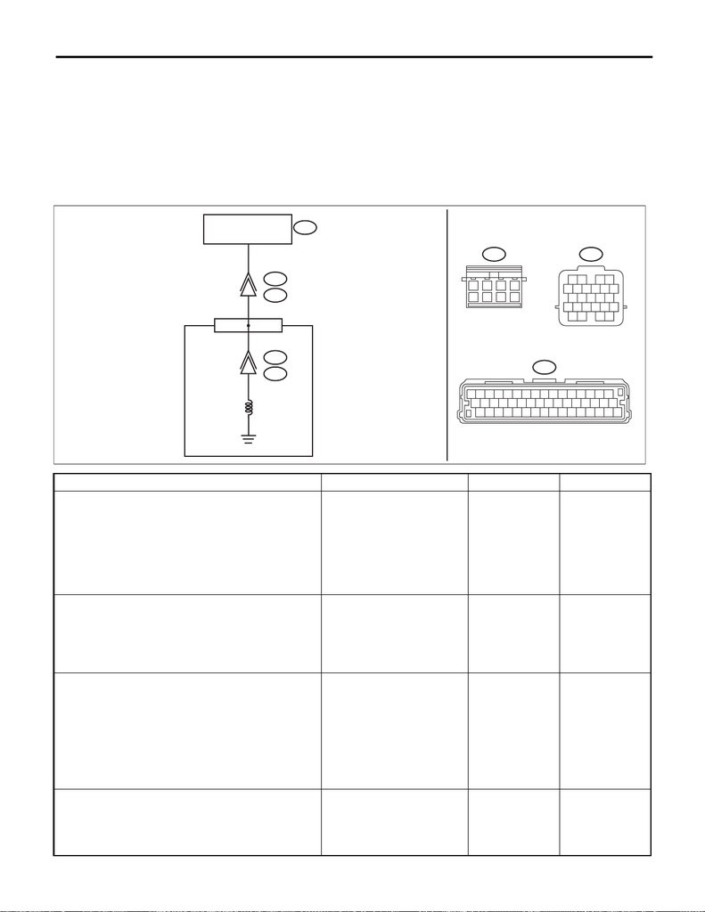

CVT(diag)-123

Diagnostic Procedure with Diagnostic Trouble Code (DTC)

CONTINUOUSLY VARIABLE TRANSMISSION (DIAGNOSTICS)

BA:DTC P2770 LOCK-UP ON/OFF SOLENOID CIRCUIT (HIGH)

DTC DETECTING CONDITION:

• Immediately at fault recognition

• GENERAL DESCRIPTION <Ref. to GD(CVT)-61, DTC P2770 LOCK-UP ON/OFF SOLENOID CIRCUIT

(HIGH), Diagnostic Trouble Code (DTC) Detecting Criteria.>

TROUBLE SYMPTOM:

No lock-up occurs.

WIRING DIAGRAM:

CVT control system <Ref. to WI-148, CVT Control System.>

Step Check Yes No

1 CHECK HARNESS.

1) Turn the ignition switch to OFF.

2) Disconnect the TCM and transmission con-

nectors.

3) Measure the resistance between TCM con-

nector and transmission connectors.

Connector & terminal

(B54) No. 31 — (B11) No. 3:

Is the resistance less than 1 Ω? Go to step 2. Repair the open

circuit of harness.

2 CHECK HARNESS.

1) Turn the ignition switch to ON.

2) Measure the voltage between TCM connec-

tor and chassis ground.

Connector & terminal

(B54) No. 31 (+) — Chassis ground (–):

Is the voltage approx. 0 V? Go to step 3. Repair the short

circuit of harness.

3 CHECK LOCK UP ON/OFF SOLENOID.

Measure the resistance between transmission

connector and transmission body.

Connector & terminal

(T4) No. 3 — Transmission body:

Is the resistance approx. 13 —

18.5 Ω? (when cold)

Check for poor

contact of connec-

tor, and if no fault is

found, replace the

TCM. <Ref. to

CVT(TR690)-126,

Transmission Con-

trol Module

(TCM).>

Go to step 4.

4 CHECK HARNESS INSIDE TRANSMISSION.

CAUTION:

Start work after ATF cools down.

1) Remove the transmission oil pan.

2) Check for the harness pinch, damage.

Is there any fault in the har-

ness?

Replace the trans-

mission harness.

Go to step 5.

T11

13

4

6

78

2

5

B54

123456789

10 11 12 13 14 15 16

33 34 35 36 37 38 39 40 41 42 43 44 45 46 47 48

B11

567

12 34

9

10 11 12

17 18 19 20

8

13 14 15 16

T11

T31

53

31

B11

T4

B54

CVT00521

TCM

CONTROL VALVE BODY

LOCK-UP ON/OFF

SOLENOID

[figure not shown]

CVT(diag)-124

Diagnostic Procedure with Diagnostic Trouble Code (DTC)

CONTINUOUSLY VARIABLE TRANSMISSION (DIAGNOSTICS)

BB:DTC U0073 CONTROL MODULE COMMUNICATION BUS OFF

NOTE:

Refer to “LAN SYSTEM (DIAGNOSTICS)” for diagnostic procedure. <Ref. to LAN(diag)-2, Basic Diagnostic

Procedure.>

BC:DTC U0100 LOST COMMUNICATION WITH ECM/PCM “A”

NOTE:

Refer to “LAN SYSTEM (DIAGNOSTICS)” for diagnostic procedures. <Ref. to LAN(diag)-2, Basic Diagnostic

Procedure.>

BD:DTC U0122 LOST COMMUNICATION WITH VEHICLE DYNAMICS CONTROL

MODULE

NOTE:

Refer to “LAN SYSTEM (DIAGNOSTICS)” for diagnostic procedures. <Ref. to LAN(diag)-2, Basic Diagnostic

Procedure.>

BE:DTC U0140 LOST COMMUNICATION WITH BODY CONTROL MODULE

NOTE:

Refer to “LAN SYSTEM (DIAGNOSTICS)” for diagnostic procedures. <Ref. to LAN(diag)-2, Basic Diagnostic

Procedure.>

BF:DTC U0155 LOST COMMUNICATION WITH INSTRUMENT PANEL CLUSTER

(IPC) CONTROL MODULE

NOTE:

Refer to “LAN SYSTEM (DIAGNOSTICS)” for diagnostic procedures. <Ref. to LAN(diag)-2, Basic Diagnostic

Procedure.>

BG:DTC U0164 LOST COMMUNICATION WITH HVAC CONTROL MODULE

NOTE:

Refer to “LAN SYSTEM (DIAGNOSTICS)” for diagnostic procedure. <Ref. to LAN(diag)-2, Basic Diagnostic

Procedure.>

BH:DTC U0401 INVALID DATA RECEIVED FROM ECM/PCM “A”

NOTE:

Refer to “LAN SYSTEM (DIAGNOSTICS)” for diagnostic procedures. <Ref. to LAN(diag)-2, Basic Diagnostic

Procedure.>

BI: DTC U0416 INVALID DATA RECEIVED FROM VEHICLE DYNAMICS CON-

TROL MODULE

NOTE:

Refer to “LAN SYSTEM (DIAGNOSTICS)” for diagnostic procedures. <Ref. to LAN(diag)-2, Basic Diagnostic

Procedure.>

tor.

2) Turn the ignition switch to ON.

3) Measure the voltage between transmission

connector and transmission body.

Connector & terminal

(T4) No. 3 (+) — Transmission body (–):

Is the voltage approx. 0 V? Replace the con-

trol valve body.

<Ref. to

CVT(TR690)-112,

Control Valve

Body.>

Replace the trans-

mission harness.

Step Check Yes No

[figure not shown]

CVT(diag)-125

Diagnostic Procedure with Diagnostic Trouble Code (DTC)

CONTINUOUSLY VARIABLE TRANSMISSION (DIAGNOSTICS)

BJ:DTC U0422 INVALID DATA RECEIVED FROM BODY CONTROL MODULE

NOTE:

Refer to “LAN SYSTEM (DIAGNOSTICS)” for diagnostic procedures. <Ref. to LAN(diag)-2, Basic Diagnostic

Procedure.>

BK:DTC U0423 INVALID DATA RECEIVED FROM INSTRUMENT PANEL CLUS-

TER CONTROL MODULE

NOTE:

Refer to “LAN SYSTEM (DIAGNOSTICS)” for diagnostic procedures. <Ref. to LAN(diag)-2, Basic Diagnostic

Procedure.>

BL:DTC U0424 INVALID DATA RECEIVED FROM HVAC CONTROL MODULE

NOTE:

Refer to “LAN SYSTEM (DIAGNOSTICS)” for diagnostic procedure. <Ref. to LAN(diag)-2, Basic Diagnostic

Procedure.>